# Results - area per area for areas with both neritic and oceanic habitats

Lola Gilbert

31/03/2022

# Northeast Atlantic

## Excretion in neritic and oceanic waters

In absolute value, is there more excretion in an habitat than in the other ?

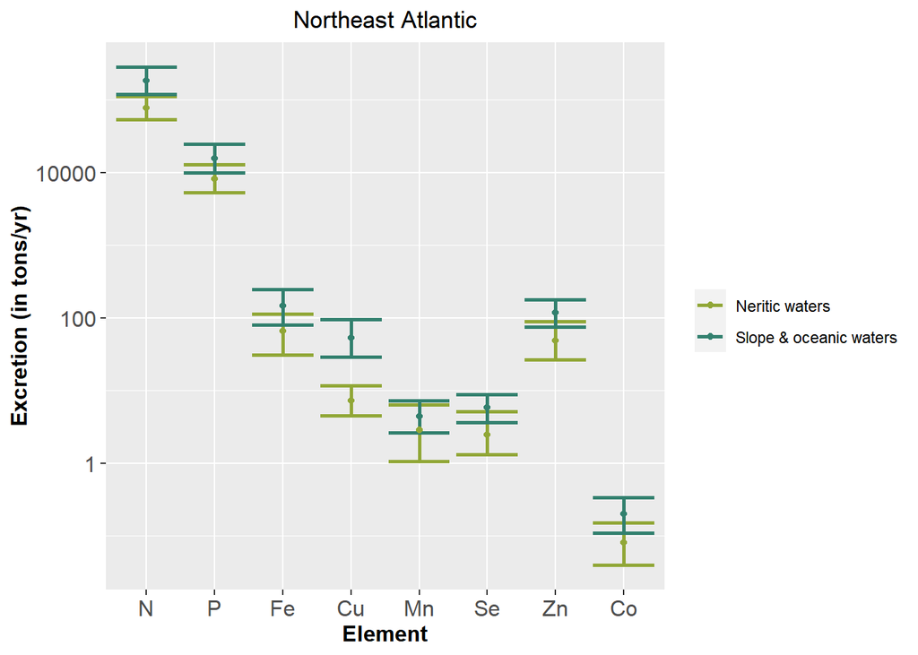

The full results being:

| Geo_area | Eco_area | Element | min | 2.5_quant | mean | median | 97.5_quant | max |
| --- | --- | --- | --- | --- | --- | --- | --- | --- |
| Northeast Atlantic | oceanic | N | 89981.0975361 | 120591.2432377 | 185618.4412418 | 180409.9406017 | 282880.1566666 | 340629.5648450 |
| Northeast Atlantic | oceanic | P | 8377.5813887 | 9959.9416432 | 15661.1426480 | 15171.1742470 | 24441.7921672 | 32356.8124359 |
| Northeast Atlantic | oceanic | Fe | 63.5123126 | 79.9828212 | 146.3949786 | 139.9673382 | 245.2382085 | 311.3340421 |
| Northeast Atlantic | oceanic | Cu | 20.8857219 | 29.1377888 | 53.7696212 | 50.7242388 | 95.6676808 | 120.2435074 |
| Northeast Atlantic | oceanic | Mn | 1.9072412 | 2.6488568 | 4.4716960 | 4.2912283 | 7.2795851 | 9.1101115 |
| Northeast Atlantic | oceanic | Se | 2.6438706 | 3.6302326 | 5.8067687 | 5.6835788 | 8.9184715 | 12.0110074 |
| Northeast Atlantic | oceanic | Zn | 56.7858659 | 75.3660228 | 118.4720783 | 115.3962421 | 177.1737191 | 238.9180291 |
| Northeast Atlantic | oceanic | Co | 0.0823829 | 0.1106932 | 0.2014518 | 0.1926027 | 0.3347861 | 0.4168391 |
| Northeast Atlantic | oceanic | As | 22.0437410 | 27.6760103 | 45.1466083 | 43.2550179 | 72.1064318 | 105.4996953 |
| Northeast Atlantic | shelf | N | 42387.8218674 | 54069.3521159 | 77969.4731737 | 76000.7437839 | 112272.2688594 | 147225.2354735 |
| Northeast Atlantic | shelf | P | 4223.3845035 | 5374.0784130 | 8232.6569712 | 7901.5842826 | 12889.1389708 | 16338.2427291 |
| Northeast Atlantic | shelf | Fe | 21.2292418 | 31.2975582 | 66.0456867 | 63.4811127 | 113.9661239 | 201.1789685 |
| Northeast Atlantic | shelf | Cu | 3.5590497 | 4.5612504 | 7.3119917 | 6.9742268 | 11.8110907 | 18.3456173 |
| Northeast Atlantic | shelf | Mn | 0.6104752 | 1.0728962 | 2.8947433 | 2.4215340 | 6.3736886 | 9.4981569 |
| Northeast Atlantic | shelf | Se | 0.9417206 | 1.3324496 | 2.4737486 | 2.1815186 | 5.1310419 | 9.3014764 |
| Northeast Atlantic | shelf | Zn | 20.8489006 | 26.7503206 | 48.3222344 | 45.2572323 | 88.7779818 | 134.4914234 |
| Northeast Atlantic | shelf | Co | 0.0311247 | 0.0398106 | 0.0818309 | 0.0766047 | 0.1532334 | 0.2298530 |
| Northeast Atlantic | shelf | As | 4.7969508 | 6.9966826 | 14.9632877 | 13.1484085 | 28.6379645 | 43.6931293 |

And per unit area, so considering the respective size of each of the habitat ?

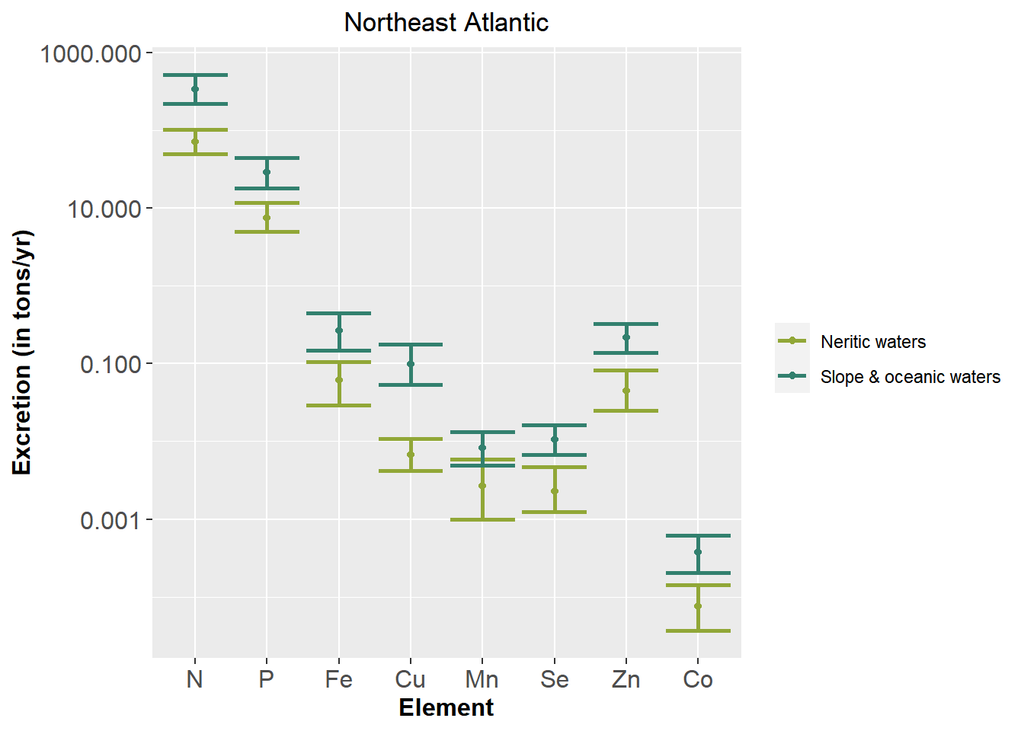

The details being:

| Geo_area | Eco_area | Element | min | 2.5_quant | mean | median | 97.5_quant | max |
| --- | --- | --- | --- | --- | --- | --- | --- | --- |
| Northeast Atlantic | oceanic | N | 165.6393596 | 221.9872490 | 341.6908727 | 332.1029400 | 520.7325682 | 627.0390620 |
| Northeast Atlantic | oceanic | P | 15.4216525 | 18.3344991 | 28.8294065 | 27.9274609 | 44.9930365 | 59.5631954 |
| Northeast Atlantic | oceanic | Fe | 0.1169150 | 0.1472343 | 0.2694874 | 0.2576552 | 0.4514404 | 0.5731112 |
| Northeast Atlantic | oceanic | Cu | 0.0384469 | 0.0536375 | 0.0989804 | 0.0933744 | 0.1761074 | 0.2213471 |
| Northeast Atlantic | oceanic | Mn | 0.0035109 | 0.0048761 | 0.0082316 | 0.0078994 | 0.0134004 | 0.0167701 |
| Northeast Atlantic | oceanic | Se | 0.0048669 | 0.0066826 | 0.0106892 | 0.0104625 | 0.0164173 | 0.0221102 |
| Northeast Atlantic | oceanic | Zn | 0.1045328 | 0.1387356 | 0.2180862 | 0.2124242 | 0.3261456 | 0.4398060 |
| Northeast Atlantic | oceanic | Co | 0.0001517 | 0.0002038 | 0.0003708 | 0.0003545 | 0.0006163 | 0.0007673 |
| Northeast Atlantic | oceanic | As | 0.0405786 | 0.0509467 | 0.0831070 | 0.0796249 | 0.1327352 | 0.1942064 |
| Northeast Atlantic | shelf | N | 39.0950059 | 49.8690791 | 71.9125654 | 70.0967730 | 103.5506148 | 135.7883278 |
| Northeast Atlantic | shelf | P | 3.8952990 | 4.9566035 | 7.5931189 | 7.2877650 | 11.8878711 | 15.0690379 |
| Northeast Atlantic | shelf | Fe | 0.0195801 | 0.0288663 | 0.0609151 | 0.0585497 | 0.1051129 | 0.1855508 |
| Northeast Atlantic | shelf | Cu | 0.0032826 | 0.0042069 | 0.0067440 | 0.0064324 | 0.0108936 | 0.0169205 |
| Northeast Atlantic | shelf | Mn | 0.0005631 | 0.0009896 | 0.0026699 | 0.0022334 | 0.0058786 | 0.0087603 |
| Northeast Atlantic | shelf | Se | 0.0008686 | 0.0012289 | 0.0022816 | 0.0020121 | 0.0047324 | 0.0085789 |
| Northeast Atlantic | shelf | Zn | 0.0192293 | 0.0246723 | 0.0445684 | 0.0417415 | 0.0818814 | 0.1240437 |
| Northeast Atlantic | shelf | Co | 0.0000287 | 0.0000367 | 0.0000755 | 0.0000707 | 0.0001413 | 0.0002120 |
| Northeast Atlantic | shelf | As | 0.0044243 | 0.0064532 | 0.0138009 | 0.0121270 | 0.0264133 | 0.0402989 |

Are the differences between the two areas significant ? (per surface unit)

| Geo_area | Element | Area1 | Area2 | ratio_area1_superior_to_area2 |
| --- | --- | --- | --- | --- |
| Northeast Atlantic | N | Neritic waters | Oceanic waters | 0 |
| Northeast Atlantic | N | Oceanic waters | Neritic waters | 1 |
| Northeast Atlantic | P | Neritic waters | Oceanic waters | 0 |
| Northeast Atlantic | P | Oceanic waters | Neritic waters | 1 |
| Northeast Atlantic | Fe | Neritic waters | Oceanic waters | 0 |
| Northeast Atlantic | Fe | Oceanic waters | Neritic waters | 1 |
| Northeast Atlantic | Cu | Neritic waters | Oceanic waters | 0 |
| Northeast Atlantic | Cu | Oceanic waters | Neritic waters | 1 |
| Northeast Atlantic | Mn | Neritic waters | Oceanic waters | 0 |
| Northeast Atlantic | Mn | Oceanic waters | Neritic waters | 1 |
| Northeast Atlantic | Se | Neritic waters | Oceanic waters | 0 |
| Northeast Atlantic | Se | Oceanic waters | Neritic waters | 1 |
| Northeast Atlantic | Zn | Neritic waters | Oceanic waters | 0 |
| Northeast Atlantic | Zn | Oceanic waters | Neritic waters | 1 |
| Northeast Atlantic | Co | Neritic waters | Oceanic waters | 0 |
| Northeast Atlantic | Co | Oceanic waters | Neritic waters | 1 |

## Excretion per taxa

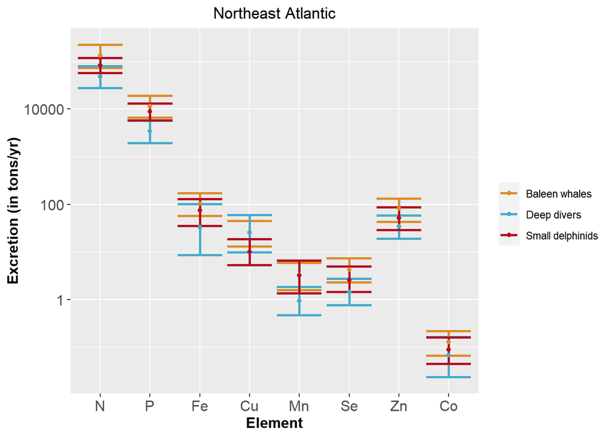

Are the differences significant ?

| Geo_area | Element | Group1 | Group2 | ratio_group1_superior_to_group2 |
| --- | --- | --- | --- | --- |
| Northeast Atlantic | N | Baleen whales | Deep divers | 0.995 |
| Northeast Atlantic | N | Baleen whales | Small delphinids | 0.910 |
| Northeast Atlantic | N | Deep divers | Small delphinids | 0.039 |
| Northeast Atlantic | P | Baleen whales | Deep divers | 0.999 |
| Northeast Atlantic | P | Baleen whales | Small delphinids | 0.798 |
| Northeast Atlantic | P | Deep divers | Small delphinids | 0.004 |
| Northeast Atlantic | Fe | Baleen whales | Deep divers | 0.957 |
| Northeast Atlantic | Fe | Baleen whales | Small delphinids | 0.833 |
| Northeast Atlantic | Fe | Deep divers | Small delphinids | 0.088 |
| Northeast Atlantic | Cu | Baleen whales | Deep divers | 0.572 |
| Northeast Atlantic | Cu | Baleen whales | Small delphinids | 0.980 |
| Northeast Atlantic | Cu | Deep divers | Small delphinids | 0.984 |
| Northeast Atlantic | Mn | Baleen whales | Deep divers | 0.996 |
| Northeast Atlantic | Mn | Baleen whales | Small delphinids | 0.540 |
| Northeast Atlantic | Mn | Deep divers | Small delphinids | 0.011 |
| Northeast Atlantic | Se | Baleen whales | Deep divers | 0.991 |
| Northeast Atlantic | Se | Baleen whales | Small delphinids | 0.938 |
| Northeast Atlantic | Se | Deep divers | Small delphinids | 0.087 |
| Northeast Atlantic | Zn | Baleen whales | Deep divers | 0.981 |
| Northeast Atlantic | Zn | Baleen whales | Small delphinids | 0.918 |
| Northeast Atlantic | Zn | Deep divers | Small delphinids | 0.149 |
| Northeast Atlantic | Co | Baleen whales | Deep divers | 0.884 |
| Northeast Atlantic | Co | Baleen whales | Small delphinids | 0.855 |
| Northeast Atlantic | Co | Deep divers | Small delphinids | 0.271 |

What are their relative contribution to total excretion in this area ?

| Geo_area | Eco_gp | Element | mean | mean_total | ratio_contribution |
| --- | --- | --- | --- | --- | --- |
| Northeast Atlantic | Baleen whales | N | 131994.6848356 | 263587.9144155 | 0.5007615 |
| Northeast Atlantic | Baleen whales | P | 11659.4281540 | 23893.7996192 | 0.4879688 |
| Northeast Atlantic | Baleen whales | Fe | 104.3571889 | 212.4406653 | 0.4912298 |
| Northeast Atlantic | Baleen whales | Cu | 25.6676872 | 61.0816129 | 0.4202195 |
| Northeast Atlantic | Baleen whales | Mn | 3.2483691 | 7.3664392 | 0.4409687 |
| Northeast Atlantic | Baleen whales | Se | 4.2624426 | 8.2805174 | 0.5147556 |
| Northeast Atlantic | Baleen whales | Zn | 81.0112680 | 166.7943128 | 0.4856956 |
| Northeast Atlantic | Baleen whales | Co | 0.1275739 | 0.2832827 | 0.4503413 |
| Northeast Atlantic | Baleen whales | As | 31.8664236 | 60.1098960 | 0.5301361 |
| Northeast Atlantic | Deep divers | N | 48300.2128779 | 263587.9144155 | 0.1832414 |
| Northeast Atlantic | Deep divers | P | 3467.2474228 | 23893.7996192 | 0.1451108 |
| Northeast Atlantic | Deep divers | Fe | 33.3776337 | 212.4406653 | 0.1571151 |
| Northeast Atlantic | Deep divers | Cu | 25.3541680 | 61.0816129 | 0.4150867 |
| Northeast Atlantic | Deep divers | Mn | 0.9258968 | 7.3664392 | 0.1256912 |
| Northeast Atlantic | Deep divers | Se | 1.4538678 | 8.2805174 | 0.1755769 |
| Northeast Atlantic | Deep divers | Zn | 34.3779858 | 166.7943128 | 0.2061101 |
| Northeast Atlantic | Deep divers | Co | 0.0677329 | 0.2832827 | 0.2391000 |
| Northeast Atlantic | Deep divers | As | 11.6004348 | 60.1098960 | 0.1929871 |
| Northeast Atlantic | Small delphinids | N | 83293.0167020 | 263587.9144155 | 0.3159971 |
| Northeast Atlantic | Small delphinids | P | 8767.1240425 | 23893.7996192 | 0.3669205 |
| Northeast Atlantic | Small delphinids | Fe | 74.7058427 | 212.4406653 | 0.3516551 |
| Northeast Atlantic | Small delphinids | Cu | 10.0597577 | 61.0816129 | 0.1646937 |
| Northeast Atlantic | Small delphinids | Mn | 3.1921733 | 7.3664392 | 0.4333401 |
| Northeast Atlantic | Small delphinids | Se | 2.5642070 | 8.2805174 | 0.3096675 |
| Northeast Atlantic | Small delphinids | Zn | 51.4050589 | 166.7943128 | 0.3081943 |
| Northeast Atlantic | Small delphinids | Co | 0.0879759 | 0.2832827 | 0.3105587 |
| Northeast Atlantic | Small delphinids | As | 16.6430376 | 60.1098960 | 0.2768768 |

## Excretion per taxa and per habitat

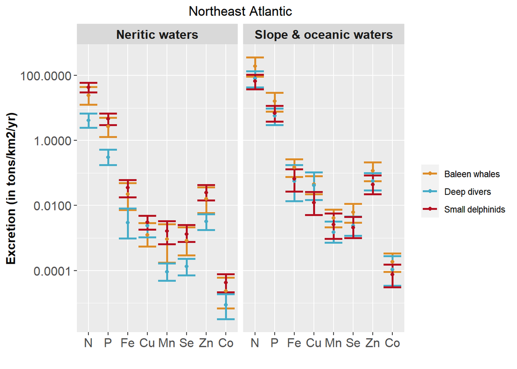

Are the differences significant ?

| Geo_area | Eco_area | Element | Group1 | Group2 | ratio_group1_superior_to_group2 |
| --- | --- | --- | --- | --- | --- |
| Northeast Atlantic | oceanic | N | Baleen whales | Deep divers | 0.975 |
| Northeast Atlantic | oceanic | N | Baleen whales | Small delphinids | 0.991 |
| Northeast Atlantic | oceanic | N | Deep divers | Small delphinids | 0.684 |
| Northeast Atlantic | shelf | N | Baleen whales | Deep divers | 1.000 |
| Northeast Atlantic | shelf | N | Baleen whales | Small delphinids | 0.014 |
| Northeast Atlantic | shelf | N | Deep divers | Small delphinids | 0.000 |
| Northeast Atlantic | oceanic | P | Baleen whales | Deep divers | 0.985 |
| Northeast Atlantic | oceanic | P | Baleen whales | Small delphinids | 0.971 |
| Northeast Atlantic | oceanic | P | Deep divers | Small delphinids | 0.316 |
| Northeast Atlantic | shelf | P | Baleen whales | Deep divers | 1.000 |
| Northeast Atlantic | shelf | P | Baleen whales | Small delphinids | 0.022 |
| Northeast Atlantic | shelf | P | Deep divers | Small delphinids | 0.000 |
| Northeast Atlantic | oceanic | Fe | Baleen whales | Deep divers | 0.926 |
| Northeast Atlantic | oceanic | Fe | Baleen whales | Small delphinids | 0.953 |
| Northeast Atlantic | oceanic | Fe | Deep divers | Small delphinids | 0.319 |
| Northeast Atlantic | shelf | Fe | Baleen whales | Deep divers | 0.996 |
| Northeast Atlantic | shelf | Fe | Baleen whales | Small delphinids | 0.043 |
| Northeast Atlantic | shelf | Fe | Deep divers | Small delphinids | 0.000 |
| Northeast Atlantic | oceanic | Cu | Baleen whales | Deep divers | 0.599 |
| Northeast Atlantic | oceanic | Cu | Baleen whales | Small delphinids | 0.995 |
| Northeast Atlantic | oceanic | Cu | Deep divers | Small delphinids | 0.999 |
| Northeast Atlantic | shelf | Cu | Baleen whales | Deep divers | 0.118 |
| Northeast Atlantic | shelf | Cu | Baleen whales | Small delphinids | 0.005 |
| Northeast Atlantic | shelf | Cu | Deep divers | Small delphinids | 0.239 |
| Northeast Atlantic | oceanic | Mn | Baleen whales | Deep divers | 0.976 |
| Northeast Atlantic | oceanic | Mn | Baleen whales | Small delphinids | 0.824 |
| Northeast Atlantic | oceanic | Mn | Deep divers | Small delphinids | 0.213 |
| Northeast Atlantic | shelf | Mn | Baleen whales | Deep divers | 0.998 |
| Northeast Atlantic | shelf | Mn | Baleen whales | Small delphinids | 0.027 |
| Northeast Atlantic | shelf | Mn | Deep divers | Small delphinids | 0.000 |
| Northeast Atlantic | oceanic | Se | Baleen whales | Deep divers | 0.978 |
| Northeast Atlantic | oceanic | Se | Baleen whales | Small delphinids | 0.984 |
| Northeast Atlantic | oceanic | Se | Deep divers | Small delphinids | 0.645 |
| Northeast Atlantic | shelf | Se | Baleen whales | Deep divers | 1.000 |
| Northeast Atlantic | shelf | Se | Baleen whales | Small delphinids | 0.038 |
| Northeast Atlantic | shelf | Se | Deep divers | Small delphinids | 0.000 |
| Northeast Atlantic | oceanic | Zn | Baleen whales | Deep divers | 0.944 |
| Northeast Atlantic | oceanic | Zn | Baleen whales | Small delphinids | 0.975 |
| Northeast Atlantic | oceanic | Zn | Deep divers | Small delphinids | 0.724 |
| Northeast Atlantic | shelf | Zn | Baleen whales | Deep divers | 0.998 |
| Northeast Atlantic | shelf | Zn | Baleen whales | Small delphinids | 0.039 |
| Northeast Atlantic | shelf | Zn | Deep divers | Small delphinids | 0.000 |
| Northeast Atlantic | oceanic | Co | Baleen whales | Deep divers | 0.847 |
| Northeast Atlantic | oceanic | Co | Baleen whales | Small delphinids | 0.970 |
| Northeast Atlantic | oceanic | Co | Deep divers | Small delphinids | 0.680 |
| Northeast Atlantic | shelf | Co | Baleen whales | Deep divers | 0.898 |
| Northeast Atlantic | shelf | Co | Baleen whales | Small delphinids | 0.021 |
| Northeast Atlantic | shelf | Co | Deep divers | Small delphinids | 0.001 |

What is the relative contribution to total excretion in each habitat ?

| Geo_area | Eco_area | Eco_gp | Element | mean | mean_total | ratio_contribution |
| --- | --- | --- | --- | --- | --- | --- |
| Northeast Atlantic | oceanic | Baleen whales | N | 105453.6291478 | 185618.4412418 | 0.5681204 |
| Northeast Atlantic | oceanic | Baleen whales | P | 8780.1249807 | 15661.1426480 | 0.5606312 |
| Northeast Atlantic | oceanic | Baleen whales | Fe | 80.3604597 | 146.3949786 | 0.5489291 |
| Northeast Atlantic | oceanic | Baleen whales | Cu | 24.3014419 | 53.7696212 | 0.4519549 |
| Northeast Atlantic | oceanic | Baleen whales | Mn | 2.2410615 | 4.4716960 | 0.5011659 |
| Northeast Atlantic | oceanic | Baleen whales | Se | 3.3580691 | 5.8067687 | 0.5783025 |
| Northeast Atlantic | oceanic | Baleen whales | Zn | 63.4482348 | 118.4720783 | 0.5355543 |
| Northeast Atlantic | oceanic | Baleen whales | Co | 0.1018889 | 0.2014518 | 0.5057730 |
| Northeast Atlantic | oceanic | Baleen whales | As | 28.5789700 | 45.1466083 | 0.6330258 |
| Northeast Atlantic | oceanic | Deep divers | N | 43745.4620206 | 185618.4412418 | 0.2356741 |
| Northeast Atlantic | oceanic | Deep divers | P | 3135.7525826 | 15661.1426480 | 0.2002250 |
| Northeast Atlantic | oceanic | Deep divers | Fe | 30.1578786 | 146.3949786 | 0.2060035 |
| Northeast Atlantic | oceanic | Deep divers | Cu | 22.7336284 | 53.7696212 | 0.4227969 |
| Northeast Atlantic | oceanic | Deep divers | Mn | 0.8261436 | 4.4716960 | 0.1847495 |
| Northeast Atlantic | oceanic | Deep divers | Se | 1.3098442 | 5.8067687 | 0.2255720 |
| Northeast Atlantic | oceanic | Deep divers | Zn | 30.8854399 | 118.4720783 | 0.2606981 |
| Northeast Atlantic | oceanic | Deep divers | Co | 0.0583337 | 0.2014518 | 0.2895665 |
| Northeast Atlantic | oceanic | Deep divers | As | 10.2959513 | 45.1466083 | 0.2280559 |
| Northeast Atlantic | oceanic | Small delphinids | N | 36419.3500734 | 185618.4412418 | 0.1962055 |
| Northeast Atlantic | oceanic | Small delphinids | P | 3745.2650847 | 15661.1426480 | 0.2391438 |
| Northeast Atlantic | oceanic | Small delphinids | Fe | 35.8766403 | 146.3949786 | 0.2450674 |
| Northeast Atlantic | oceanic | Small delphinids | Cu | 6.7345509 | 53.7696212 | 0.1252482 |
| Northeast Atlantic | oceanic | Small delphinids | Mn | 1.4044908 | 4.4716960 | 0.3140846 |
| Northeast Atlantic | oceanic | Small delphinids | Se | 1.1388555 | 5.8067687 | 0.1961255 |
| Northeast Atlantic | oceanic | Small delphinids | Zn | 24.1384036 | 118.4720783 | 0.2037476 |
| Northeast Atlantic | oceanic | Small delphinids | Co | 0.0412292 | 0.2014518 | 0.2046605 |
| Northeast Atlantic | oceanic | Small delphinids | As | 6.2716870 | 45.1466083 | 0.1389182 |
| Northeast Atlantic | shelf | Baleen whales | N | 26541.0556878 | 77969.4731737 | 0.3404032 |
| Northeast Atlantic | shelf | Baleen whales | P | 2879.3031732 | 8232.6569712 | 0.3497417 |
| Northeast Atlantic | shelf | Baleen whales | Fe | 23.9967291 | 66.0456867 | 0.3633353 |
| Northeast Atlantic | shelf | Baleen whales | Cu | 1.3662453 | 7.3119917 | 0.1868500 |
| Northeast Atlantic | shelf | Baleen whales | Mn | 1.0073075 | 2.8947433 | 0.3479782 |
| Northeast Atlantic | shelf | Baleen whales | Se | 0.9043735 | 2.4737486 | 0.3655883 |
| Northeast Atlantic | shelf | Baleen whales | Zn | 17.5630333 | 48.3222344 | 0.3634566 |
| Northeast Atlantic | shelf | Baleen whales | Co | 0.0256850 | 0.0818309 | 0.3138793 |
| Northeast Atlantic | shelf | Baleen whales | As | 3.2874536 | 14.9632877 | 0.2197013 |
| Northeast Atlantic | shelf | Deep divers | N | 4554.7508573 | 77969.4731737 | 0.0584171 |
| Northeast Atlantic | shelf | Deep divers | P | 331.4948401 | 8232.6569712 | 0.0402658 |
| Northeast Atlantic | shelf | Deep divers | Fe | 3.2197551 | 66.0456867 | 0.0487504 |
| Northeast Atlantic | shelf | Deep divers | Cu | 2.6205396 | 7.3119917 | 0.3583893 |
| Northeast Atlantic | shelf | Deep divers | Mn | 0.0997532 | 2.8947433 | 0.0344601 |
| Northeast Atlantic | shelf | Deep divers | Se | 0.1440236 | 2.4737486 | 0.0582208 |
| Northeast Atlantic | shelf | Deep divers | Zn | 3.4925459 | 48.3222344 | 0.0722762 |
| Northeast Atlantic | shelf | Deep divers | Co | 0.0093992 | 0.0818309 | 0.1148612 |
| Northeast Atlantic | shelf | Deep divers | As | 1.3044835 | 14.9632877 | 0.0871789 |
| Northeast Atlantic | shelf | Small delphinids | N | 46873.6666286 | 77969.4731737 | 0.6011797 |
| Northeast Atlantic | shelf | Small delphinids | P | 5021.8589578 | 8232.6569712 | 0.6099925 |
| Northeast Atlantic | shelf | Small delphinids | Fe | 38.8292025 | 66.0456867 | 0.5879143 |
| Northeast Atlantic | shelf | Small delphinids | Cu | 3.3252068 | 7.3119917 | 0.4547607 |
| Northeast Atlantic | shelf | Small delphinids | Mn | 1.7876825 | 2.8947433 | 0.6175617 |
| Northeast Atlantic | shelf | Small delphinids | Se | 1.4253515 | 2.4737486 | 0.5761909 |
| Northeast Atlantic | shelf | Small delphinids | Zn | 27.2666553 | 48.3222344 | 0.5642673 |
| Northeast Atlantic | shelf | Small delphinids | Co | 0.0467467 | 0.0818309 | 0.5712595 |
| Northeast Atlantic | shelf | Small delphinids | As | 10.3713505 | 14.9632877 | 0.6931198 |

# Central North Atlantic

## Excretion in neritic and oceanic waters

In absolute value, is there more excretion in an habitat than in the other ?

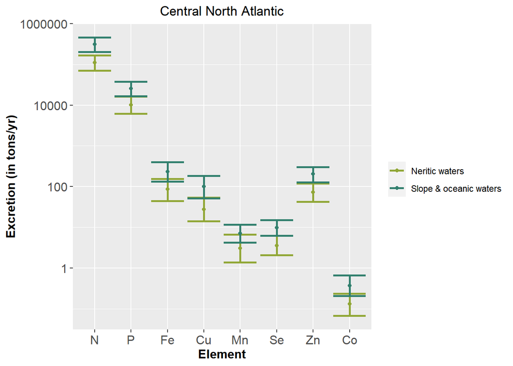

The full results being:

| Geo_area | Eco_area | Element | min | 2.5_quant | mean | median | 97.5_quant | max |
| --- | --- | --- | --- | --- | --- | --- | --- | --- |
| Central North Atlantic | oceanic | N | 159869.8424151 | 201902.2654237 | 311481.9872862 | 301938.6014784 | 456574.1766774 | 657036.9676879 |
| Central North Atlantic | oceanic | P | 14129.7710246 | 16773.4843027 | 25632.1141263 | 25126.9566370 | 37724.8629737 | 59163.3657410 |
| Central North Atlantic | oceanic | Fe | 100.4517288 | 131.6564514 | 230.6739732 | 219.7180275 | 400.5894457 | 594.1532226 |
| Central North Atlantic | oceanic | Cu | 36.7805770 | 51.9429156 | 101.0593692 | 94.6794429 | 185.5519103 | 236.5225642 |
| Central North Atlantic | oceanic | Mn | 3.0888953 | 4.2615721 | 7.1518978 | 6.8592003 | 11.5588124 | 14.7055428 |
| Central North Atlantic | oceanic | Se | 4.9759625 | 6.2107804 | 9.7770292 | 9.4676162 | 15.2266834 | 23.7330022 |
| Central North Atlantic | oceanic | Zn | 100.2436166 | 128.2367833 | 203.3117256 | 199.1735395 | 300.9002038 | 406.1312325 |
| Central North Atlantic | oceanic | Co | 0.1563389 | 0.2088058 | 0.3718247 | 0.3508131 | 0.6579105 | 1.0447511 |
| Central North Atlantic | oceanic | As | 36.3139814 | 47.2364977 | 78.1652699 | 75.4190866 | 122.5007210 | 180.6273115 |
| Central North Atlantic | shelf | N | 60087.7062149 | 70591.2026884 | 111715.0283503 | 109098.9068646 | 165080.6232989 | 203995.8223132 |
| Central North Atlantic | shelf | P | 5072.9636825 | 6209.6467866 | 10081.6674014 | 9659.6822685 | 16087.9949860 | 22265.4114987 |
| Central North Atlantic | shelf | Fe | 29.7879612 | 44.2143323 | 86.3127954 | 81.1241440 | 153.7529401 | 252.1252918 |
| Central North Atlantic | shelf | Cu | 11.3844903 | 14.1322152 | 27.6975597 | 25.4059301 | 54.0138802 | 77.9090028 |
| Central North Atlantic | shelf | Mn | 0.9476634 | 1.3954461 | 3.0808643 | 2.6962733 | 6.7246892 | 10.3028664 |
| Central North Atlantic | shelf | Se | 1.5690533 | 2.0592150 | 3.5628429 | 3.3508645 | 6.2698331 | 9.2086220 |
| Central North Atlantic | shelf | Zn | 31.5503927 | 42.1366777 | 73.0949768 | 70.3632362 | 120.6367249 | 162.3875113 |
| Central North Atlantic | shelf | Co | 0.0482086 | 0.0676845 | 0.1321130 | 0.1241090 | 0.2355549 | 0.3230437 |
| Central North Atlantic | shelf | As | 11.1168062 | 13.7076533 | 24.4326116 | 23.5017245 | 42.5336942 | 74.4108005 |

And per unit area, so considering the respective size of each of the habitat ?

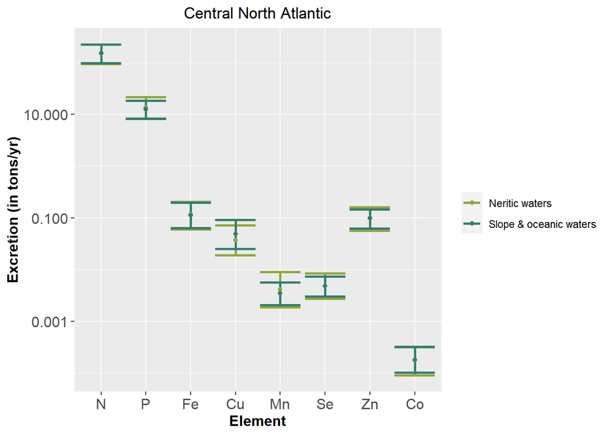

The details being:

| Geo_area | Eco_area | Element | min | 2.5_quant | mean | median | 97.5_quant | max |
| --- | --- | --- | --- | --- | --- | --- | --- | --- |
| Central North Atlantic | oceanic | N | 78.1058005 | 98.6411060 | 152.1772312 | 147.5147271 | 223.0632809 | 321.0011191 |
| Central North Atlantic | oceanic | P | 6.9032224 | 8.1948315 | 12.5227921 | 12.2759930 | 18.4308096 | 28.9047764 |
| Central North Atlantic | oceanic | Fe | 0.0490766 | 0.0643219 | 0.1126978 | 0.1073452 | 0.1957115 | 0.2902787 |
| Central North Atlantic | oceanic | Cu | 0.0179695 | 0.0253772 | 0.0493734 | 0.0462565 | 0.0906530 | 0.1155552 |
| Central North Atlantic | oceanic | Mn | 0.0015091 | 0.0020820 | 0.0034941 | 0.0033511 | 0.0056472 | 0.0071845 |
| Central North Atlantic | oceanic | Se | 0.0024310 | 0.0030343 | 0.0047767 | 0.0046255 | 0.0074391 | 0.0115950 |
| Central North Atlantic | oceanic | Zn | 0.0489749 | 0.0626512 | 0.0993297 | 0.0973080 | 0.1470074 | 0.1984189 |
| Central North Atlantic | oceanic | Co | 0.0000764 | 0.0001020 | 0.0001817 | 0.0001714 | 0.0003214 | 0.0005104 |
| Central North Atlantic | oceanic | As | 0.0177415 | 0.0230778 | 0.0381883 | 0.0368467 | 0.0598488 | 0.0882470 |
| Central North Atlantic | shelf | N | 80.7767259 | 94.8967200 | 150.1800417 | 146.6631538 | 221.9201414 | 274.2343761 |
| Central North Atlantic | shelf | P | 6.8196545 | 8.3477132 | 13.5529235 | 12.9856431 | 21.6273119 | 29.9316974 |
| Central North Atlantic | shelf | Fe | 0.0400444 | 0.0594379 | 0.1160315 | 0.1090563 | 0.2066922 | 0.3389355 |
| Central North Atlantic | shelf | Cu | 0.0153043 | 0.0189981 | 0.0372342 | 0.0341535 | 0.0726116 | 0.1047341 |
| Central North Atlantic | shelf | Mn | 0.0012740 | 0.0018759 | 0.0041416 | 0.0036246 | 0.0090401 | 0.0138503 |
| Central North Atlantic | shelf | Se | 0.0021093 | 0.0027682 | 0.0047896 | 0.0045046 | 0.0084286 | 0.0123793 |
| Central North Atlantic | shelf | Zn | 0.0424136 | 0.0566449 | 0.0982626 | 0.0945903 | 0.1621736 | 0.2182998 |
| Central North Atlantic | shelf | Co | 0.0000648 | 0.0000910 | 0.0001776 | 0.0001668 | 0.0003167 | 0.0004343 |
| Central North Atlantic | shelf | As | 0.0149445 | 0.0184274 | 0.0328451 | 0.0315937 | 0.0571786 | 0.1000315 |

Are the differences between the two areas significant ? (per surface unit)

| Geo_area | Element | Area1 | Area2 | ratio_area1_superior_to_area2 |
| --- | --- | --- | --- | --- |
| Central North Atlantic | N | Neritic waters | Oceanic waters | 0.492 |
| Central North Atlantic | N | Oceanic waters | Neritic waters | 0.508 |
| Central North Atlantic | P | Neritic waters | Oceanic waters | 0.598 |
| Central North Atlantic | P | Oceanic waters | Neritic waters | 0.402 |
| Central North Atlantic | Fe | Neritic waters | Oceanic waters | 0.536 |
| Central North Atlantic | Fe | Oceanic waters | Neritic waters | 0.464 |
| Central North Atlantic | Cu | Neritic waters | Oceanic waters | 0.195 |
| Central North Atlantic | Cu | Oceanic waters | Neritic waters | 0.805 |
| Central North Atlantic | Mn | Neritic waters | Oceanic waters | 0.618 |
| Central North Atlantic | Mn | Oceanic waters | Neritic waters | 0.382 |
| Central North Atlantic | Se | Neritic waters | Oceanic waters | 0.480 |
| Central North Atlantic | Se | Oceanic waters | Neritic waters | 0.520 |
| Central North Atlantic | Zn | Neritic waters | Oceanic waters | 0.475 |
| Central North Atlantic | Zn | Oceanic waters | Neritic waters | 0.525 |
| Central North Atlantic | Co | Neritic waters | Oceanic waters | 0.462 |
| Central North Atlantic | Co | Oceanic waters | Neritic waters | 0.538 |

## Excretion per taxa

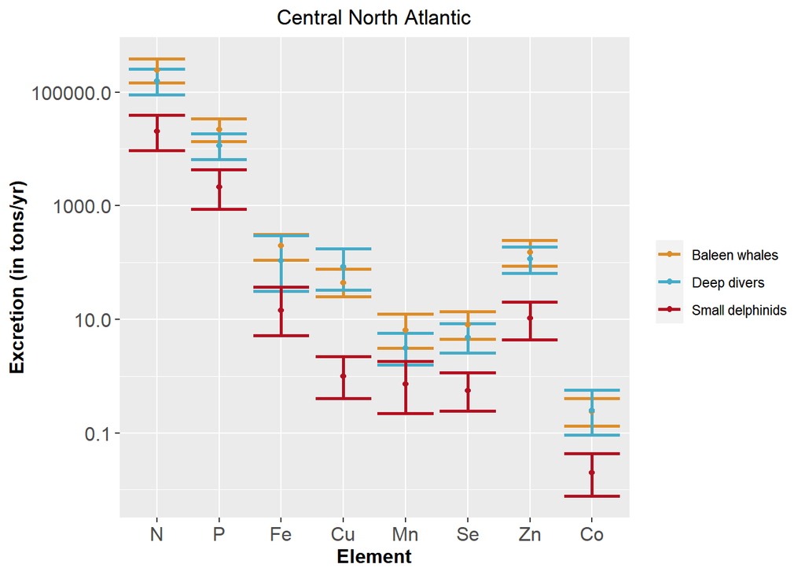

Are the differences significant ?

| Geo_area | Element | Group1 | Group2 | ratio_group1_superior_to_group2 |
| --- | --- | --- | --- | --- |
| Central North Atlantic | N | Baleen whales | Deep divers | 0.892 |
| Central North Atlantic | N | Baleen whales | Small delphinids | 1.000 |
| Central North Atlantic | N | Deep divers | Small delphinids | 1.000 |
| Central North Atlantic | P | Baleen whales | Deep divers | 0.970 |
| Central North Atlantic | P | Baleen whales | Small delphinids | 1.000 |
| Central North Atlantic | P | Deep divers | Small delphinids | 1.000 |
| Central North Atlantic | Fe | Baleen whales | Deep divers | 0.870 |
| Central North Atlantic | Fe | Baleen whales | Small delphinids | 1.000 |
| Central North Atlantic | Fe | Deep divers | Small delphinids | 0.996 |
| Central North Atlantic | Cu | Baleen whales | Deep divers | 0.149 |
| Central North Atlantic | Cu | Baleen whales | Small delphinids | 1.000 |
| Central North Atlantic | Cu | Deep divers | Small delphinids | 1.000 |
| Central North Atlantic | Mn | Baleen whales | Deep divers | 0.926 |
| Central North Atlantic | Mn | Baleen whales | Small delphinids | 1.000 |
| Central North Atlantic | Mn | Deep divers | Small delphinids | 0.996 |
| Central North Atlantic | Se | Baleen whales | Deep divers | 0.876 |
| Central North Atlantic | Se | Baleen whales | Small delphinids | 1.000 |
| Central North Atlantic | Se | Deep divers | Small delphinids | 1.000 |
| Central North Atlantic | Zn | Baleen whales | Deep divers | 0.771 |
| Central North Atlantic | Zn | Baleen whales | Small delphinids | 1.000 |
| Central North Atlantic | Zn | Deep divers | Small delphinids | 1.000 |
| Central North Atlantic | Co | Baleen whales | Deep divers | 0.532 |
| Central North Atlantic | Co | Baleen whales | Small delphinids | 1.000 |
| Central North Atlantic | Co | Deep divers | Small delphinids | 1.000 |

What are their relative contribution to total excretion in this area ?

| Geo_area | Eco_gp | Element | mean | mean_total | ratio_contribution |
| --- | --- | --- | --- | --- | --- |
| Central North Atlantic | Baleen whales | N | 244032.6566357 | 423197.0156365 | 0.5766408 |
| Central North Atlantic | Baleen whales | P | 22057.9943006 | 35713.7815277 | 0.6176326 |
| Central North Atlantic | Baleen whales | Fe | 196.0599871 | 316.9867686 | 0.6185116 |
| Central North Atlantic | Baleen whales | Cu | 44.0810400 | 128.7569289 | 0.3423586 |
| Central North Atlantic | Baleen whales | Mn | 6.3769501 | 10.2327621 | 0.6231895 |
| Central North Atlantic | Baleen whales | Se | 7.9393279 | 13.3398721 | 0.5951577 |
| Central North Atlantic | Baleen whales | Zn | 151.1591002 | 276.4067024 | 0.5468721 |
| Central North Atlantic | Baleen whales | Co | 0.2361032 | 0.5039377 | 0.4685166 |
| Central North Atlantic | Baleen whales | As | 55.9896260 | 102.5978814 | 0.5457191 |
| Central North Atlantic | Deep divers | N | 158614.3991822 | 423197.0156365 | 0.3748004 |
| Central North Atlantic | Deep divers | P | 11507.9026672 | 35713.7815277 | 0.3222258 |
| Central North Atlantic | Deep divers | Fe | 106.6679710 | 316.9867686 | 0.3365061 |
| Central North Atlantic | Deep divers | Cu | 83.6750370 | 128.7569289 | 0.6498682 |
| Central North Atlantic | Deep divers | Mn | 3.1368022 | 10.2327621 | 0.3065450 |
| Central North Atlantic | Deep divers | Se | 4.8434201 | 13.3398721 | 0.3630785 |
| Central North Atlantic | Deep divers | Zn | 114.8763166 | 276.4067024 | 0.4156061 |
| Central North Atlantic | Deep divers | Co | 0.2481675 | 0.5039377 | 0.4924566 |
| Central North Atlantic | Deep divers | As | 39.9798293 | 102.5978814 | 0.3896750 |
| Central North Atlantic | Small delphinids | N | 20549.9598185 | 423197.0156365 | 0.0485588 |
| Central North Atlantic | Small delphinids | P | 2147.8845599 | 35713.7815277 | 0.0601416 |
| Central North Atlantic | Small delphinids | Fe | 14.2588104 | 316.9867686 | 0.0449824 |
| Central North Atlantic | Small delphinids | Cu | 1.0008519 | 128.7569289 | 0.0077732 |
| Central North Atlantic | Small delphinids | Mn | 0.7190097 | 10.2327621 | 0.0702655 |
| Central North Atlantic | Small delphinids | Se | 0.5571241 | 13.3398721 | 0.0417638 |
| Central North Atlantic | Small delphinids | Zn | 10.3712857 | 276.4067024 | 0.0375218 |
| Central North Atlantic | Small delphinids | Co | 0.0196671 | 0.5039377 | 0.0390268 |
| Central North Atlantic | Small delphinids | As | 6.6284262 | 102.5978814 | 0.0646059 |

## Excretion per taxa and per habitat

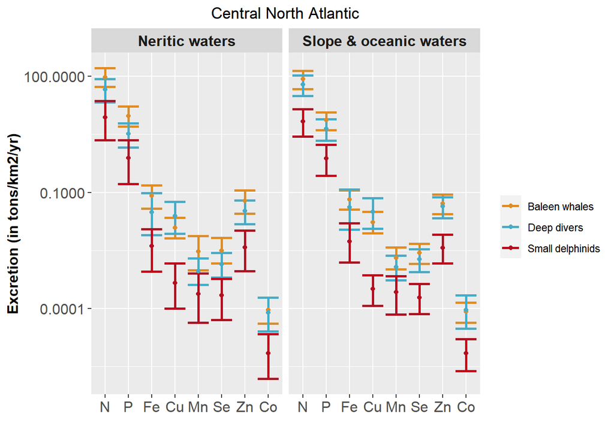

Are the differences significant ?

| Geo_area | Eco_area | Element | Group1 | Group2 | ratio_group1_superior_to_group2 |
| --- | --- | --- | --- | --- | --- |
| Central North Atlantic | oceanic | N | Baleen whales | Deep divers | 0.774 |
| Central North Atlantic | oceanic | N | Baleen whales | Small delphinids | 1.000 |
| Central North Atlantic | oceanic | N | Deep divers | Small delphinids | 1.000 |
| Central North Atlantic | shelf | N | Baleen whales | Deep divers | 0.966 |
| Central North Atlantic | shelf | N | Baleen whales | Small delphinids | 1.000 |
| Central North Atlantic | shelf | N | Deep divers | Small delphinids | 0.996 |
| Central North Atlantic | oceanic | P | Baleen whales | Deep divers | 0.881 |
| Central North Atlantic | oceanic | P | Baleen whales | Small delphinids | 1.000 |
| Central North Atlantic | oceanic | P | Deep divers | Small delphinids | 1.000 |
| Central North Atlantic | shelf | P | Baleen whales | Deep divers | 0.991 |
| Central North Atlantic | shelf | P | Baleen whales | Small delphinids | 1.000 |
| Central North Atlantic | shelf | P | Deep divers | Small delphinids | 0.990 |
| Central North Atlantic | oceanic | Fe | Baleen whales | Deep divers | 0.795 |
| Central North Atlantic | oceanic | Fe | Baleen whales | Small delphinids | 1.000 |
| Central North Atlantic | oceanic | Fe | Deep divers | Small delphinids | 0.991 |
| Central North Atlantic | shelf | Fe | Baleen whales | Deep divers | 0.931 |
| Central North Atlantic | shelf | Fe | Baleen whales | Small delphinids | 1.000 |
| Central North Atlantic | shelf | Fe | Deep divers | Small delphinids | 0.993 |
| Central North Atlantic | oceanic | Cu | Baleen whales | Deep divers | 0.167 |
| Central North Atlantic | oceanic | Cu | Baleen whales | Small delphinids | 1.000 |
| Central North Atlantic | oceanic | Cu | Deep divers | Small delphinids | 1.000 |
| Central North Atlantic | shelf | Cu | Baleen whales | Deep divers | 0.159 |
| Central North Atlantic | shelf | Cu | Baleen whales | Small delphinids | 1.000 |
| Central North Atlantic | shelf | Cu | Deep divers | Small delphinids | 1.000 |
| Central North Atlantic | oceanic | Mn | Baleen whales | Deep divers | 0.873 |
| Central North Atlantic | oceanic | Mn | Baleen whales | Small delphinids | 0.999 |
| Central North Atlantic | oceanic | Mn | Deep divers | Small delphinids | 0.992 |
| Central North Atlantic | shelf | Mn | Baleen whales | Deep divers | 0.954 |
| Central North Atlantic | shelf | Mn | Baleen whales | Small delphinids | 1.000 |
| Central North Atlantic | shelf | Mn | Deep divers | Small delphinids | 0.970 |
| Central North Atlantic | oceanic | Se | Baleen whales | Deep divers | 0.797 |
| Central North Atlantic | oceanic | Se | Baleen whales | Small delphinids | 1.000 |
| Central North Atlantic | oceanic | Se | Deep divers | Small delphinids | 1.000 |
| Central North Atlantic | shelf | Se | Baleen whales | Deep divers | 0.945 |
| Central North Atlantic | shelf | Se | Baleen whales | Small delphinids | 1.000 |
| Central North Atlantic | shelf | Se | Deep divers | Small delphinids | 0.997 |
| Central North Atlantic | oceanic | Zn | Baleen whales | Deep divers | 0.648 |
| Central North Atlantic | oceanic | Zn | Baleen whales | Small delphinids | 1.000 |
| Central North Atlantic | oceanic | Zn | Deep divers | Small delphinids | 1.000 |
| Central North Atlantic | shelf | Zn | Baleen whales | Deep divers | 0.895 |
| Central North Atlantic | shelf | Zn | Baleen whales | Small delphinids | 1.000 |
| Central North Atlantic | shelf | Zn | Deep divers | Small delphinids | 1.000 |
| Central North Atlantic | oceanic | Co | Baleen whales | Deep divers | 0.480 |
| Central North Atlantic | oceanic | Co | Baleen whales | Small delphinids | 1.000 |
| Central North Atlantic | oceanic | Co | Deep divers | Small delphinids | 1.000 |
| Central North Atlantic | shelf | Co | Baleen whales | Deep divers | 0.639 |
| Central North Atlantic | shelf | Co | Baleen whales | Small delphinids | 1.000 |
| Central North Atlantic | shelf | Co | Deep divers | Small delphinids | 0.999 |

What is the relative contribution to total excretion in each habitat ?

| Geo_area | Eco_area | Eco_gp | Element | mean | mean_total | ratio_contribution |
| --- | --- | --- | --- | --- | --- | --- |
| Central North Atlantic | oceanic | Baleen whales | N | 172548.5073759 | 311481.9872862 | 0.5539598 |
| Central North Atlantic | oceanic | Baleen whales | P | 15027.5190467 | 25632.1141263 | 0.5862770 |
| Central North Atlantic | oceanic | Baleen whales | Fe | 135.7869950 | 230.6739732 | 0.5886533 |
| Central North Atlantic | oceanic | Baleen whales | Cu | 34.8957379 | 101.0593692 | 0.3452994 |
| Central North Atlantic | oceanic | Baleen whales | Mn | 4.1736493 | 7.1518978 | 0.5835723 |
| Central North Atlantic | oceanic | Baleen whales | Se | 5.5845666 | 9.7770292 | 0.5711926 |
| Central North Atlantic | oceanic | Baleen whales | Zn | 105.7006670 | 203.3117256 | 0.5198946 |
| Central North Atlantic | oceanic | Baleen whales | Co | 0.1669427 | 0.3718247 | 0.4489823 |
| Central North Atlantic | oceanic | Baleen whales | As | 42.7799128 | 78.1652699 | 0.5473008 |
| Central North Atlantic | oceanic | Deep divers | N | 124933.8858021 | 311481.9872862 | 0.4010951 |
| Central North Atlantic | oceanic | Deep divers | P | 9040.5911467 | 25632.1141263 | 0.3527056 |
| Central North Atlantic | oceanic | Deep divers | Fe | 83.7233900 | 230.6739732 | 0.3629512 |
| Central North Atlantic | oceanic | Deep divers | Cu | 65.5074613 | 101.0593692 | 0.6482077 |
| Central North Atlantic | oceanic | Deep divers | Mn | 2.4389223 | 7.1518978 | 0.3410175 |
| Central North Atlantic | oceanic | Deep divers | Se | 3.7982871 | 9.7770292 | 0.3884909 |
| Central North Atlantic | oceanic | Deep divers | Zn | 90.0545003 | 203.3117256 | 0.4429381 |
| Central North Atlantic | oceanic | Deep divers | Co | 0.1904155 | 0.3718247 | 0.5121108 |
| Central North Atlantic | oceanic | Deep divers | As | 31.1134155 | 78.1652699 | 0.3980465 |
| Central North Atlantic | oceanic | Small delphinids | N | 13999.5941082 | 311481.9872862 | 0.0449451 |
| Central North Atlantic | oceanic | Small delphinids | P | 1564.0039330 | 25632.1141263 | 0.0610174 |
| Central North Atlantic | oceanic | Small delphinids | Fe | 11.1635882 | 230.6739732 | 0.0483955 |
| Central North Atlantic | oceanic | Small delphinids | Cu | 0.6561699 | 101.0593692 | 0.0064929 |
| Central North Atlantic | oceanic | Small delphinids | Mn | 0.5393262 | 7.1518978 | 0.0754102 |
| Central North Atlantic | oceanic | Small delphinids | Se | 0.3941755 | 9.7770292 | 0.0403165 |
| Central North Atlantic | oceanic | Small delphinids | Zn | 7.5565583 | 203.3117256 | 0.0371674 |
| Central North Atlantic | oceanic | Small delphinids | Co | 0.0144665 | 0.3718247 | 0.0389069 |
| Central North Atlantic | oceanic | Small delphinids | As | 4.2719415 | 78.1652699 | 0.0546527 |
| Central North Atlantic | shelf | Baleen whales | N | 71484.1492599 | 111715.0283503 | 0.6398794 |
| Central North Atlantic | shelf | Baleen whales | P | 7030.4752539 | 10081.6674014 | 0.6973524 |
| Central North Atlantic | shelf | Baleen whales | Fe | 60.2729921 | 86.3127954 | 0.6983089 |
| Central North Atlantic | shelf | Baleen whales | Cu | 9.1853021 | 27.6975597 | 0.3316286 |
| Central North Atlantic | shelf | Baleen whales | Mn | 2.2033008 | 3.0808643 | 0.7151567 |
| Central North Atlantic | shelf | Baleen whales | Se | 2.3547613 | 3.5628429 | 0.6609220 |
| Central North Atlantic | shelf | Baleen whales | Zn | 45.4584332 | 73.0949768 | 0.6219091 |
| Central North Atlantic | shelf | Baleen whales | Co | 0.0691605 | 0.1321130 | 0.5234949 |
| Central North Atlantic | shelf | Baleen whales | As | 13.2097132 | 24.4326116 | 0.5406591 |
| Central North Atlantic | shelf | Deep divers | N | 33680.5133802 | 111715.0283503 | 0.3014860 |
| Central North Atlantic | shelf | Deep divers | P | 2467.3115205 | 10081.6674014 | 0.2447325 |
| Central North Atlantic | shelf | Deep divers | Fe | 22.9445810 | 86.3127954 | 0.2658306 |
| Central North Atlantic | shelf | Deep divers | Cu | 18.1675756 | 27.6975597 | 0.6559269 |
| Central North Atlantic | shelf | Deep divers | Mn | 0.6978800 | 3.0808643 | 0.2265208 |
| Central North Atlantic | shelf | Deep divers | Se | 1.0451330 | 3.5628429 | 0.2933424 |
| Central North Atlantic | shelf | Deep divers | Zn | 24.8218163 | 73.0949768 | 0.3395831 |
| Central North Atlantic | shelf | Deep divers | Co | 0.0577520 | 0.1321130 | 0.4371408 |
| Central North Atlantic | shelf | Deep divers | As | 8.8664137 | 24.4326116 | 0.3628926 |
| Central North Atlantic | shelf | Small delphinids | N | 6550.3657103 | 111715.0283503 | 0.0586346 |
| Central North Atlantic | shelf | Small delphinids | P | 583.8806269 | 10081.6674014 | 0.0579151 |
| Central North Atlantic | shelf | Small delphinids | Fe | 3.0952222 | 86.3127954 | 0.0358605 |
| Central North Atlantic | shelf | Small delphinids | Cu | 0.3446820 | 27.6975597 | 0.0124445 |
| Central North Atlantic | shelf | Small delphinids | Mn | 0.1796835 | 3.0808643 | 0.0583224 |
| Central North Atlantic | shelf | Small delphinids | Se | 0.1629486 | 3.5628429 | 0.0457356 |
| Central North Atlantic | shelf | Small delphinids | Zn | 2.8147274 | 73.0949768 | 0.0385078 |
| Central North Atlantic | shelf | Small delphinids | Co | 0.0052005 | 0.1321130 | 0.0393643 |
| Central North Atlantic | shelf | Small delphinids | As | 2.3564847 | 24.4326116 | 0.0964483 |

# Gulf of Alaska

## Excretion in neritic and oceanic waters

In absolute value, is there more excretion in an habitat than in the other ?

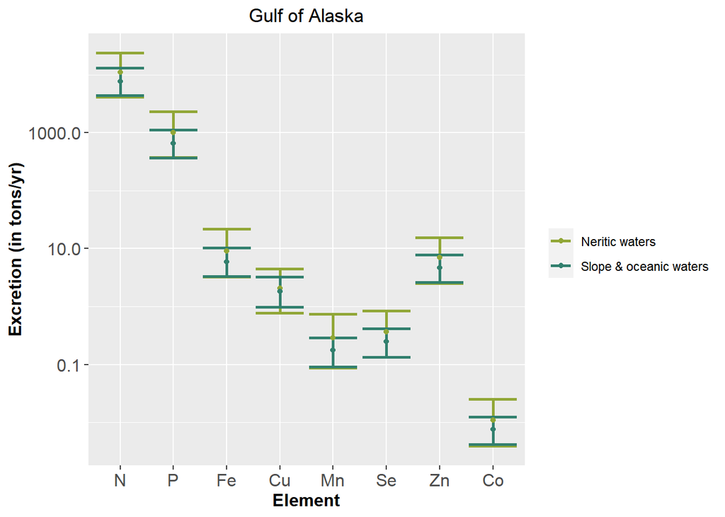

The full results being:

| Geo_area | Eco_area | Element | min | 2.5_quant | mean | median | 97.5_quant | max |
| --- | --- | --- | --- | --- | --- | --- | --- | --- |
| Gulf of Alaska | oceanic | N | 3023.4863643 | 4409.8732021 | 7772.3986209 | 7398.3122773 | 13262.3789113 | 17652.0650761 |
| Gulf of Alaska | oceanic | P | 262.3841256 | 368.7145546 | 657.9481783 | 627.9119568 | 1119.3425626 | 1774.7052522 |
| Gulf of Alaska | oceanic | Fe | 2.3204365 | 3.2934546 | 5.9491061 | 5.6612431 | 10.2276374 | 12.2269002 |
| Gulf of Alaska | oceanic | Cu | 0.7241786 | 0.9876601 | 1.8409768 | 1.7394300 | 3.2199125 | 4.1496868 |
| Gulf of Alaska | oceanic | Mn | 0.0704804 | 0.0910791 | 0.1746823 | 0.1680434 | 0.2912552 | 0.4471314 |
| Gulf of Alaska | oceanic | Se | 0.1016039 | 0.1345383 | 0.2459909 | 0.2341912 | 0.4173597 | 0.5314696 |
| Gulf of Alaska | oceanic | Zn | 1.9977533 | 2.5947589 | 4.6890787 | 4.4918896 | 7.8170835 | 9.4416045 |
| Gulf of Alaska | oceanic | Co | 0.0032076 | 0.0041185 | 0.0075215 | 0.0072019 | 0.0123511 | 0.0184986 |
| Gulf of Alaska | oceanic | As | 0.7490706 | 1.0811597 | 2.0303214 | 1.9206792 | 3.4226449 | 4.8909716 |
| Gulf of Alaska | shelf | N | 3090.2634804 | 4189.6748647 | 11209.6354829 | 9919.9290611 | 23927.1315198 | 45548.9424530 |
| Gulf of Alaska | shelf | P | 229.5455829 | 376.0628334 | 1017.0072331 | 901.3380566 | 2344.5009650 | 4146.9424907 |
| Gulf of Alaska | shelf | Fe | 1.6452356 | 3.2761000 | 9.0643496 | 7.9683454 | 21.6870148 | 34.0502160 |
| Gulf of Alaska | shelf | Cu | 0.5239148 | 0.7785230 | 2.0744138 | 1.9109657 | 4.4780605 | 8.0231161 |
| Gulf of Alaska | shelf | Mn | 0.0571171 | 0.0878841 | 0.2888834 | 0.2455510 | 0.7446263 | 1.6924179 |
| Gulf of Alaska | shelf | Se | 0.0856180 | 0.1335231 | 0.3655829 | 0.3244245 | 0.8393557 | 1.6640994 |
| Gulf of Alaska | shelf | Zn | 1.8440125 | 2.5338479 | 6.9707140 | 6.1319298 | 15.4248243 | 23.8765562 |
| Gulf of Alaska | shelf | Co | 0.0024135 | 0.0039040 | 0.0108543 | 0.0097396 | 0.0250464 | 0.0374269 |
| Gulf of Alaska | shelf | As | 0.6652299 | 0.9541180 | 2.5631825 | 2.2988581 | 5.7063027 | 8.2739431 |

And per unit area, so considering the respective size of each of the habitat ?

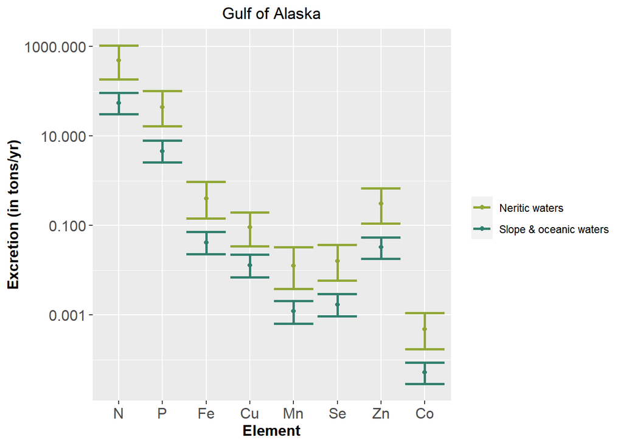

The details being:

| Geo_area | Eco_area | Element | min | 2.5_quant | mean | median | 97.5_quant | max |
| --- | --- | --- | --- | --- | --- | --- | --- | --- |
| Gulf of Alaska | oceanic | N | 21.2616126 | 31.0108942 | 54.6566807 | 52.0260490 | 93.2630510 | 124.1319870 |
| Gulf of Alaska | oceanic | P | 1.8451248 | 2.5928564 | 4.6267909 | 4.4155717 | 7.8713859 | 12.4799953 |
| Gulf of Alaska | oceanic | Fe | 0.0163177 | 0.0231601 | 0.0418350 | 0.0398107 | 0.0719223 | 0.0859814 |
| Gulf of Alaska | oceanic | Cu | 0.0050925 | 0.0069454 | 0.0129460 | 0.0122319 | 0.0226429 | 0.0291812 |
| Gulf of Alaska | oceanic | Mn | 0.0004956 | 0.0006405 | 0.0012284 | 0.0011817 | 0.0020482 | 0.0031443 |
| Gulf of Alaska | oceanic | Se | 0.0007145 | 0.0009461 | 0.0017298 | 0.0016469 | 0.0029349 | 0.0037374 |
| Gulf of Alaska | oceanic | Zn | 0.0140485 | 0.0182467 | 0.0329743 | 0.0315876 | 0.0549709 | 0.0663948 |
| Gulf of Alaska | oceanic | Co | 0.0000226 | 0.0000290 | 0.0000529 | 0.0000506 | 0.0000869 | 0.0001301 |
| Gulf of Alaska | oceanic | As | 0.0052676 | 0.0076029 | 0.0142775 | 0.0135065 | 0.0240686 | 0.0343941 |
| Gulf of Alaska | shelf | N | 135.8417284 | 184.1696279 | 492.7528895 | 436.0600053 | 1051.7882773 | 2002.2393271 |
| Gulf of Alaska | shelf | P | 10.0903593 | 16.5309611 | 44.7055797 | 39.6209968 | 103.0595176 | 182.2911992 |
| Gulf of Alaska | shelf | Fe | 0.0723212 | 0.1440107 | 0.3984505 | 0.3502723 | 0.9533173 | 1.4967786 |
| Gulf of Alaska | shelf | Cu | 0.0230302 | 0.0342223 | 0.0911870 | 0.0840022 | 0.1968465 | 0.3526799 |
| Gulf of Alaska | shelf | Mn | 0.0025108 | 0.0038632 | 0.0126987 | 0.0107939 | 0.0327323 | 0.0743953 |
| Gulf of Alaska | shelf | Se | 0.0037636 | 0.0058694 | 0.0160703 | 0.0142610 | 0.0368964 | 0.0731504 |
| Gulf of Alaska | shelf | Zn | 0.0810591 | 0.1113828 | 0.3064185 | 0.2695472 | 0.6780441 | 1.0495651 |
| Gulf of Alaska | shelf | Co | 0.0001061 | 0.0001716 | 0.0004771 | 0.0004281 | 0.0011010 | 0.0016452 |
| Gulf of Alaska | shelf | As | 0.0292422 | 0.0419411 | 0.1126723 | 0.1010531 | 0.2508375 | 0.3637058 |

Are the differences between the two areas significant ? (per surface unit)

| Geo_area | Element | Area1 | Area2 | ratio_area1_superior_to_area2 |
| --- | --- | --- | --- | --- |
| Gulf of Alaska | N | Neritic waters | Oceanic waters | 1 |
| Gulf of Alaska | N | Oceanic waters | Neritic waters | 0 |
| Gulf of Alaska | P | Neritic waters | Oceanic waters | 1 |
| Gulf of Alaska | P | Oceanic waters | Neritic waters | 0 |
| Gulf of Alaska | Fe | Neritic waters | Oceanic waters | 1 |
| Gulf of Alaska | Fe | Oceanic waters | Neritic waters | 0 |
| Gulf of Alaska | Cu | Neritic waters | Oceanic waters | 1 |
| Gulf of Alaska | Cu | Oceanic waters | Neritic waters | 0 |
| Gulf of Alaska | Mn | Neritic waters | Oceanic waters | 1 |
| Gulf of Alaska | Mn | Oceanic waters | Neritic waters | 0 |
| Gulf of Alaska | Se | Neritic waters | Oceanic waters | 1 |
| Gulf of Alaska | Se | Oceanic waters | Neritic waters | 0 |
| Gulf of Alaska | Zn | Neritic waters | Oceanic waters | 1 |
| Gulf of Alaska | Zn | Oceanic waters | Neritic waters | 0 |
| Gulf of Alaska | Co | Neritic waters | Oceanic waters | 1 |
| Gulf of Alaska | Co | Oceanic waters | Neritic waters | 0 |

## Excretion per taxa

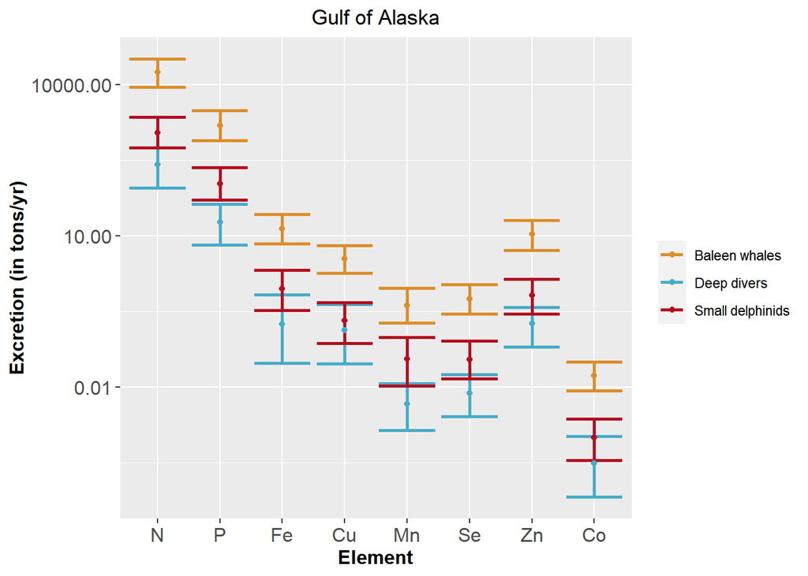

Are the differences significant ?

| Geo_area | Element | Group1 | Group2 | ratio_group1_superior_to_group2 |
| --- | --- | --- | --- | --- |
| Gulf of Alaska | N | Baleen whales | Deep divers | 1.000 |
| Gulf of Alaska | N | Baleen whales | Small delphinids | 1.000 |
| Gulf of Alaska | N | Deep divers | Small delphinids | 0.006 |
| Gulf of Alaska | P | Baleen whales | Deep divers | 1.000 |
| Gulf of Alaska | P | Baleen whales | Small delphinids | 1.000 |
| Gulf of Alaska | P | Deep divers | Small delphinids | 0.002 |
| Gulf of Alaska | Fe | Baleen whales | Deep divers | 1.000 |
| Gulf of Alaska | Fe | Baleen whales | Small delphinids | 1.000 |
| Gulf of Alaska | Fe | Deep divers | Small delphinids | 0.020 |
| Gulf of Alaska | Cu | Baleen whales | Deep divers | 1.000 |
| Gulf of Alaska | Cu | Baleen whales | Small delphinids | 1.000 |
| Gulf of Alaska | Cu | Deep divers | Small delphinids | 0.267 |
| Gulf of Alaska | Mn | Baleen whales | Deep divers | 1.000 |
| Gulf of Alaska | Mn | Baleen whales | Small delphinids | 1.000 |
| Gulf of Alaska | Mn | Deep divers | Small delphinids | 0.005 |
| Gulf of Alaska | Se | Baleen whales | Deep divers | 1.000 |
| Gulf of Alaska | Se | Baleen whales | Small delphinids | 1.000 |
| Gulf of Alaska | Se | Deep divers | Small delphinids | 0.016 |
| Gulf of Alaska | Zn | Baleen whales | Deep divers | 1.000 |
| Gulf of Alaska | Zn | Baleen whales | Small delphinids | 1.000 |
| Gulf of Alaska | Zn | Deep divers | Small delphinids | 0.025 |
| Gulf of Alaska | Co | Baleen whales | Deep divers | 1.000 |
| Gulf of Alaska | Co | Baleen whales | Small delphinids | 1.000 |
| Gulf of Alaska | Co | Deep divers | Small delphinids | 0.053 |

What are their relative contribution to total excretion in this area ?

| Geo_area | Eco_gp | Element | mean | mean_total | ratio_contribution |
| --- | --- | --- | --- | --- | --- |
| Gulf of Alaska | Baleen whales | N | 17601.8902801 | 18982.0341038 | 0.9272921 |
| Gulf of Alaska | Baleen whales | P | 1546.9757297 | 1674.9554115 | 0.9235922 |
| Gulf of Alaska | Baleen whales | Fe | 13.9305504 | 15.0134557 | 0.9278710 |
| Gulf of Alaska | Baleen whales | Cu | 3.5700503 | 3.9153906 | 0.9117993 |
| Gulf of Alaska | Baleen whales | Mn | 0.4219176 | 0.4635657 | 0.9101570 |
| Gulf of Alaska | Baleen whales | Se | 0.5688386 | 0.6115738 | 0.9301226 |
| Gulf of Alaska | Baleen whales | Zn | 10.8174741 | 11.6597927 | 0.9277587 |
| Gulf of Alaska | Baleen whales | Co | 0.0170486 | 0.0183758 | 0.9277775 |
| Gulf of Alaska | Baleen whales | As | 4.3307243 | 4.5935039 | 0.9427932 |
| Gulf of Alaska | Deep divers | N | 259.2798088 | 18982.0341038 | 0.0136592 |
| Gulf of Alaska | Deep divers | P | 18.5446920 | 1674.9554115 | 0.0110718 |
| Gulf of Alaska | Deep divers | Fe | 0.1766499 | 15.0134557 | 0.0117661 |
| Gulf of Alaska | Deep divers | Cu | 0.1346983 | 3.9153906 | 0.0344023 |
| Gulf of Alaska | Deep divers | Mn | 0.0047388 | 0.4635657 | 0.0102225 |
| Gulf of Alaska | Deep divers | Se | 0.0076194 | 0.6115738 | 0.0124587 |
| Gulf of Alaska | Deep divers | Zn | 0.1812086 | 11.6597927 | 0.0155413 |
| Gulf of Alaska | Deep divers | Co | 0.0003113 | 0.0183758 | 0.0169397 |
| Gulf of Alaska | Deep divers | As | 0.0590213 | 4.5935039 | 0.0128489 |
| Gulf of Alaska | Small delphinids | N | 1120.8640149 | 18982.0341038 | 0.0590487 |
| Gulf of Alaska | Small delphinids | P | 109.4349897 | 1674.9554115 | 0.0653361 |
| Gulf of Alaska | Small delphinids | Fe | 0.9062554 | 15.0134557 | 0.0603629 |
| Gulf of Alaska | Small delphinids | Cu | 0.2106421 | 3.9153906 | 0.0537985 |
| Gulf of Alaska | Small delphinids | Mn | 0.0369093 | 0.4635657 | 0.0796205 |
| Gulf of Alaska | Small delphinids | Se | 0.0351158 | 0.6115738 | 0.0574187 |
| Gulf of Alaska | Small delphinids | Zn | 0.6611101 | 11.6597927 | 0.0567000 |
| Gulf of Alaska | Small delphinids | Co | 0.0010159 | 0.0183758 | 0.0552828 |
| Gulf of Alaska | Small delphinids | As | 0.2037583 | 4.5935039 | 0.0443579 |

## Excretion per taxa and per habitat

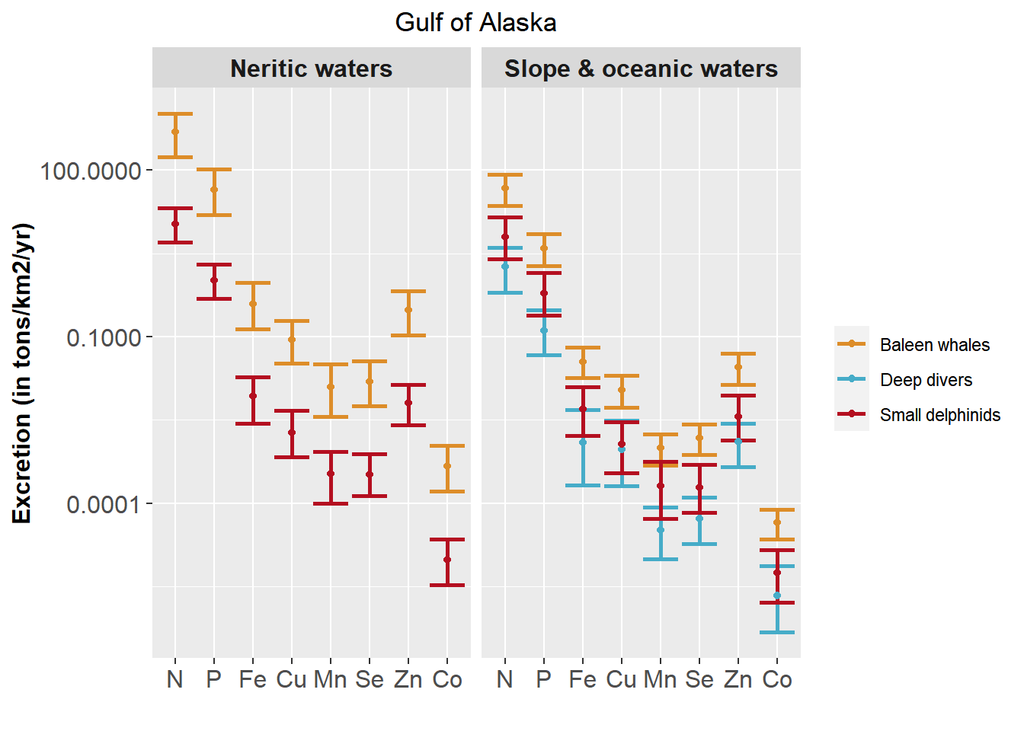

Are the differences significant ?

| Geo_area | Eco_area | Element | Group1 | Group2 | ratio_group1_superior_to_group2 |
| --- | --- | --- | --- | --- | --- |
| Gulf of Alaska | oceanic | N | Baleen whales | Deep divers | 1.000 |
| Gulf of Alaska | oceanic | N | Baleen whales | Small delphinids | 1.000 |
| Gulf of Alaska | oceanic | N | Deep divers | Small delphinids | 0.020 |
| Gulf of Alaska | shelf | N | Baleen whales | Deep divers | 0.000 |
| Gulf of Alaska | shelf | N | Baleen whales | Small delphinids | 1.000 |
| Gulf of Alaska | shelf | N | Deep divers | Small delphinids | 0.000 |
| Gulf of Alaska | oceanic | P | Baleen whales | Deep divers | 1.000 |
| Gulf of Alaska | oceanic | P | Baleen whales | Small delphinids | 0.998 |
| Gulf of Alaska | oceanic | P | Deep divers | Small delphinids | 0.007 |
| Gulf of Alaska | shelf | P | Baleen whales | Deep divers | 0.000 |
| Gulf of Alaska | shelf | P | Baleen whales | Small delphinids | 1.000 |
| Gulf of Alaska | shelf | P | Deep divers | Small delphinids | 0.000 |
| Gulf of Alaska | oceanic | Fe | Baleen whales | Deep divers | 1.000 |
| Gulf of Alaska | oceanic | Fe | Baleen whales | Small delphinids | 0.999 |
| Gulf of Alaska | oceanic | Fe | Deep divers | Small delphinids | 0.038 |
| Gulf of Alaska | shelf | Fe | Baleen whales | Deep divers | 0.000 |
| Gulf of Alaska | shelf | Fe | Baleen whales | Small delphinids | 1.000 |
| Gulf of Alaska | shelf | Fe | Deep divers | Small delphinids | 0.000 |
| Gulf of Alaska | oceanic | Cu | Baleen whales | Deep divers | 1.000 |
| Gulf of Alaska | oceanic | Cu | Baleen whales | Small delphinids | 1.000 |
| Gulf of Alaska | oceanic | Cu | Deep divers | Small delphinids | 0.328 |
| Gulf of Alaska | shelf | Cu | Baleen whales | Deep divers | 0.000 |
| Gulf of Alaska | shelf | Cu | Baleen whales | Small delphinids | 1.000 |
| Gulf of Alaska | shelf | Cu | Deep divers | Small delphinids | 0.000 |
| Gulf of Alaska | oceanic | Mn | Baleen whales | Deep divers | 1.000 |
| Gulf of Alaska | oceanic | Mn | Baleen whales | Small delphinids | 0.991 |
| Gulf of Alaska | oceanic | Mn | Deep divers | Small delphinids | 0.012 |
| Gulf of Alaska | shelf | Mn | Baleen whales | Deep divers | 0.000 |
| Gulf of Alaska | shelf | Mn | Baleen whales | Small delphinids | 1.000 |
| Gulf of Alaska | shelf | Mn | Deep divers | Small delphinids | 0.000 |
| Gulf of Alaska | oceanic | Se | Baleen whales | Deep divers | 1.000 |
| Gulf of Alaska | oceanic | Se | Baleen whales | Small delphinids | 1.000 |
| Gulf of Alaska | oceanic | Se | Deep divers | Small delphinids | 0.033 |
| Gulf of Alaska | shelf | Se | Baleen whales | Deep divers | 0.000 |
| Gulf of Alaska | shelf | Se | Baleen whales | Small delphinids | 1.000 |
| Gulf of Alaska | shelf | Se | Deep divers | Small delphinids | 0.000 |
| Gulf of Alaska | oceanic | Zn | Baleen whales | Deep divers | 1.000 |
| Gulf of Alaska | oceanic | Zn | Baleen whales | Small delphinids | 1.000 |
| Gulf of Alaska | oceanic | Zn | Deep divers | Small delphinids | 0.051 |
| Gulf of Alaska | shelf | Zn | Baleen whales | Deep divers | 0.000 |
| Gulf of Alaska | shelf | Zn | Baleen whales | Small delphinids | 1.000 |
| Gulf of Alaska | shelf | Zn | Deep divers | Small delphinids | 0.000 |
| Gulf of Alaska | oceanic | Co | Baleen whales | Deep divers | 1.000 |
| Gulf of Alaska | oceanic | Co | Baleen whales | Small delphinids | 0.999 |
| Gulf of Alaska | oceanic | Co | Deep divers | Small delphinids | 0.094 |
| Gulf of Alaska | shelf | Co | Baleen whales | Deep divers | 0.000 |
| Gulf of Alaska | shelf | Co | Baleen whales | Small delphinids | 1.000 |
| Gulf of Alaska | shelf | Co | Deep divers | Small delphinids | 0.000 |

What is the relative contribution to total excretion in each habitat ?

| Geo_area | Eco_area | Eco_gp | Element | mean | mean_total | ratio_contribution |
| --- | --- | --- | --- | --- | --- | --- |
| Gulf of Alaska | oceanic | Baleen whales | N | 6634.0321247 | 7772.3986209 | 0.8535373 |
| Gulf of Alaska | oceanic | Baleen whales | P | 553.3478600 | 657.9481783 | 0.8410204 |
| Gulf of Alaska | oceanic | Baleen whales | Fe | 5.0604219 | 5.9491061 | 0.8506189 |
| Gulf of Alaska | oceanic | Baleen whales | Cu | 1.5385018 | 1.8409768 | 0.8356986 |
| Gulf of Alaska | oceanic | Baleen whales | Mn | 0.1408136 | 0.1746823 | 0.8061124 |
| Gulf of Alaska | oceanic | Baleen whales | Se | 0.2108116 | 0.2459909 | 0.8569894 |
| Gulf of Alaska | oceanic | Baleen whales | Zn | 3.9944389 | 4.6890787 | 0.8518601 |
| Gulf of Alaska | oceanic | Baleen whales | Co | 0.0064120 | 0.0075215 | 0.8524921 |
| Gulf of Alaska | oceanic | Baleen whales | As | 1.8093938 | 2.0303214 | 0.8911859 |
| Gulf of Alaska | oceanic | Deep divers | N | 259.2798088 | 7772.3986209 | 0.0333590 |
| Gulf of Alaska | oceanic | Deep divers | P | 18.5446920 | 657.9481783 | 0.0281856 |
| Gulf of Alaska | oceanic | Deep divers | Fe | 0.1766499 | 5.9491061 | 0.0296935 |
| Gulf of Alaska | oceanic | Deep divers | Cu | 0.1346983 | 1.8409768 | 0.0731668 |
| Gulf of Alaska | oceanic | Deep divers | Mn | 0.0047388 | 0.1746823 | 0.0271280 |
| Gulf of Alaska | oceanic | Deep divers | Se | 0.0076194 | 0.2459909 | 0.0309743 |
| Gulf of Alaska | oceanic | Deep divers | Zn | 0.1812086 | 4.6890787 | 0.0386448 |
| Gulf of Alaska | oceanic | Deep divers | Co | 0.0003113 | 0.0075215 | 0.0413853 |
| Gulf of Alaska | oceanic | Deep divers | As | 0.0590213 | 2.0303214 | 0.0290699 |
| Gulf of Alaska | oceanic | Small delphinids | N | 879.0866874 | 7772.3986209 | 0.1131037 |
| Gulf of Alaska | oceanic | Small delphinids | P | 86.0556263 | 657.9481783 | 0.1307939 |
| Gulf of Alaska | oceanic | Small delphinids | Fe | 0.7120343 | 5.9491061 | 0.1196876 |
| Gulf of Alaska | oceanic | Small delphinids | Cu | 0.1677767 | 1.8409768 | 0.0911346 |
| Gulf of Alaska | oceanic | Small delphinids | Mn | 0.0291299 | 0.1746823 | 0.1667595 |
| Gulf of Alaska | oceanic | Small delphinids | Se | 0.0275599 | 0.2459909 | 0.1120363 |
| Gulf of Alaska | oceanic | Small delphinids | Zn | 0.5134312 | 4.6890787 | 0.1094951 |
| Gulf of Alaska | oceanic | Small delphinids | Co | 0.0007982 | 0.0075215 | 0.1061226 |
| Gulf of Alaska | oceanic | Small delphinids | As | 0.1619063 | 2.0303214 | 0.0797442 |
| Gulf of Alaska | shelf | Baleen whales | N | 10967.8581554 | 11209.6354829 | 0.9784313 |
| Gulf of Alaska | shelf | Baleen whales | P | 993.6278697 | 1017.0072331 | 0.9770116 |
| Gulf of Alaska | shelf | Baleen whales | Fe | 8.8701285 | 9.0643496 | 0.9785731 |
| Gulf of Alaska | shelf | Baleen whales | Cu | 2.0315484 | 2.0744138 | 0.9793362 |
| Gulf of Alaska | shelf | Baleen whales | Mn | 0.2811040 | 0.2888834 | 0.9730708 |
| Gulf of Alaska | shelf | Baleen whales | Se | 0.3580270 | 0.3655829 | 0.9793320 |
| Gulf of Alaska | shelf | Baleen whales | Zn | 6.8230352 | 6.9707140 | 0.9788144 |
| Gulf of Alaska | shelf | Baleen whales | Co | 0.0106366 | 0.0108543 | 0.9799467 |
| Gulf of Alaska | shelf | Baleen whales | As | 2.5213306 | 2.5631825 | 0.9836719 |
| Gulf of Alaska | shelf | Small delphinids | N | 241.7773275 | 11209.6354829 | 0.0215687 |
| Gulf of Alaska | shelf | Small delphinids | P | 23.3793634 | 1017.0072331 | 0.0229884 |
| Gulf of Alaska | shelf | Small delphinids | Fe | 0.1942211 | 9.0643496 | 0.0214269 |
| Gulf of Alaska | shelf | Small delphinids | Cu | 0.0428654 | 2.0744138 | 0.0206638 |
| Gulf of Alaska | shelf | Small delphinids | Mn | 0.0077794 | 0.2888834 | 0.0269292 |
| Gulf of Alaska | shelf | Small delphinids | Se | 0.0075559 | 0.3655829 | 0.0206680 |
| Gulf of Alaska | shelf | Small delphinids | Zn | 0.1476788 | 6.9707140 | 0.0211856 |
| Gulf of Alaska | shelf | Small delphinids | Co | 0.0002177 | 0.0108543 | 0.0200533 |
| Gulf of Alaska | shelf | Small delphinids | As | 0.0418520 | 2.5631825 | 0.0163281 |

# Northwest Atlantic

## Excretion in neritic and oceanic waters

In absolute value, is there more excretion in an habitat than in the other ?

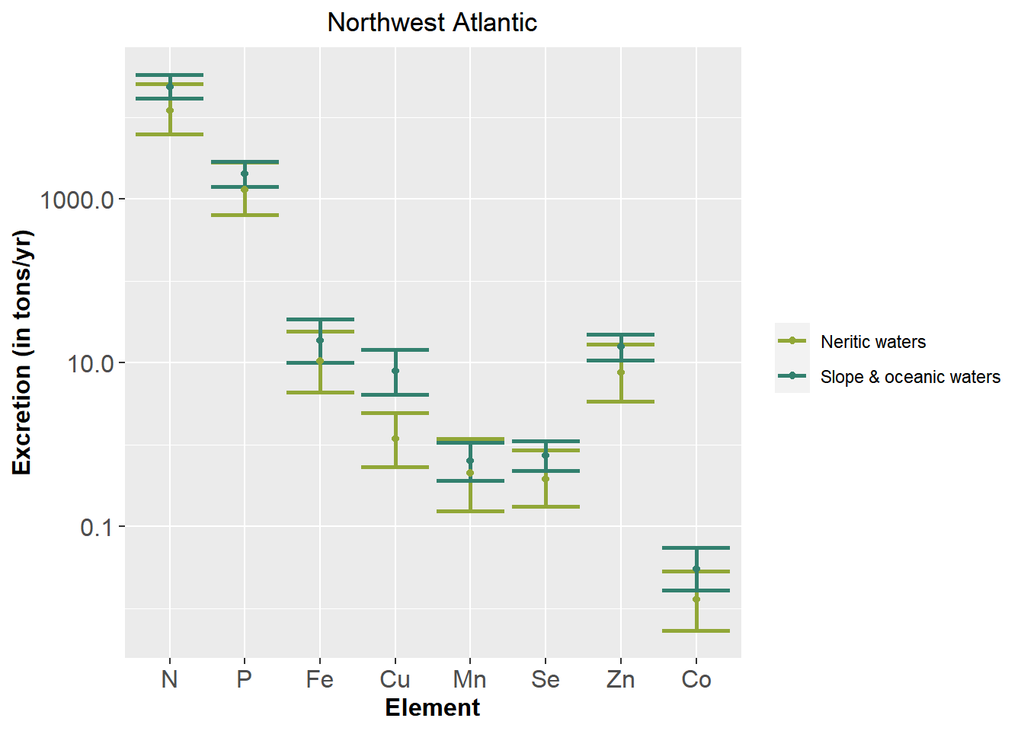

The full results being:

| Geo_area | Eco_area | Element | min | 2.5_quant | mean | median | 97.5_quant | max |
| --- | --- | --- | --- | --- | --- | --- | --- | --- |
| Northwest Atlantic | oceanic | N | 13700.0096436 | 17050.1335786 | 23731.8410058 | 23347.5438668 | 32971.5777239 | 42186.2440480 |
| Northwest Atlantic | oceanic | P | 1168.8017308 | 1429.7462121 | 2037.9928409 | 1984.0968935 | 2880.4593981 | 4066.3164311 |
| Northwest Atlantic | oceanic | Fe | 6.9407163 | 9.9704681 | 18.7971366 | 17.7007399 | 33.9095514 | 64.0260705 |
| Northwest Atlantic | oceanic | Cu | 3.4697105 | 4.0690218 | 7.8978081 | 7.3990200 | 14.5001729 | 25.2574831 |
| Northwest Atlantic | oceanic | Mn | 0.2663693 | 0.3600110 | 0.6328805 | 0.6021085 | 1.0552332 | 1.4853699 |
| Northwest Atlantic | oceanic | Se | 0.3922287 | 0.4814942 | 0.7347249 | 0.7111797 | 1.0950710 | 1.5611034 |
| Northwest Atlantic | oceanic | Zn | 9.0973601 | 10.7572958 | 15.7453413 | 15.4401591 | 22.0870391 | 32.1815511 |
| Northwest Atlantic | oceanic | Co | 0.0131435 | 0.0165945 | 0.0303429 | 0.0282444 | 0.0545609 | 0.1056185 |
| Northwest Atlantic | oceanic | As | 2.4762988 | 3.2749338 | 5.6361625 | 5.3608720 | 9.2174022 | 12.8012949 |
| Northwest Atlantic | shelf | N | 4591.6777183 | 6205.0641931 | 12139.7319110 | 11033.4470849 | 25761.5383234 | 45506.7576852 |
| Northwest Atlantic | shelf | P | 459.2070806 | 638.3230755 | 1309.9407194 | 1199.3416999 | 2805.8871764 | 4833.7902699 |
| Northwest Atlantic | shelf | Fe | 2.9640556 | 4.3384877 | 10.5782737 | 9.2042489 | 24.3478589 | 45.0836016 |
| Northwest Atlantic | shelf | Cu | 0.3688118 | 0.5389934 | 1.1767283 | 1.0519356 | 2.4471109 | 5.7825804 |
| Northwest Atlantic | shelf | Mn | 0.1089825 | 0.1525625 | 0.4494536 | 0.3727633 | 1.1734899 | 2.2490741 |
| Northwest Atlantic | shelf | Se | 0.1302348 | 0.1747747 | 0.3817421 | 0.3332878 | 0.8626629 | 2.5338444 |
| Northwest Atlantic | shelf | Zn | 2.4523501 | 3.3793361 | 7.5371564 | 6.6841410 | 16.6743442 | 28.3689469 |
| Northwest Atlantic | shelf | Co | 0.0042739 | 0.0053396 | 0.0127060 | 0.0112173 | 0.0282229 | 0.0592869 |
| Northwest Atlantic | shelf | As | 0.7057699 | 1.0977013 | 2.6055696 | 2.3346179 | 5.8126165 | 11.9998791 |

And per unit area, so considering the respective size of each of the habitat ?

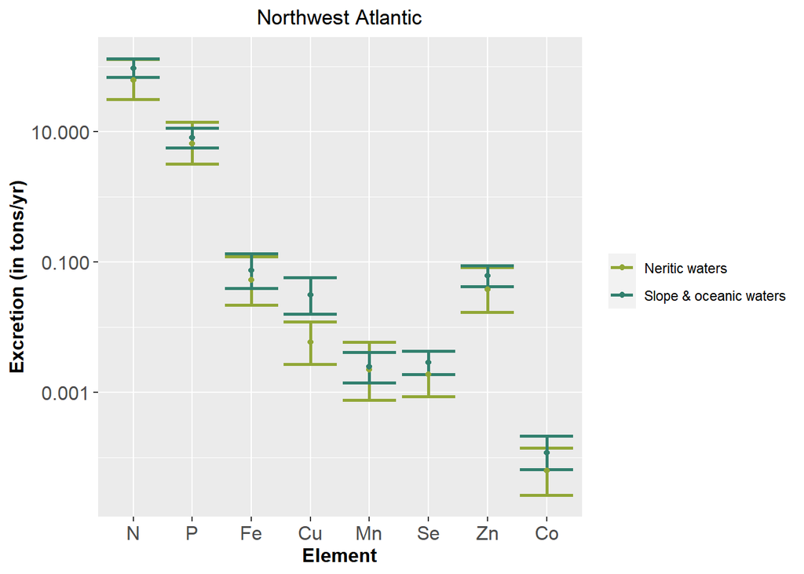

The details being:

| Geo_area | Eco_area | Element | min | 2.5_quant | mean | median | 97.5_quant | max |
| --- | --- | --- | --- | --- | --- | --- | --- | --- |
| Northwest Atlantic | oceanic | N | 54.2942335 | 67.5710425 | 94.0511832 | 92.5281829 | 130.6689985 | 167.1874578 |
| Northwest Atlantic | oceanic | P | 4.6320547 | 5.6661985 | 8.0767286 | 7.8631346 | 11.4154909 | 16.1151371 |
| Northwest Atlantic | oceanic | Fe | 0.0275066 | 0.0395138 | 0.0744946 | 0.0701494 | 0.1343863 | 0.2537404 |
| Northwest Atlantic | oceanic | Cu | 0.0137507 | 0.0161259 | 0.0312996 | 0.0293229 | 0.0574653 | 0.1000974 |
| Northwest Atlantic | oceanic | Mn | 0.0010556 | 0.0014268 | 0.0025082 | 0.0023862 | 0.0041820 | 0.0058866 |
| Northwest Atlantic | oceanic | Se | 0.0015544 | 0.0019082 | 0.0029118 | 0.0028185 | 0.0043399 | 0.0061868 |
| Northwest Atlantic | oceanic | Zn | 0.0360536 | 0.0426320 | 0.0624000 | 0.0611906 | 0.0875327 | 0.1275381 |
| Northwest Atlantic | oceanic | Co | 0.0000521 | 0.0000658 | 0.0001203 | 0.0001119 | 0.0002162 | 0.0004186 |
| Northwest Atlantic | oceanic | As | 0.0098138 | 0.0129788 | 0.0223366 | 0.0212456 | 0.0365293 | 0.0507326 |
| Northwest Atlantic | shelf | N | 22.9979451 | 31.0787765 | 60.8032411 | 55.2622866 | 129.0296226 | 227.9258208 |
| Northwest Atlantic | shelf | P | 2.2999914 | 3.1971144 | 6.5609885 | 6.0070406 | 14.0536081 | 24.2105936 |
| Northwest Atlantic | shelf | Fe | 0.0148458 | 0.0217298 | 0.0529825 | 0.0461005 | 0.1219490 | 0.2258064 |
| Northwest Atlantic | shelf | Cu | 0.0018472 | 0.0026996 | 0.0058938 | 0.0052687 | 0.0122566 | 0.0289627 |
| Northwest Atlantic | shelf | Mn | 0.0005459 | 0.0007641 | 0.0022511 | 0.0018670 | 0.0058776 | 0.0112647 |
| Northwest Atlantic | shelf | Se | 0.0006523 | 0.0008754 | 0.0019120 | 0.0016693 | 0.0043207 | 0.0126911 |
| Northwest Atlantic | shelf | Zn | 0.0122829 | 0.0169258 | 0.0377507 | 0.0334783 | 0.0835154 | 0.1420891 |
| Northwest Atlantic | shelf | Co | 0.0000214 | 0.0000267 | 0.0000636 | 0.0000562 | 0.0001414 | 0.0002969 |
| Northwest Atlantic | shelf | As | 0.0035349 | 0.0054980 | 0.0130503 | 0.0116932 | 0.0291132 | 0.0601028 |

Are the differences between the two areas significant ? (per surface unit)

| Geo_area | Element | Area1 | Area2 | ratio_area1_superior_to_area2 |
| --- | --- | --- | --- | --- |
| Northwest Atlantic | N | Neritic waters | Oceanic waters | 0.085 |
| Northwest Atlantic | N | Oceanic waters | Neritic waters | 0.915 |
| Northwest Atlantic | P | Neritic waters | Oceanic waters | 0.214 |
| Northwest Atlantic | P | Oceanic waters | Neritic waters | 0.786 |
| Northwest Atlantic | Fe | Neritic waters | Oceanic waters | 0.190 |
| Northwest Atlantic | Fe | Oceanic waters | Neritic waters | 0.810 |
| Northwest Atlantic | Cu | Neritic waters | Oceanic waters | 0.001 |
| Northwest Atlantic | Cu | Oceanic waters | Neritic waters | 0.999 |
| Northwest Atlantic | Mn | Neritic waters | Oceanic waters | 0.299 |
| Northwest Atlantic | Mn | Oceanic waters | Neritic waters | 0.701 |
| Northwest Atlantic | Se | Neritic waters | Oceanic waters | 0.099 |
| Northwest Atlantic | Se | Oceanic waters | Neritic waters | 0.901 |
| Northwest Atlantic | Zn | Neritic waters | Oceanic waters | 0.079 |
| Northwest Atlantic | Zn | Oceanic waters | Neritic waters | 0.921 |
| Northwest Atlantic | Co | Neritic waters | Oceanic waters | 0.076 |
| Northwest Atlantic | Co | Oceanic waters | Neritic waters | 0.924 |

## Excretion per taxa

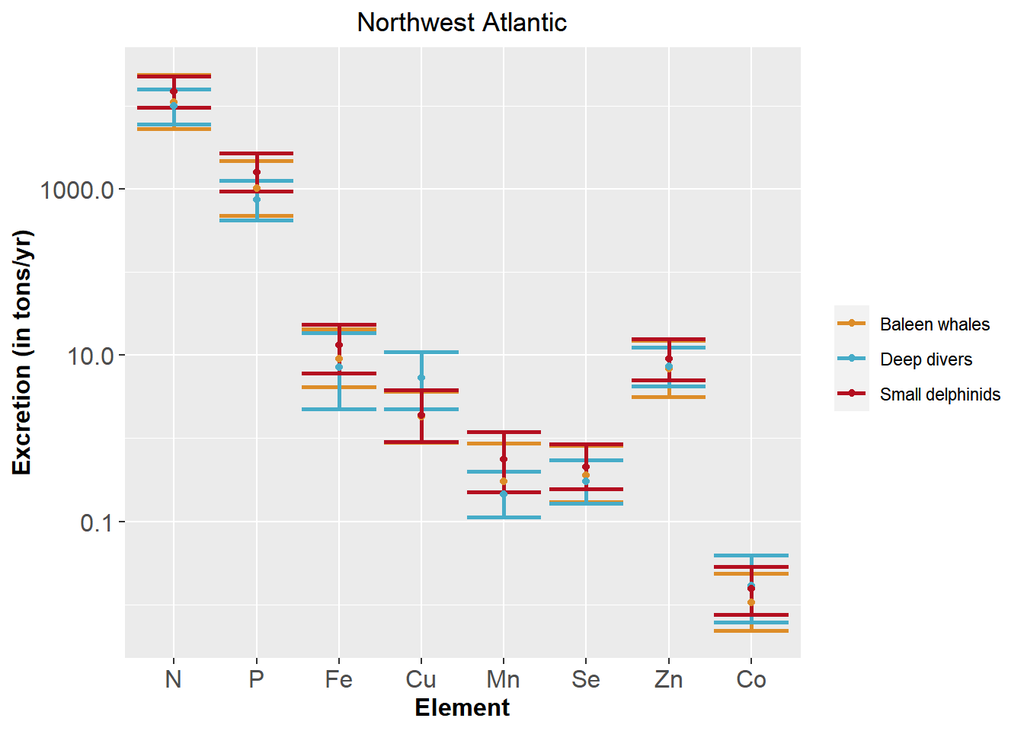

Are the differences significant ?

| Geo_area | Element | Group1 | Group2 | ratio_group1_superior_to_group2 |
| --- | --- | --- | --- | --- |
| Northwest Atlantic | N | Baleen whales | Deep divers | 0.536 |
| Northwest Atlantic | N | Baleen whales | Small delphinids | 0.209 |
| Northwest Atlantic | N | Deep divers | Small delphinids | 0.105 |
| Northwest Atlantic | P | Baleen whales | Deep divers | 0.722 |
| Northwest Atlantic | P | Baleen whales | Small delphinids | 0.153 |
| Northwest Atlantic | P | Deep divers | Small delphinids | 0.022 |
| Northwest Atlantic | Fe | Baleen whales | Deep divers | 0.679 |
| Northwest Atlantic | Fe | Baleen whales | Small delphinids | 0.195 |
| Northwest Atlantic | Fe | Deep divers | Small delphinids | 0.117 |
| Northwest Atlantic | Cu | Baleen whales | Deep divers | 0.036 |
| Northwest Atlantic | Cu | Baleen whales | Small delphinids | 0.481 |
| Northwest Atlantic | Cu | Deep divers | Small delphinids | 0.998 |
| Northwest Atlantic | Mn | Baleen whales | Deep divers | 0.663 |
| Northwest Atlantic | Mn | Baleen whales | Small delphinids | 0.097 |
| Northwest Atlantic | Mn | Deep divers | Small delphinids | 0.033 |
| Northwest Atlantic | Se | Baleen whales | Deep divers | 0.578 |
| Northwest Atlantic | Se | Baleen whales | Small delphinids | 0.266 |
| Northwest Atlantic | Se | Deep divers | Small delphinids | 0.186 |
| Northwest Atlantic | Zn | Baleen whales | Deep divers | 0.383 |
| Northwest Atlantic | Zn | Baleen whales | Small delphinids | 0.229 |
| Northwest Atlantic | Zn | Deep divers | Small delphinids | 0.307 |
| Northwest Atlantic | Co | Baleen whales | Deep divers | 0.260 |
| Northwest Atlantic | Co | Baleen whales | Small delphinids | 0.177 |
| Northwest Atlantic | Co | Deep divers | Small delphinids | 0.514 |

What are their relative contribution to total excretion in this area ?

| Geo_area | Eco_gp | Element | mean | mean_total | ratio_contribution |
| --- | --- | --- | --- | --- | --- |
| Northwest Atlantic | Baleen whales | N | 11029.9866711 | 35871.5729168 | 0.3074854 |
| Northwest Atlantic | Baleen whales | P | 1022.1399107 | 3347.9335603 | 0.3053047 |
| Northwest Atlantic | Baleen whales | Fe | 9.0013124 | 29.3754103 | 0.3064234 |
| Northwest Atlantic | Baleen whales | Cu | 1.8352983 | 9.0745364 | 0.2022471 |
| Northwest Atlantic | Baleen whales | Mn | 0.3039062 | 1.0823341 | 0.2807878 |
| Northwest Atlantic | Baleen whales | Se | 0.3594802 | 1.1164670 | 0.3219801 |
| Northwest Atlantic | Baleen whales | Zn | 6.8597614 | 23.2824976 | 0.2946317 |
| Northwest Atlantic | Baleen whales | Co | 0.0106912 | 0.0430489 | 0.2483510 |
| Northwest Atlantic | Baleen whales | As | 2.4083264 | 8.2417321 | 0.2922112 |
| Northwest Atlantic | Deep divers | N | 9962.0607571 | 35871.5729168 | 0.2777146 |
| Northwest Atlantic | Deep divers | P | 735.8674486 | 3347.9335603 | 0.2197975 |
| Northwest Atlantic | Deep divers | Fe | 7.1927716 | 29.3754103 | 0.2448569 |
| Northwest Atlantic | Deep divers | Cu | 5.3407001 | 9.0745364 | 0.5885370 |
| Northwest Atlantic | Deep divers | Mn | 0.2137177 | 1.0823341 | 0.1974600 |
| Northwest Atlantic | Deep divers | Se | 0.3053239 | 1.1164670 | 0.2734733 |
| Northwest Atlantic | Deep divers | Zn | 7.3090129 | 23.2824976 | 0.3139274 |
| Northwest Atlantic | Deep divers | Co | 0.0167612 | 0.0430489 | 0.3893519 |
| Northwest Atlantic | Deep divers | As | 2.6028644 | 8.2417321 | 0.3158152 |
| Northwest Atlantic | Small delphinids | N | 14879.5254885 | 35871.5729168 | 0.4147999 |
| Northwest Atlantic | Small delphinids | P | 1589.9262009 | 3347.9335603 | 0.4748978 |
| Northwest Atlantic | Small delphinids | Fe | 13.1813263 | 29.3754103 | 0.4487197 |
| Northwest Atlantic | Small delphinids | Cu | 1.8985380 | 9.0745364 | 0.2092160 |
| Northwest Atlantic | Small delphinids | Mn | 0.5647102 | 1.0823341 | 0.5217523 |
| Northwest Atlantic | Small delphinids | Se | 0.4516629 | 1.1164670 | 0.4045466 |
| Northwest Atlantic | Small delphinids | Zn | 9.1137233 | 23.2824976 | 0.3914410 |
| Northwest Atlantic | Small delphinids | Co | 0.0155965 | 0.0430489 | 0.3622971 |
| Northwest Atlantic | Small delphinids | As | 3.2305412 | 8.2417321 | 0.3919736 |

## Excretion per taxa and per habitat

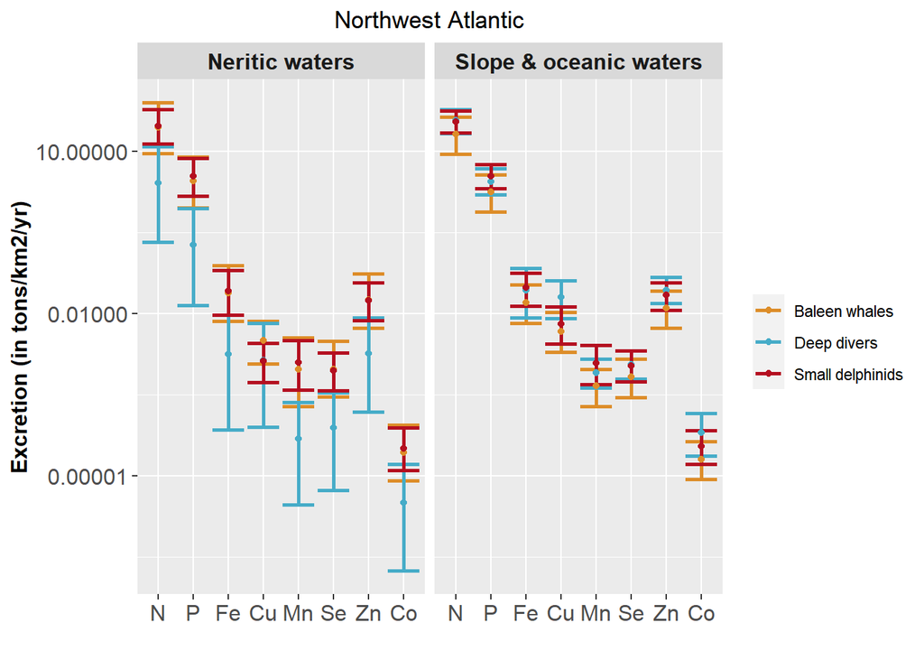

Are the differences significant ?

| Geo_area | Eco_area | Element | Group1 | Group2 | ratio_group1_superior_to_group2 |
| --- | --- | --- | --- | --- | --- |
| Northwest Atlantic | oceanic | N | Baleen whales | Deep divers | 0.109 |
| Northwest Atlantic | oceanic | N | Baleen whales | Small delphinids | 0.126 |
| Northwest Atlantic | oceanic | N | Deep divers | Small delphinids | 0.569 |
| Northwest Atlantic | shelf | N | Baleen whales | Deep divers | 0.995 |
| Northwest Atlantic | shelf | N | Baleen whales | Small delphinids | 0.402 |
| Northwest Atlantic | shelf | N | Deep divers | Small delphinids | 0.003 |
| Northwest Atlantic | oceanic | P | Baleen whales | Deep divers | 0.153 |
| Northwest Atlantic | oceanic | P | Baleen whales | Small delphinids | 0.071 |
| Northwest Atlantic | oceanic | P | Deep divers | Small delphinids | 0.261 |
| Northwest Atlantic | shelf | P | Baleen whales | Deep divers | 0.997 |
| Northwest Atlantic | shelf | P | Baleen whales | Small delphinids | 0.308 |
| Northwest Atlantic | shelf | P | Deep divers | Small delphinids | 0.001 |
| Northwest Atlantic | oceanic | Fe | Baleen whales | Deep divers | 0.291 |
| Northwest Atlantic | oceanic | Fe | Baleen whales | Small delphinids | 0.115 |
| Northwest Atlantic | oceanic | Fe | Deep divers | Small delphinids | 0.343 |
| Northwest Atlantic | shelf | Fe | Baleen whales | Deep divers | 0.993 |
| Northwest Atlantic | shelf | Fe | Baleen whales | Small delphinids | 0.391 |
| Northwest Atlantic | shelf | Fe | Deep divers | Small delphinids | 0.005 |
| Northwest Atlantic | oceanic | Cu | Baleen whales | Deep divers | 0.006 |
| Northwest Atlantic | oceanic | Cu | Baleen whales | Small delphinids | 0.311 |
| Northwest Atlantic | oceanic | Cu | Deep divers | Small delphinids | 0.999 |
| Northwest Atlantic | shelf | Cu | Baleen whales | Deep divers | 0.850 |
| Northwest Atlantic | shelf | Cu | Baleen whales | Small delphinids | 0.924 |
| Northwest Atlantic | shelf | Cu | Deep divers | Small delphinids | 0.345 |
| Northwest Atlantic | oceanic | Mn | Baleen whales | Deep divers | 0.138 |
| Northwest Atlantic | oceanic | Mn | Baleen whales | Small delphinids | 0.056 |
| Northwest Atlantic | oceanic | Mn | Deep divers | Small delphinids | 0.231 |
| Northwest Atlantic | shelf | Mn | Baleen whales | Deep divers | 0.993 |
| Northwest Atlantic | shelf | Mn | Baleen whales | Small delphinids | 0.249 |
| Northwest Atlantic | shelf | Mn | Deep divers | Small delphinids | 0.002 |
| Northwest Atlantic | oceanic | Se | Baleen whales | Deep divers | 0.145 |
| Northwest Atlantic | oceanic | Se | Baleen whales | Small delphinids | 0.173 |
| Northwest Atlantic | oceanic | Se | Deep divers | Small delphinids | 0.558 |
| Northwest Atlantic | shelf | Se | Baleen whales | Deep divers | 0.994 |
| Northwest Atlantic | shelf | Se | Baleen whales | Small delphinids | 0.448 |
| Northwest Atlantic | shelf | Se | Deep divers | Small delphinids | 0.003 |
| Northwest Atlantic | oceanic | Zn | Baleen whales | Deep divers | 0.050 |
| Northwest Atlantic | oceanic | Zn | Baleen whales | Small delphinids | 0.131 |
| Northwest Atlantic | oceanic | Zn | Deep divers | Small delphinids | 0.708 |
| Northwest Atlantic | shelf | Zn | Baleen whales | Deep divers | 0.989 |
| Northwest Atlantic | shelf | Zn | Baleen whales | Small delphinids | 0.439 |
| Northwest Atlantic | shelf | Zn | Deep divers | Small delphinids | 0.004 |
| Northwest Atlantic | oceanic | Co | Baleen whales | Deep divers | 0.035 |
| Northwest Atlantic | oceanic | Co | Baleen whales | Small delphinids | 0.146 |
| Northwest Atlantic | oceanic | Co | Deep divers | Small delphinids | 0.833 |
| Northwest Atlantic | shelf | Co | Baleen whales | Deep divers | 0.978 |
| Northwest Atlantic | shelf | Co | Baleen whales | Small delphinids | 0.314 |
| Northwest Atlantic | shelf | Co | Deep divers | Small delphinids | 0.009 |

What is the relative contribution to total excretion in each habitat ?

| Geo_area | Eco_area | Eco_gp | Element | mean | mean_total | ratio_contribution |
| --- | --- | --- | --- | --- | --- | --- |
| Northwest Atlantic | oceanic | Baleen whales | N | 5338.4761481 | 23731.8410058 | 0.2249499 |
| Northwest Atlantic | oceanic | Baleen whales | P | 454.3886718 | 2037.9928409 | 0.2229589 |
| Northwest Atlantic | oceanic | Baleen whales | Fe | 4.1224183 | 18.7971366 | 0.2193110 |
| Northwest Atlantic | oceanic | Baleen whales | Cu | 1.1994467 | 7.8978081 | 0.1518708 |
| Northwest Atlantic | oceanic | Baleen whales | Mn | 0.1180490 | 0.6328805 | 0.1865266 |
| Northwest Atlantic | oceanic | Baleen whales | Se | 0.1711073 | 0.7347249 | 0.2328863 |
| Northwest Atlantic | oceanic | Baleen whales | Zn | 3.2350118 | 15.7453413 | 0.2054583 |
| Northwest Atlantic | oceanic | Baleen whales | Co | 0.0051719 | 0.0303429 | 0.1704480 |
| Northwest Atlantic | oceanic | Baleen whales | As | 1.4188238 | 5.6361625 | 0.2517358 |
| Northwest Atlantic | oceanic | Deep divers | N | 9430.5172175 | 23731.8410058 | 0.3973782 |
| Northwest Atlantic | oceanic | Deep divers | P | 697.8316851 | 2037.9928409 | 0.3424113 |
| Northwest Atlantic | oceanic | Deep divers | Fe | 6.8392172 | 18.7971366 | 0.3638436 |
| Northwest Atlantic | oceanic | Deep divers | Cu | 5.0682339 | 7.8978081 | 0.6417267 |
| Northwest Atlantic | oceanic | Deep divers | Mn | 0.2039883 | 0.6328805 | 0.3223172 |
| Northwest Atlantic | oceanic | Deep divers | Se | 0.2897260 | 0.7347249 | 0.3943327 |
| Northwest Atlantic | oceanic | Deep divers | Zn | 6.9392127 | 15.7453413 | 0.4407153 |
| Northwest Atlantic | oceanic | Deep divers | Co | 0.0161111 | 0.0303429 | 0.5309665 |
| Northwest Atlantic | oceanic | Deep divers | As | 2.4830208 | 5.6361625 | 0.4405517 |
| Northwest Atlantic | oceanic | Small delphinids | N | 8962.8476402 | 23731.8410058 | 0.3776718 |
| Northwest Atlantic | oceanic | Small delphinids | P | 885.7724841 | 2037.9928409 | 0.4346298 |
| Northwest Atlantic | oceanic | Small delphinids | Fe | 7.8355011 | 18.7971366 | 0.4168455 |
| Northwest Atlantic | oceanic | Small delphinids | Cu | 1.6301274 | 7.8978081 | 0.2064025 |
| Northwest Atlantic | oceanic | Small delphinids | Mn | 0.3108432 | 0.6328805 | 0.4911562 |
| Northwest Atlantic | oceanic | Small delphinids | Se | 0.2738915 | 0.7347249 | 0.3727811 |
| Northwest Atlantic | oceanic | Small delphinids | Zn | 5.5711167 | 15.7453413 | 0.3538264 |
| Northwest Atlantic | oceanic | Small delphinids | Co | 0.0090600 | 0.0303429 | 0.2985855 |
| Northwest Atlantic | oceanic | Small delphinids | As | 1.7343179 | 5.6361625 | 0.3077125 |
| Northwest Atlantic | shelf | Baleen whales | N | 5691.5105231 | 12139.7319110 | 0.4688333 |
| Northwest Atlantic | shelf | Baleen whales | P | 567.7512389 | 1309.9407194 | 0.4334175 |
| Northwest Atlantic | shelf | Baleen whales | Fe | 4.8788941 | 10.5782737 | 0.4612184 |
| Northwest Atlantic | shelf | Baleen whales | Cu | 0.6358515 | 1.1767283 | 0.5403554 |
| Northwest Atlantic | shelf | Baleen whales | Mn | 0.1858571 | 0.4494536 | 0.4135179 |
| Northwest Atlantic | shelf | Baleen whales | Se | 0.1883729 | 0.3817421 | 0.4934558 |
| Northwest Atlantic | shelf | Baleen whales | Zn | 3.6247496 | 7.5371564 | 0.4809174 |
| Northwest Atlantic | shelf | Baleen whales | Co | 0.0055193 | 0.0127060 | 0.4343895 |
| Northwest Atlantic | shelf | Baleen whales | As | 0.9895027 | 2.6055696 | 0.3797644 |
| Northwest Atlantic | shelf | Deep divers | N | 531.5435396 | 12139.7319110 | 0.0437854 |
| Northwest Atlantic | shelf | Deep divers | P | 38.0357636 | 1309.9407194 | 0.0290362 |
| Northwest Atlantic | shelf | Deep divers | Fe | 0.3535544 | 10.5782737 | 0.0334227 |
| Northwest Atlantic | shelf | Deep divers | Cu | 0.2724661 | 1.1767283 | 0.2315455 |
| Northwest Atlantic | shelf | Deep divers | Mn | 0.0097294 | 0.4494536 | 0.0216471 |
| Northwest Atlantic | shelf | Deep divers | Se | 0.0155979 | 0.3817421 | 0.0408598 |
| Northwest Atlantic | shelf | Deep divers | Zn | 0.3698002 | 7.5371564 | 0.0490636 |
| Northwest Atlantic | shelf | Deep divers | Co | 0.0006501 | 0.0127060 | 0.0511647 |
| Northwest Atlantic | shelf | Deep divers | As | 0.1198436 | 2.6055696 | 0.0459952 |
| Northwest Atlantic | shelf | Small delphinids | N | 5916.6778483 | 12139.7319110 | 0.4873813 |
| Northwest Atlantic | shelf | Small delphinids | P | 704.1537169 | 1309.9407194 | 0.5375462 |
| Northwest Atlantic | shelf | Small delphinids | Fe | 5.3458252 | 10.5782737 | 0.5053589 |
| Northwest Atlantic | shelf | Small delphinids | Cu | 0.2684106 | 1.1767283 | 0.2280991 |
| Northwest Atlantic | shelf | Small delphinids | Mn | 0.2538671 | 0.4494536 | 0.5648349 |
| Northwest Atlantic | shelf | Small delphinids | Se | 0.1777714 | 0.3817421 | 0.4656845 |
| Northwest Atlantic | shelf | Small delphinids | Zn | 3.5426066 | 7.5371564 | 0.4700190 |
| Northwest Atlantic | shelf | Small delphinids | Co | 0.0065365 | 0.0127060 | 0.5144457 |
| Northwest Atlantic | shelf | Small delphinids | As | 1.4962233 | 2.6055696 | 0.5742404 |

# Mediterranean Sea

## Excretion in neritic and oceanic waters

In absolute value, is there more excretion in an habitat than in the other ?

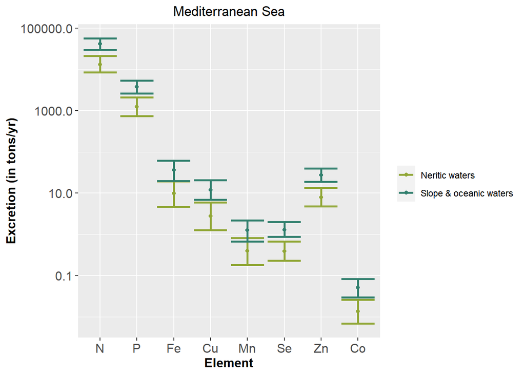

The full results being:

| Geo_area | Eco_area | Element | min | 2.5_quant | mean | median | 97.5_quant | max |
| --- | --- | --- | --- | --- | --- | --- | --- | --- |
| Mediterranean Sea | oceanic | N | 25045.6842995 | 29947.4459421 | 41432.5604290 | 40744.2609182 | 56217.0532879 | 66694.8998918 |
| Mediterranean Sea | oceanic | P | 2204.8820293 | 2604.6284952 | 3740.2113495 | 3650.9425889 | 5363.3107266 | 6119.0953638 |
| Mediterranean Sea | oceanic | Fe | 13.9833809 | 19.7615442 | 36.3865567 | 35.1574272 | 60.8996753 | 77.7560136 |
| Mediterranean Sea | oceanic | Cu | 5.1410650 | 6.8393938 | 11.9761387 | 11.1203642 | 20.5363337 | 25.8893783 |
| Mediterranean Sea | oceanic | Mn | 0.5354386 | 0.6647095 | 1.2490869 | 1.1794943 | 2.1688217 | 2.8553470 |
| Mediterranean Sea | oceanic | Se | 0.6899262 | 0.8758632 | 1.2947772 | 1.2512310 | 1.9753205 | 2.5920332 |
| Mediterranean Sea | oceanic | Zn | 14.4312913 | 18.9601220 | 27.4155912 | 26.8548735 | 39.4631713 | 52.8825995 |
| Mediterranean Sea | oceanic | Co | 0.0226480 | 0.0293724 | 0.0507249 | 0.0480679 | 0.0823745 | 0.1148037 |
| Mediterranean Sea | oceanic | As | 4.3408746 | 6.2250917 | 9.3642020 | 9.1537300 | 14.1391530 | 20.2425075 |
| Mediterranean Sea | shelf | N | 6352.0355060 | 8425.1177522 | 13087.4269390 | 12554.6227960 | 21157.9668788 | 32331.5158868 |
| Mediterranean Sea | shelf | P | 490.8612574 | 736.9243983 | 1245.1582659 | 1182.1562768 | 2080.8581964 | 3439.8007238 |
| Mediterranean Sea | shelf | Fe | 3.0250033 | 4.7093103 | 9.8641117 | 9.0453581 | 19.0819056 | 25.3151187 |
| Mediterranean Sea | shelf | Cu | 0.8228330 | 1.2490976 | 2.7693015 | 2.4569921 | 5.8810623 | 15.6690190 |
| Mediterranean Sea | shelf | Mn | 0.1187236 | 0.1827740 | 0.3995555 | 0.3663786 | 0.8175333 | 1.3110290 |
| Mediterranean Sea | shelf | Se | 0.1714168 | 0.2281985 | 0.3862482 | 0.3654466 | 0.6737419 | 1.2225025 |
| Mediterranean Sea | shelf | Zn | 3.5057417 | 4.7235971 | 7.8475465 | 7.4511621 | 13.1981739 | 19.6107141 |
| Mediterranean Sea | shelf | Co | 0.0045223 | 0.0068748 | 0.0135781 | 0.0128313 | 0.0260606 | 0.0349413 |
| Mediterranean Sea | shelf | As | 0.9981726 | 1.4532066 | 3.2238470 | 2.8799291 | 6.5874344 | 9.1064213 |

And per unit area, so considering the respective size of each of the habitat ?

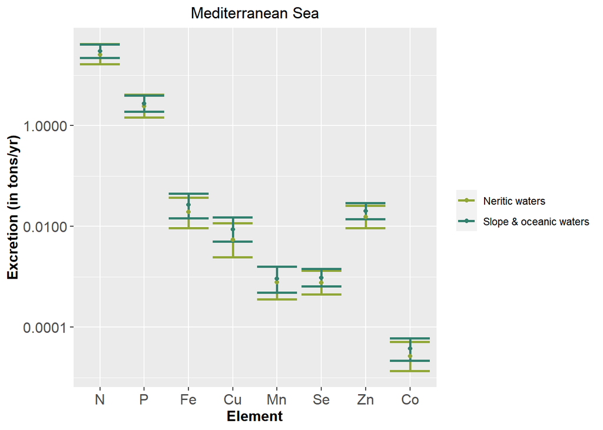

The details being:

| Geo_area | Eco_area | Element | min | 2.5_quant | mean | median | 97.5_quant | max |
| --- | --- | --- | --- | --- | --- | --- | --- | --- |
| Mediterranean Sea | oceanic | N | 18.4015614 | 22.0029829 | 30.4413245 | 29.9356172 | 41.3037848 | 49.0020667 |
| Mediterranean Sea | oceanic | P | 1.6199706 | 1.9136723 | 2.7480075 | 2.6824200 | 3.9405308 | 4.4958208 |
| Mediterranean Sea | oceanic | Fe | 0.0102739 | 0.0145192 | 0.0267339 | 0.0258309 | 0.0447442 | 0.0571289 |
| Mediterranean Sea | oceanic | Cu | 0.0037772 | 0.0050250 | 0.0087991 | 0.0081704 | 0.0150885 | 0.0190214 |
| Mediterranean Sea | oceanic | Mn | 0.0003934 | 0.0004884 | 0.0009177 | 0.0008666 | 0.0015935 | 0.0020979 |
| Mediterranean Sea | oceanic | Se | 0.0005069 | 0.0006435 | 0.0009513 | 0.0009193 | 0.0014513 | 0.0019044 |
| Mediterranean Sea | oceanic | Zn | 0.0106030 | 0.0139304 | 0.0201428 | 0.0197308 | 0.0289944 | 0.0388539 |
| Mediterranean Sea | oceanic | Co | 0.0000166 | 0.0000216 | 0.0000373 | 0.0000353 | 0.0000605 | 0.0000843 |
| Mediterranean Sea | oceanic | As | 0.0031893 | 0.0045737 | 0.0068801 | 0.0067254 | 0.0103883 | 0.0148726 |
| Mediterranean Sea | shelf | N | 12.5048685 | 16.5860202 | 25.7644266 | 24.7155272 | 41.6524109 | 63.6491016 |
| Mediterranean Sea | shelf | P | 0.9663289 | 1.4507385 | 2.4512678 | 2.3272396 | 4.0964598 | 6.7717278 |
| Mediterranean Sea | shelf | Fe | 0.0059551 | 0.0092709 | 0.0194189 | 0.0178070 | 0.0375654 | 0.0498363 |
| Mediterranean Sea | shelf | Cu | 0.0016199 | 0.0024590 | 0.0054518 | 0.0048369 | 0.0115777 | 0.0308467 |
| Mediterranean Sea | shelf | Mn | 0.0002337 | 0.0003598 | 0.0007866 | 0.0007213 | 0.0016094 | 0.0025809 |
| Mediterranean Sea | shelf | Se | 0.0003375 | 0.0004492 | 0.0007604 | 0.0007194 | 0.0013264 | 0.0024067 |
| Mediterranean Sea | shelf | Zn | 0.0069015 | 0.0092991 | 0.0154490 | 0.0146687 | 0.0259824 | 0.0386064 |
| Mediterranean Sea | shelf | Co | 0.0000089 | 0.0000135 | 0.0000267 | 0.0000253 | 0.0000513 | 0.0000688 |
| Mediterranean Sea | shelf | As | 0.0019650 | 0.0028608 | 0.0063466 | 0.0056695 | 0.0129683 | 0.0179273 |

Are the differences between the two areas significant ? (per surface unit)

| Geo_area | Element | Area1 | Area2 | ratio_area1_superior_to_area2 |
| --- | --- | --- | --- | --- |
| Mediterranean Sea | N | Neritic waters | Oceanic waters | 0.247 |
| Mediterranean Sea | N | Oceanic waters | Neritic waters | 0.753 |
| Mediterranean Sea | P | Neritic waters | Oceanic waters | 0.309 |
| Mediterranean Sea | P | Oceanic waters | Neritic waters | 0.691 |
| Mediterranean Sea | Fe | Neritic waters | Oceanic waters | 0.123 |
| Mediterranean Sea | Fe | Oceanic waters | Neritic waters | 0.877 |
| Mediterranean Sea | Cu | Neritic waters | Oceanic waters | 0.049 |
| Mediterranean Sea | Cu | Oceanic waters | Neritic waters | 0.951 |
| Mediterranean Sea | Mn | Neritic waters | Oceanic waters | 0.288 |
| Mediterranean Sea | Mn | Oceanic waters | Neritic waters | 0.712 |
| Mediterranean Sea | Se | Neritic waters | Oceanic waters | 0.174 |
| Mediterranean Sea | Se | Oceanic waters | Neritic waters | 0.826 |
| Mediterranean Sea | Zn | Neritic waters | Oceanic waters | 0.146 |
| Mediterranean Sea | Zn | Oceanic waters | Neritic waters | 0.854 |
| Mediterranean Sea | Co | Neritic waters | Oceanic waters | 0.108 |
| Mediterranean Sea | Co | Oceanic waters | Neritic waters | 0.892 |

## Excretion per taxa

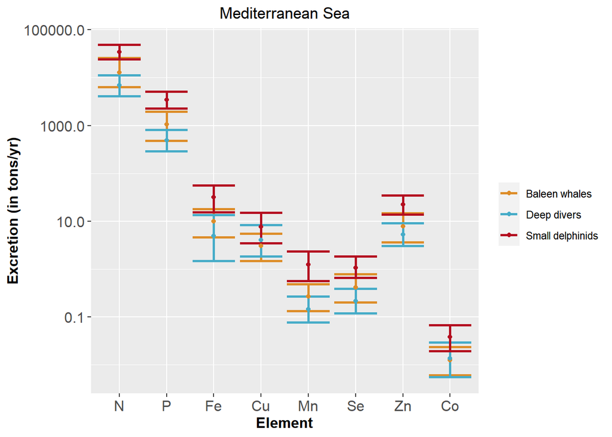

Are the differences significant ?

| Geo_area | Element | Group1 | Group2 | ratio_group1_superior_to_group2 |
| --- | --- | --- | --- | --- |
| Mediterranean Sea | N | Baleen whales | Deep divers | 0.912 |
| Mediterranean Sea | N | Baleen whales | Small delphinids | 0.003 |
| Mediterranean Sea | N | Deep divers | Small delphinids | 0.000 |
| Mediterranean Sea | P | Baleen whales | Deep divers | 0.951 |
| Mediterranean Sea | P | Baleen whales | Small delphinids | 0.002 |
| Mediterranean Sea | P | Deep divers | Small delphinids | 0.000 |
| Mediterranean Sea | Fe | Baleen whales | Deep divers | 0.879 |
| Mediterranean Sea | Fe | Baleen whales | Small delphinids | 0.010 |
| Mediterranean Sea | Fe | Deep divers | Small delphinids | 0.000 |
| Mediterranean Sea | Cu | Baleen whales | Deep divers | 0.333 |
| Mediterranean Sea | Cu | Baleen whales | Small delphinids | 0.051 |
| Mediterranean Sea | Cu | Deep divers | Small delphinids | 0.015 |
| Mediterranean Sea | Mn | Baleen whales | Deep divers | 0.909 |
| Mediterranean Sea | Mn | Baleen whales | Small delphinids | 0.000 |
| Mediterranean Sea | Mn | Deep divers | Small delphinids | 0.000 |
| Mediterranean Sea | Se | Baleen whales | Deep divers | 0.921 |
| Mediterranean Sea | Se | Baleen whales | Small delphinids | 0.011 |
| Mediterranean Sea | Se | Deep divers | Small delphinids | 0.000 |
| Mediterranean Sea | Zn | Baleen whales | Deep divers | 0.815 |
| Mediterranean Sea | Zn | Baleen whales | Small delphinids | 0.004 |
| Mediterranean Sea | Zn | Deep divers | Small delphinids | 0.001 |
| Mediterranean Sea | Co | Baleen whales | Deep divers | 0.486 |
| Mediterranean Sea | Co | Baleen whales | Small delphinids | 0.012 |
| Mediterranean Sea | Co | Deep divers | Small delphinids | 0.010 |

What are their relative contribution to total excretion in this area ?

| Geo_area | Eco_gp | Element | mean | mean_total | ratio_contribution |
| --- | --- | --- | --- | --- | --- |
| Mediterranean Sea | Baleen whales | N | 12966.7131489 | 54519.987368 | 0.2378341 |
| Mediterranean Sea | Baleen whales | P | 1068.0340834 | 4985.369615 | 0.2142337 |
| Mediterranean Sea | Baleen whales | Fe | 9.8501159 | 46.250668 | 0.2129724 |
| Mediterranean Sea | Baleen whales | Cu | 3.0630521 | 14.745440 | 0.2077288 |
| Mediterranean Sea | Baleen whales | Mn | 0.2698475 | 1.648642 | 0.1636786 |
| Mediterranean Sea | Baleen whales | Se | 0.4133670 | 1.681025 | 0.2459017 |
| Mediterranean Sea | Baleen whales | Zn | 7.8142476 | 35.263138 | 0.2215982 |
| Mediterranean Sea | Baleen whales | Co | 0.0125830 | 0.064303 | 0.1956831 |
| Mediterranean Sea | Baleen whales | As | 3.5927518 | 12.588049 | 0.2854097 |
| Mediterranean Sea | Deep divers | N | 6903.3860753 | 54519.987368 | 0.1266212 |
| Mediterranean Sea | Deep divers | P | 495.1323291 | 4985.369615 | 0.0993171 |
| Mediterranean Sea | Deep divers | Fe | 4.8891434 | 46.250668 | 0.1057097 |
| Mediterranean Sea | Deep divers | Cu | 4.0273757 | 14.745440 | 0.2731269 |
| Mediterranean Sea | Deep divers | Mn | 0.1458881 | 1.648642 | 0.0884899 |
| Mediterranean Sea | Deep divers | Se | 0.2151054 | 1.681025 | 0.1279608 |
| Mediterranean Sea | Deep divers | Zn | 5.2587579 | 35.263138 | 0.1491290 |
| Mediterranean Sea | Deep divers | Co | 0.0136703 | 0.064303 | 0.2125922 |
| Mediterranean Sea | Deep divers | As | 1.9268060 | 12.588049 | 0.1530663 |
| Mediterranean Sea | Small delphinids | N | 34649.8881438 | 54519.987368 | 0.6355447 |
| Mediterranean Sea | Small delphinids | P | 3422.2032028 | 4985.369615 | 0.6864492 |
| Mediterranean Sea | Small delphinids | Fe | 31.5114091 | 46.250668 | 0.6813179 |
| Mediterranean Sea | Small delphinids | Cu | 7.6550123 | 14.745440 | 0.5191444 |
| Mediterranean Sea | Small delphinids | Mn | 1.2329068 | 1.648642 | 0.7478315 |
| Mediterranean Sea | Small delphinids | Se | 1.0525530 | 1.681025 | 0.6261375 |
| Mediterranean Sea | Small delphinids | Zn | 22.1901322 | 35.263138 | 0.6292728 |
| Mediterranean Sea | Small delphinids | Co | 0.0380497 | 0.064303 | 0.5917247 |
| Mediterranean Sea | Small delphinids | As | 7.0684912 | 12.588049 | 0.5615240 |

## Excretion per taxa and per habitat

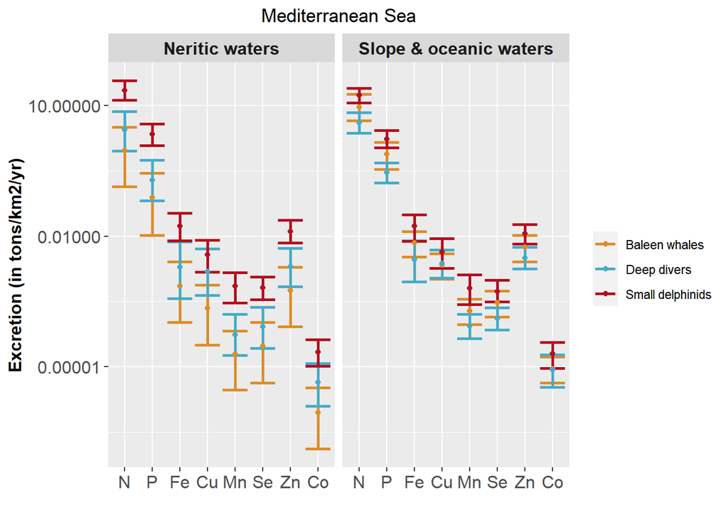

Are the differences significant ?

| Geo_area | Eco_area | Element | Group1 | Group2 | ratio_group1_superior_to_group2 |
| --- | --- | --- | --- | --- | --- |
| Mediterranean Sea | oceanic | N | Baleen whales | Deep divers | 0.961 |
| Mediterranean Sea | oceanic | N | Baleen whales | Small delphinids | 0.056 |
| Mediterranean Sea | oceanic | N | Deep divers | Small delphinids | 0.000 |
| Mediterranean Sea | shelf | N | Baleen whales | Deep divers | 0.100 |
| Mediterranean Sea | shelf | N | Baleen whales | Small delphinids | 0.000 |
| Mediterranean Sea | shelf | N | Deep divers | Small delphinids | 0.002 |
| Mediterranean Sea | oceanic | P | Baleen whales | Deep divers | 0.982 |
| Mediterranean Sea | oceanic | P | Baleen whales | Small delphinids | 0.017 |
| Mediterranean Sea | oceanic | P | Deep divers | Small delphinids | 0.000 |
| Mediterranean Sea | shelf | P | Baleen whales | Deep divers | 0.126 |
| Mediterranean Sea | shelf | P | Baleen whales | Small delphinids | 0.000 |
| Mediterranean Sea | shelf | P | Deep divers | Small delphinids | 0.000 |
| Mediterranean Sea | oceanic | Fe | Baleen whales | Deep divers | 0.926 |
| Mediterranean Sea | oceanic | Fe | Baleen whales | Small delphinids | 0.049 |
| Mediterranean Sea | oceanic | Fe | Deep divers | Small delphinids | 0.000 |
| Mediterranean Sea | shelf | Fe | Baleen whales | Deep divers | 0.191 |
| Mediterranean Sea | shelf | Fe | Baleen whales | Small delphinids | 0.000 |
| Mediterranean Sea | shelf | Fe | Deep divers | Small delphinids | 0.004 |
| Mediterranean Sea | oceanic | Cu | Baleen whales | Deep divers | 0.446 |
| Mediterranean Sea | oceanic | Cu | Baleen whales | Small delphinids | 0.128 |
| Mediterranean Sea | oceanic | Cu | Deep divers | Small delphinids | 0.054 |
| Mediterranean Sea | shelf | Cu | Baleen whales | Deep divers | 0.020 |
| Mediterranean Sea | shelf | Cu | Baleen whales | Small delphinids | 0.000 |
| Mediterranean Sea | shelf | Cu | Deep divers | Small delphinids | 0.078 |
| Mediterranean Sea | oceanic | Mn | Baleen whales | Deep divers | 0.946 |
| Mediterranean Sea | oceanic | Mn | Baleen whales | Small delphinids | 0.011 |
| Mediterranean Sea | oceanic | Mn | Deep divers | Small delphinids | 0.000 |
| Mediterranean Sea | shelf | Mn | Baleen whales | Deep divers | 0.117 |
| Mediterranean Sea | shelf | Mn | Baleen whales | Small delphinids | 0.000 |
| Mediterranean Sea | shelf | Mn | Deep divers | Small delphinids | 0.001 |
| Mediterranean Sea | oceanic | Se | Baleen whales | Deep divers | 0.960 |
| Mediterranean Sea | oceanic | Se | Baleen whales | Small delphinids | 0.087 |
| Mediterranean Sea | oceanic | Se | Deep divers | Small delphinids | 0.000 |
| Mediterranean Sea | shelf | Se | Baleen whales | Deep divers | 0.109 |
| Mediterranean Sea | shelf | Se | Baleen whales | Small delphinids | 0.000 |
| Mediterranean Sea | shelf | Se | Deep divers | Small delphinids | 0.003 |
| Mediterranean Sea | oceanic | Zn | Baleen whales | Deep divers | 0.891 |
| Mediterranean Sea | oceanic | Zn | Baleen whales | Small delphinids | 0.049 |
| Mediterranean Sea | oceanic | Zn | Deep divers | Small delphinids | 0.000 |
| Mediterranean Sea | shelf | Zn | Baleen whales | Deep divers | 0.067 |
| Mediterranean Sea | shelf | Zn | Baleen whales | Small delphinids | 0.000 |
| Mediterranean Sea | shelf | Zn | Deep divers | Small delphinids | 0.004 |
| Mediterranean Sea | oceanic | Co | Baleen whales | Deep divers | 0.564 |
| Mediterranean Sea | oceanic | Co | Baleen whales | Small delphinids | 0.067 |
| Mediterranean Sea | oceanic | Co | Deep divers | Small delphinids | 0.038 |
| Mediterranean Sea | shelf | Co | Baleen whales | Deep divers | 0.039 |
| Mediterranean Sea | shelf | Co | Baleen whales | Small delphinids | 0.000 |
| Mediterranean Sea | shelf | Co | Deep divers | Small delphinids | 0.005 |

What is the relative contribution to total excretion in each habitat ?

| Geo_area | Eco_area | Eco_gp | Element | mean | mean_total | ratio_contribution |
| --- | --- | --- | --- | --- | --- | --- |
| Mediterranean Sea | oceanic | Baleen whales | N | 12500.1145513 | 41432.5604290 | 0.3016979 |
| Mediterranean Sea | oceanic | Baleen whales | P | 1028.7973373 | 3740.2113495 | 0.2750640 |
| Mediterranean Sea | oceanic | Baleen whales | Fe | 9.4881375 | 36.3865567 | 0.2607594 |
| Mediterranean Sea | oceanic | Baleen whales | Cu | 2.9512651 | 11.9761387 | 0.2464288 |
| Mediterranean Sea | oceanic | Baleen whales | Mn | 0.2600250 | 1.2490869 | 0.2081720 |
| Mediterranean Sea | oceanic | Baleen whales | Se | 0.3983103 | 1.2947772 | 0.3076285 |
| Mediterranean Sea | oceanic | Baleen whales | Zn | 7.5294534 | 27.4155912 | 0.2746413 |
| Mediterranean Sea | oceanic | Baleen whales | Co | 0.0121295 | 0.0507249 | 0.2391225 |
| Mediterranean Sea | oceanic | Baleen whales | As | 3.4611404 | 9.3642020 | 0.3696140 |
| Mediterranean Sea | oceanic | Deep divers | N | 5513.3551044 | 41432.5604290 | 0.1330682 |
| Mediterranean Sea | oceanic | Deep divers | P | 396.1123002 | 3740.2113495 | 0.1059064 |
| Mediterranean Sea | oceanic | Deep divers | Fe | 3.9188347 | 36.3865567 | 0.1077001 |
| Mediterranean Sea | oceanic | Deep divers | Cu | 3.2418159 | 11.9761387 | 0.2706896 |
| Mediterranean Sea | oceanic | Deep divers | Mn | 0.1182498 | 1.2490869 | 0.0946690 |
| Mediterranean Sea | oceanic | Deep divers | Se | 0.1727655 | 1.2947772 | 0.1334326 |
| Mediterranean Sea | oceanic | Deep divers | Zn | 4.2466850 | 27.4155912 | 0.1549004 |
| Mediterranean Sea | oceanic | Deep divers | Co | 0.0114276 | 0.0507249 | 0.2252855 |
| Mediterranean Sea | oceanic | Deep divers | As | 1.5705936 | 9.3642020 | 0.1677232 |
| Mediterranean Sea | oceanic | Small delphinids | N | 23419.0907734 | 41432.5604290 | 0.5652340 |
| Mediterranean Sea | oceanic | Small delphinids | P | 2315.3017119 | 3740.2113495 | 0.6190296 |
| Mediterranean Sea | oceanic | Small delphinids | Fe | 22.9795844 | 36.3865567 | 0.6315405 |
| Mediterranean Sea | oceanic | Small delphinids | Cu | 5.7830576 | 11.9761387 | 0.4828817 |
| Mediterranean Sea | oceanic | Small delphinids | Mn | 0.8708122 | 1.2490869 | 0.6971590 |
| Mediterranean Sea | oceanic | Small delphinids | Se | 0.7237014 | 1.2947772 | 0.5589389 |
| Mediterranean Sea | oceanic | Small delphinids | Zn | 15.6394528 | 27.4155912 | 0.5704583 |
| Mediterranean Sea | oceanic | Small delphinids | Co | 0.0271679 | 0.0507249 | 0.5355920 |
| Mediterranean Sea | oceanic | Small delphinids | As | 4.3324681 | 9.3642020 | 0.4626628 |
| Mediterranean Sea | shelf | Baleen whales | N | 466.5985976 | 13087.4269390 | 0.0356524 |
| Mediterranean Sea | shelf | Baleen whales | P | 39.2367461 | 1245.1582659 | 0.0315115 |
| Mediterranean Sea | shelf | Baleen whales | Fe | 0.3619784 | 9.8641117 | 0.0366965 |
| Mediterranean Sea | shelf | Baleen whales | Cu | 0.1117870 | 2.7693015 | 0.0403665 |
| Mediterranean Sea | shelf | Baleen whales | Mn | 0.0098226 | 0.3995555 | 0.0245838 |
| Mediterranean Sea | shelf | Baleen whales | Se | 0.0150567 | 0.3862482 | 0.0389818 |
| Mediterranean Sea | shelf | Baleen whales | Zn | 0.2847943 | 7.8475465 | 0.0362909 |
| Mediterranean Sea | shelf | Baleen whales | Co | 0.0004535 | 0.0135781 | 0.0334028 |
| Mediterranean Sea | shelf | Baleen whales | As | 0.1316115 | 3.2238470 | 0.0408244 |
| Mediterranean Sea | shelf | Deep divers | N | 1390.0309710 | 13087.4269390 | 0.1062112 |
| Mediterranean Sea | shelf | Deep divers | P | 99.0200289 | 1245.1582659 | 0.0795241 |
| Mediterranean Sea | shelf | Deep divers | Fe | 0.9703087 | 9.8641117 | 0.0983676 |
| Mediterranean Sea | shelf | Deep divers | Cu | 0.7855598 | 2.7693015 | 0.2836671 |
| Mediterranean Sea | shelf | Deep divers | Mn | 0.0276384 | 0.3995555 | 0.0691728 |
| Mediterranean Sea | shelf | Deep divers | Se | 0.0423399 | 0.3862482 | 0.1096183 |
| Mediterranean Sea | shelf | Deep divers | Zn | 1.0120729 | 7.8475465 | 0.1289668 |
| Mediterranean Sea | shelf | Deep divers | Co | 0.0022427 | 0.0135781 | 0.1651729 |
| Mediterranean Sea | shelf | Deep divers | As | 0.3562124 | 3.2238470 | 0.1104930 |
| Mediterranean Sea | shelf | Small delphinids | N | 11230.7973704 | 13087.4269390 | 0.8581364 |
| Mediterranean Sea | shelf | Small delphinids | P | 1106.9014909 | 1245.1582659 | 0.8889645 |
| Mediterranean Sea | shelf | Small delphinids | Fe | 8.5318247 | 9.8641117 | 0.8649359 |
| Mediterranean Sea | shelf | Small delphinids | Cu | 1.8719547 | 2.7693015 | 0.6759664 |
| Mediterranean Sea | shelf | Small delphinids | Mn | 0.3620946 | 0.3995555 | 0.9062434 |
| Mediterranean Sea | shelf | Small delphinids | Se | 0.3288516 | 0.3862482 | 0.8513999 |
| Mediterranean Sea | shelf | Small delphinids | Zn | 6.5506794 | 7.8475465 | 0.8347423 |
| Mediterranean Sea | shelf | Small delphinids | Co | 0.0108818 | 0.0135781 | 0.8014244 |
| Mediterranean Sea | shelf | Small delphinids | As | 2.7360231 | 3.2238470 | 0.8486827 |

# West Indian Ocean

## Excretion in neritic and oceanic waters

In absolute value, is there more excretion in an habitat than in the other ?

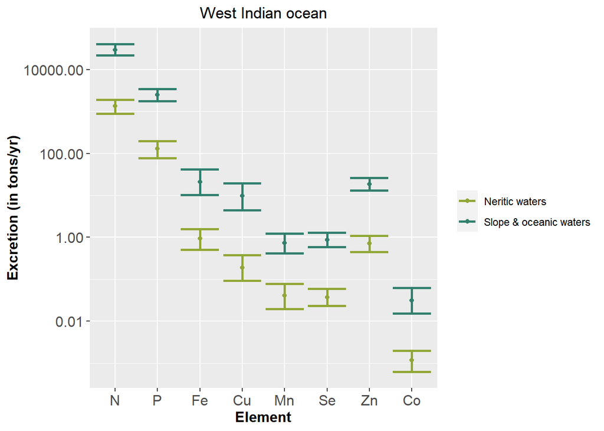

The full results being:

| Geo_area | Eco_area | Element | min | 2.5_quant | mean | median | 97.5_quant | max |
| --- | --- | --- | --- | --- | --- | --- | --- | --- |
| West Indian ocean | oceanic | N | 17175.5470110 | 21837.5124926 | 29313.5524455 | 28690.9809300 | 40273.6389147 | 128617.1491618 |
| West Indian ocean | oceanic | P | 1549.7929588 | 1750.3325175 | 2478.9364368 | 2441.8876112 | 3405.3396351 | 14621.6820019 |
| West Indian ocean | oceanic | Fe | 8.1301078 | 10.2884446 | 20.9330186 | 18.8847829 | 41.7430582 | 135.5365247 |
| West Indian ocean | oceanic | Cu | 3.2759797 | 4.4467883 | 9.6530605 | 8.7440120 | 19.4201382 | 37.7312901 |
| West Indian ocean | oceanic | Mn | 0.2933607 | 0.4190297 | 0.7351545 | 0.7068352 | 1.2200578 | 3.2489896 |
| West Indian ocean | oceanic | Se | 0.5068251 | 0.5809116 | 0.8619389 | 0.8310484 | 1.2784523 | 5.0386500 |
| West Indian ocean | oceanic | Zn | 10.2866842 | 13.1570004 | 18.5057920 | 17.9936868 | 26.2049448 | 121.3430619 |
| West Indian ocean | oceanic | Co | 0.0111891 | 0.0151386 | 0.0315973 | 0.0288756 | 0.0627322 | 0.1569630 |
| West Indian ocean | oceanic | As | 2.8350510 | 3.6945128 | 6.8373367 | 6.3601822 | 11.9753229 | 38.7567280 |
| West Indian ocean | shelf | N | 757.2272605 | 893.2796017 | 1347.7130039 | 1322.6824648 | 1920.1799257 | 2570.5387432 |
| West Indian ocean | shelf | P | 59.6784647 | 77.6990689 | 128.4404545 | 126.0315398 | 195.5784538 | 263.2540944 |
| West Indian ocean | shelf | Fe | 0.3861991 | 0.5122157 | 0.9372178 | 0.8999611 | 1.5575610 | 1.9672411 |
| West Indian ocean | shelf | Cu | 0.0679559 | 0.0922718 | 0.1910811 | 0.1738896 | 0.3806596 | 0.6863976 |
| West Indian ocean | shelf | Mn | 0.0104056 | 0.0197358 | 0.0410603 | 0.0385151 | 0.0782459 | 0.1116395 |
| West Indian ocean | shelf | Se | 0.0181299 | 0.0234887 | 0.0373915 | 0.0361545 | 0.0589482 | 0.0979743 |
| West Indian ocean | shelf | Zn | 0.3527132 | 0.4522899 | 0.7177054 | 0.7012604 | 1.0785273 | 1.8018260 |
| West Indian ocean | shelf | Co | 0.0004194 | 0.0006223 | 0.0011729 | 0.0011173 | 0.0019978 | 0.0026181 |
| West Indian ocean | shelf | As | 0.0864923 | 0.1418858 | 0.3637147 | 0.2914856 | 0.9299556 | 1.1378365 |

And per unit area, so considering the respective size of each of the habitat ?

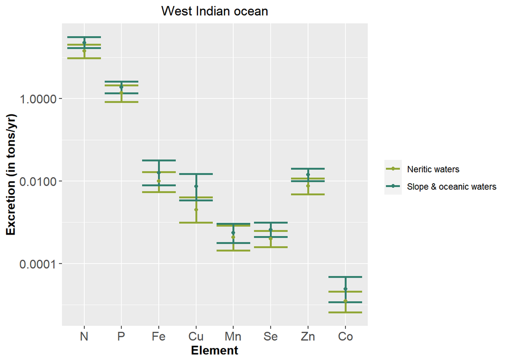

The details being:

| Geo_area | Eco_area | Element | min | 2.5_quant | mean | median | 97.5_quant | max |
| --- | --- | --- | --- | --- | --- | --- | --- | --- |
| West Indian ocean | oceanic | N | 13.1325377 | 16.6971076 | 22.4133375 | 21.9373152 | 30.7934927 | 98.3415293 |
| West Indian ocean | oceanic | P | 1.1849820 | 1.3383159 | 1.8954113 | 1.8670835 | 2.6037454 | 11.1798355 |
| West Indian ocean | oceanic | Fe | 0.0062163 | 0.0078666 | 0.0160055 | 0.0144394 | 0.0319170 | 0.1036321 |
| West Indian ocean | oceanic | Cu | 0.0025048 | 0.0034000 | 0.0073808 | 0.0066857 | 0.0148488 | 0.0288496 |
| West Indian ocean | oceanic | Mn | 0.0002243 | 0.0003204 | 0.0005621 | 0.0005405 | 0.0009329 | 0.0024842 |
| West Indian ocean | oceanic | Se | 0.0003875 | 0.0004442 | 0.0006590 | 0.0006354 | 0.0009775 | 0.0038526 |
| West Indian ocean | oceanic | Zn | 0.0078653 | 0.0100599 | 0.0141497 | 0.0137581 | 0.0200365 | 0.0927797 |
| West Indian ocean | oceanic | Co | 0.0000086 | 0.0000116 | 0.0000242 | 0.0000221 | 0.0000480 | 0.0001200 |
| West Indian ocean | oceanic | As | 0.0021677 | 0.0028248 | 0.0052279 | 0.0048630 | 0.0091564 | 0.0296337 |
| West Indian ocean | shelf | N | 8.0458514 | 9.4914636 | 14.3200056 | 14.0540458 | 20.4027023 | 27.3130325 |
| West Indian ocean | shelf | P | 0.6341083 | 0.8255846 | 1.3647327 | 1.3391370 | 2.0781016 | 2.7971831 |
| West Indian ocean | shelf | Fe | 0.0041035 | 0.0054425 | 0.0099583 | 0.0095625 | 0.0165497 | 0.0209027 |
| West Indian ocean | shelf | Cu | 0.0007221 | 0.0009804 | 0.0020303 | 0.0018476 | 0.0040447 | 0.0072933 |
| West Indian ocean | shelf | Mn | 0.0001106 | 0.0002097 | 0.0004363 | 0.0004092 | 0.0008314 | 0.0011862 |
| West Indian ocean | shelf | Se | 0.0001926 | 0.0002496 | 0.0003973 | 0.0003842 | 0.0006263 | 0.0010410 |
| West Indian ocean | shelf | Zn | 0.0037477 | 0.0048058 | 0.0076259 | 0.0074512 | 0.0114598 | 0.0191451 |
| West Indian ocean | shelf | Co | 0.0000045 | 0.0000066 | 0.0000125 | 0.0000119 | 0.0000212 | 0.0000278 |
| West Indian ocean | shelf | As | 0.0009190 | 0.0015076 | 0.0038646 | 0.0030972 | 0.0098812 | 0.0120900 |

Are the differences between the two areas significant ? (per surface unit)

| Geo_area | Element | Area1 | Area2 | ratio_area1_superior_to_area2 |
| --- | --- | --- | --- | --- |
| West Indian ocean | N | Neritic waters | Oceanic waters | 0.015 |
| West Indian ocean | N | Oceanic waters | Neritic waters | 0.985 |
| West Indian ocean | P | Neritic waters | Oceanic waters | 0.069 |
| West Indian ocean | P | Oceanic waters | Neritic waters | 0.931 |
| West Indian ocean | Fe | Neritic waters | Oceanic waters | 0.073 |
| West Indian ocean | Fe | Oceanic waters | Neritic waters | 0.927 |
| West Indian ocean | Cu | Neritic waters | Oceanic waters | 0.000 |
| West Indian ocean | Cu | Oceanic waters | Neritic waters | 1.000 |
| West Indian ocean | Mn | Neritic waters | Oceanic waters | 0.129 |
| West Indian ocean | Mn | Oceanic waters | Neritic waters | 0.871 |
| West Indian ocean | Se | Neritic waters | Oceanic waters | 0.009 |
| West Indian ocean | Se | Oceanic waters | Neritic waters | 0.991 |
| West Indian ocean | Zn | Neritic waters | Oceanic waters | 0.003 |
| West Indian ocean | Zn | Oceanic waters | Neritic waters | 0.997 |
| West Indian ocean | Co | Neritic waters | Oceanic waters | 0.019 |
| West Indian ocean | Co | Oceanic waters | Neritic waters | 0.981 |

## Excretion per taxa

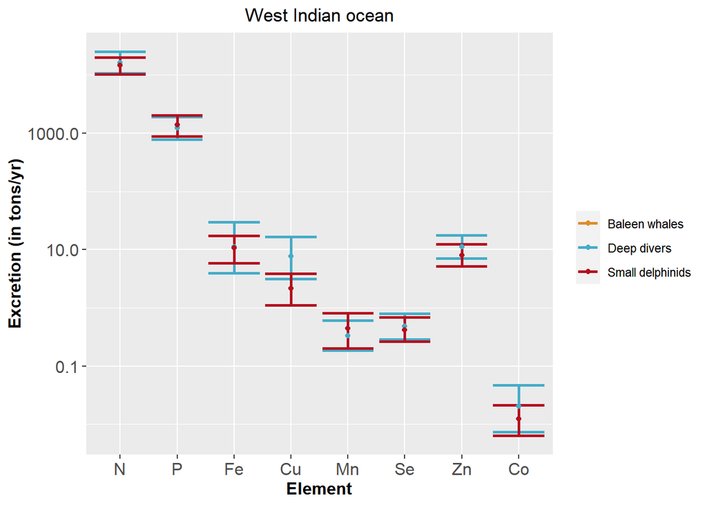

Are the differences significant ?

| Geo_area | Element | Group1 | Group2 | ratio_group1_superior_to_group2 |
| --- | --- | --- | --- | --- |
| West Indian ocean | N | Deep divers | Small delphinids | 0.612 |
| West Indian ocean | P | Deep divers | Small delphinids | 0.313 |
| West Indian ocean | Fe | Deep divers | Small delphinids | 0.430 |
| West Indian ocean | Cu | Deep divers | Small delphinids | 1.000 |
| West Indian ocean | Mn | Deep divers | Small delphinids | 0.260 |
| West Indian ocean | Se | Deep divers | Small delphinids | 0.645 |
| West Indian ocean | Zn | Deep divers | Small delphinids | 0.847 |
| West Indian ocean | Co | Deep divers | Small delphinids | 0.789 |

What are their relative contribution to total excretion in this area ?

| Geo_area | Eco_gp | Element | mean | mean_total | ratio_contribution |
| --- | --- | --- | --- | --- | --- |
| West Indian ocean | Deep divers | N | 16042.0777181 | 30661.2654494 | 0.5232034 |
| West Indian ocean | Deep divers | P | 1222.1539124 | 2607.3768913 | 0.4687293 |
| West Indian ocean | Deep divers | Fe | 11.2616785 | 21.8702364 | 0.5149317 |
| West Indian ocean | Deep divers | Cu | 7.6678404 | 9.8441416 | 0.7789242 |
| West Indian ocean | Deep divers | Mn | 0.3307391 | 0.7762148 | 0.4260922 |
| West Indian ocean | Deep divers | Se | 0.4797671 | 0.8993304 | 0.5334715 |
| West Indian ocean | Deep divers | Zn | 11.1547875 | 19.2234973 | 0.5802684 |
| West Indian ocean | Deep divers | Co | 0.0204165 | 0.0327702 | 0.6230209 |
| West Indian ocean | Deep divers | As | 3.7251960 | 7.2010514 | 0.5173128 |
| West Indian ocean | Small delphinids | N | 14619.1877314 | 30661.2654494 | 0.4767966 |
| West Indian ocean | Small delphinids | P | 1385.2229790 | 2607.3768913 | 0.5312707 |
| West Indian ocean | Small delphinids | Fe | 10.6085578 | 21.8702364 | 0.4850683 |
| West Indian ocean | Small delphinids | Cu | 2.1763012 | 9.8441416 | 0.2210758 |
| West Indian ocean | Small delphinids | Mn | 0.4454758 | 0.7762148 | 0.5739078 |
| West Indian ocean | Small delphinids | Se | 0.4195633 | 0.8993304 | 0.4665285 |
| West Indian ocean | Small delphinids | Zn | 8.0687099 | 19.2234973 | 0.4197316 |
| West Indian ocean | Small delphinids | Co | 0.0123537 | 0.0327702 | 0.3769791 |
| West Indian ocean | Small delphinids | As | 3.4758554 | 7.2010514 | 0.4826872 |

## Excretion per taxa and per habitat

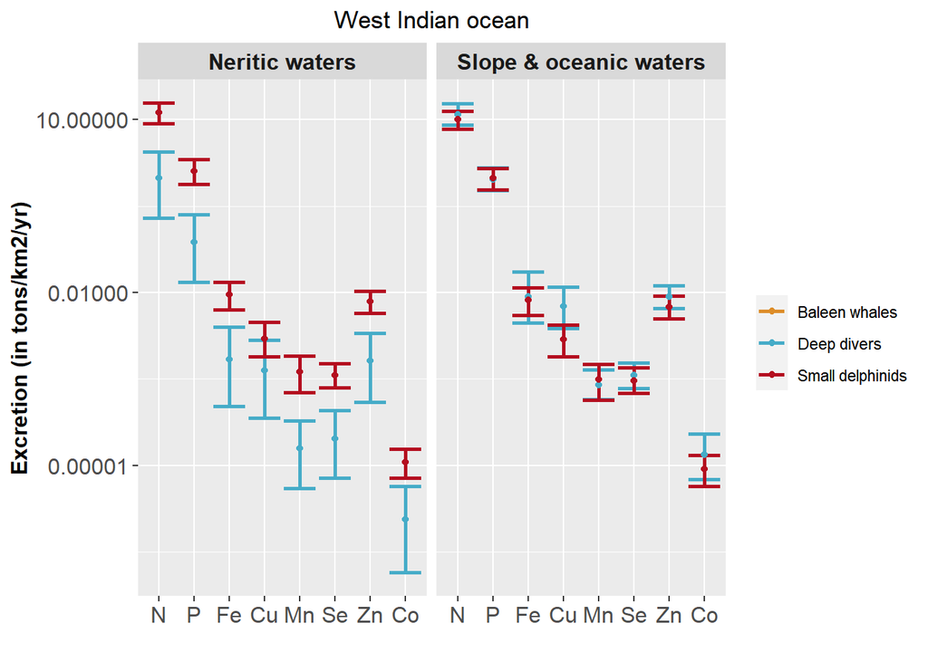

Are the differences significant ?

| Geo_area | Eco_area | Element | Group1 | Group2 | ratio_group1_superior_to_group2 |
| --- | --- | --- | --- | --- | --- |
| West Indian ocean | oceanic | N | Deep divers | Small delphinids | 0.722 |
| West Indian ocean | shelf | N | Deep divers | Small delphinids | 0.000 |
| West Indian ocean | oceanic | P | Deep divers | Small delphinids | 0.423 |
| West Indian ocean | shelf | P | Deep divers | Small delphinids | 0.000 |
| West Indian ocean | oceanic | Fe | Deep divers | Small delphinids | 0.490 |
| West Indian ocean | shelf | Fe | Deep divers | Small delphinids | 0.000 |
| West Indian ocean | oceanic | Cu | Deep divers | Small delphinids | 1.000 |
| West Indian ocean | shelf | Cu | Deep divers | Small delphinids | 0.020 |
| West Indian ocean | oceanic | Mn | Deep divers | Small delphinids | 0.332 |
| West Indian ocean | shelf | Mn | Deep divers | Small delphinids | 0.000 |
| West Indian ocean | oceanic | Se | Deep divers | Small delphinids | 0.715 |
| West Indian ocean | shelf | Se | Deep divers | Small delphinids | 0.000 |
| West Indian ocean | oceanic | Zn | Deep divers | Small delphinids | 0.898 |
| West Indian ocean | shelf | Zn | Deep divers | Small delphinids | 0.000 |
| West Indian ocean | oceanic | Co | Deep divers | Small delphinids | 0.844 |
| West Indian ocean | shelf | Co | Deep divers | Small delphinids | 0.002 |

What is the relative contribution to total excretion in each habitat ?

| Geo_area | Eco_area | Eco_gp | Element | mean | mean_total | ratio_contribution |
| --- | --- | --- | --- | --- | --- | --- |
| West Indian ocean | oceanic | Deep divers | N | 15950.6465825 | 29313.5524455 | 0.5441390 |
| West Indian ocean | oceanic | Deep divers | P | 1215.1316249 | 2478.9364368 | 0.4901826 |
| West Indian ocean | oceanic | Deep divers | Fe | 11.1962161 | 20.9330186 | 0.5348591 |
| West Indian ocean | oceanic | Deep divers | Cu | 7.6260801 | 9.6530605 | 0.7900168 |
| West Indian ocean | oceanic | Deep divers | Mn | 0.3288922 | 0.7351545 | 0.4473784 |
| West Indian ocean | oceanic | Deep divers | Se | 0.4770416 | 0.8619389 | 0.5534517 |
| West Indian ocean | oceanic | Deep divers | Zn | 11.0921895 | 18.5057920 | 0.5993902 |
| West Indian ocean | oceanic | Deep divers | Co | 0.0203081 | 0.0315973 | 0.6427179 |
| West Indian ocean | oceanic | Deep divers | As | 3.7055730 | 6.8373367 | 0.5419615 |
| West Indian ocean | oceanic | Small delphinids | N | 13362.9058630 | 29313.5524455 | 0.4558610 |
| West Indian ocean | oceanic | Small delphinids | P | 1263.8048120 | 2478.9364368 | 0.5098174 |
| West Indian ocean | oceanic | Small delphinids | Fe | 9.7368025 | 20.9330186 | 0.4651409 |
| West Indian ocean | oceanic | Small delphinids | Cu | 2.0269804 | 9.6530605 | 0.2099832 |
| West Indian ocean | oceanic | Small delphinids | Mn | 0.4062623 | 0.7351545 | 0.5526216 |
| West Indian ocean | oceanic | Small delphinids | Se | 0.3848973 | 0.8619389 | 0.4465483 |
| West Indian ocean | oceanic | Small delphinids | Zn | 7.4136025 | 18.5057920 | 0.4006098 |
| West Indian ocean | oceanic | Small delphinids | Co | 0.0112891 | 0.0315973 | 0.3572821 |
| West Indian ocean | oceanic | Small delphinids | As | 3.1317637 | 6.8373367 | 0.4580385 |
| West Indian ocean | shelf | Deep divers | N | 91.4311356 | 1347.7130039 | 0.0678417 |
| West Indian ocean | shelf | Deep divers | P | 7.0222875 | 128.4404545 | 0.0546735 |
| West Indian ocean | shelf | Deep divers | Fe | 0.0654624 | 0.9372178 | 0.0698476 |
| West Indian ocean | shelf | Deep divers | Cu | 0.0417603 | 0.1910811 | 0.2185475 |
| West Indian ocean | shelf | Deep divers | Mn | 0.0018468 | 0.0410603 | 0.0449787 |
| West Indian ocean | shelf | Deep divers | Se | 0.0027256 | 0.0373915 | 0.0728923 |
| West Indian ocean | shelf | Deep divers | Zn | 0.0625980 | 0.7177054 | 0.0872196 |
| West Indian ocean | shelf | Deep divers | Co | 0.0001084 | 0.0011729 | 0.0923928 |
| West Indian ocean | shelf | Deep divers | As | 0.0196230 | 0.3637147 | 0.0539516 |
| West Indian ocean | shelf | Small delphinids | N | 1256.2818684 | 1347.7130039 | 0.9321583 |
| West Indian ocean | shelf | Small delphinids | P | 121.4181670 | 128.4404545 | 0.9453265 |
| West Indian ocean | shelf | Small delphinids | Fe | 0.8717553 | 0.9372178 | 0.9301524 |
| West Indian ocean | shelf | Small delphinids | Cu | 0.1493208 | 0.1910811 | 0.7814525 |
| West Indian ocean | shelf | Small delphinids | Mn | 0.0392135 | 0.0410603 | 0.9550213 |
| West Indian ocean | shelf | Small delphinids | Se | 0.0346659 | 0.0373915 | 0.9271077 |
| West Indian ocean | shelf | Small delphinids | Zn | 0.6551074 | 0.7177054 | 0.9127804 |
| West Indian ocean | shelf | Small delphinids | Co | 0.0010645 | 0.0011729 | 0.9076072 |
| West Indian ocean | shelf | Small delphinids | As | 0.3440917 | 0.3637147 | 0.9460484 |

# French Antilles

## Excretion in neritic and oceanic waters

In absolute value, is there more excretion in an habitat than in the other ?

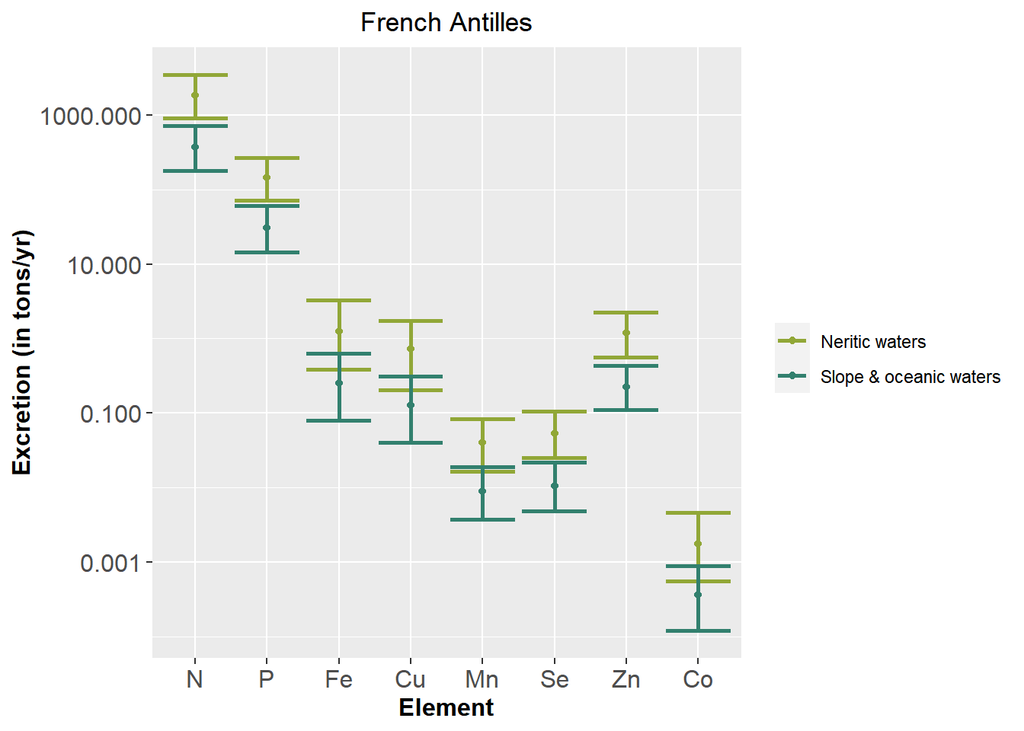

The full results being:

| Geo_area | Eco_area | Element | min | 2.5_quant | mean | median | 97.5_quant | max |
| --- | --- | --- | --- | --- | --- | --- | --- | --- |
| French Antilles | oceanic | N | 130.4436459 | 178.3098372 | 371.7035325 | 352.0585438 | 712.4343968 | 1004.9196212 |
| French Antilles | oceanic | P | 10.5882802 | 14.3080337 | 30.5478183 | 28.7285531 | 61.0965844 | 90.5499400 |
| French Antilles | oceanic | Fe | 0.0500791 | 0.0799061 | 0.2505963 | 0.2174313 | 0.6317010 | 1.2619265 |
| French Antilles | oceanic | Cu | 0.0239336 | 0.0402885 | 0.1265745 | 0.1054748 | 0.3135893 | 0.8230420 |
| French Antilles | oceanic | Mn | 0.0021297 | 0.0037526 | 0.0088712 | 0.0079977 | 0.0191663 | 0.0304899 |
| French Antilles | oceanic | Se | 0.0032480 | 0.0048547 | 0.0105747 | 0.0098670 | 0.0217213 | 0.0312488 |
| French Antilles | oceanic | Zn | 0.0756075 | 0.1112352 | 0.2254264 | 0.2120255 | 0.4336044 | 0.5834379 |
| French Antilles | oceanic | Co | 0.0000744 | 0.0001205 | 0.0003624 | 0.0003152 | 0.0008963 | 0.0019224 |
| French Antilles | oceanic | As | 0.0229774 | 0.0348912 | 0.0909770 | 0.0788722 | 0.2258816 | 0.5516121 |
| French Antilles | shelf | N | 555.6489807 | 914.2759681 | 1821.5807148 | 1709.3149213 | 3451.5229163 | 5991.8962121 |
| French Antilles | shelf | P | 44.6490014 | 71.2531598 | 144.3060013 | 134.1707979 | 266.7197259 | 488.5416932 |
| French Antilles | shelf | Fe | 0.2601462 | 0.3838680 | 1.2546069 | 1.0236345 | 3.3096533 | 5.5040834 |
| French Antilles | shelf | Cu | 0.1242989 | 0.2036455 | 0.7221012 | 0.6104974 | 1.7515564 | 4.9742766 |
| French Antilles | shelf | Mn | 0.0101861 | 0.0164742 | 0.0401665 | 0.0365128 | 0.0826619 | 0.1715072 |
| French Antilles | shelf | Se | 0.0179118 | 0.0249315 | 0.0533377 | 0.0489076 | 0.1044564 | 0.2655667 |
| French Antilles | shelf | Zn | 0.3111514 | 0.5655125 | 1.1831517 | 1.1117139 | 2.2244629 | 4.1375062 |
| French Antilles | shelf | Co | 0.0003517 | 0.0005590 | 0.0017470 | 0.0014164 | 0.0046007 | 0.0076727 |
| French Antilles | shelf | As | 0.1032568 | 0.1585569 | 0.4067417 | 0.3665912 | 0.8672929 | 1.8561300 |

And per unit area, so considering the respective size of each of the habitat ?

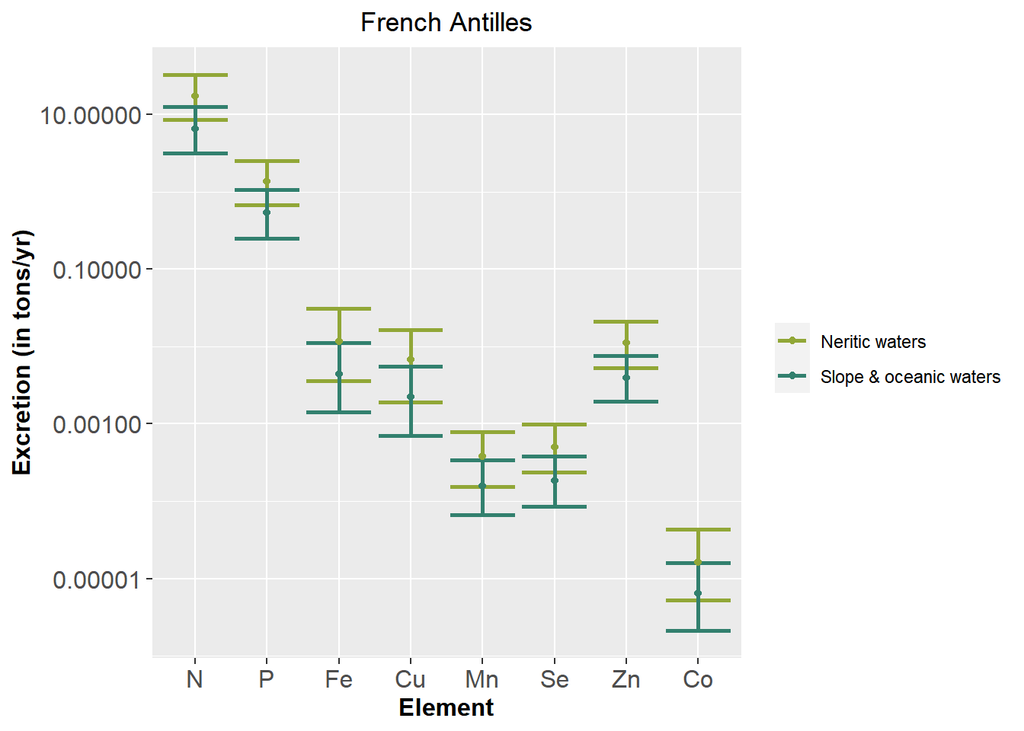

The details being:

| Geo_area | Eco_area | Element | min | 2.5_quant | mean | median | 97.5_quant | max |
| --- | --- | --- | --- | --- | --- | --- | --- | --- |
| French Antilles | oceanic | N | 2.2948865 | 3.1369933 | 6.5393560 | 6.1937430 | 12.5338118 | 17.6794853 |
| French Antilles | oceanic | P | 0.1862789 | 0.2517203 | 0.5374258 | 0.5054196 | 1.0748682 | 1.5930392 |
| French Antilles | oceanic | Fe | 0.0008810 | 0.0014058 | 0.0044087 | 0.0038253 | 0.0111135 | 0.0222010 |
| French Antilles | oceanic | Cu | 0.0004211 | 0.0007088 | 0.0022268 | 0.0018556 | 0.0055170 | 0.0144797 |
| French Antilles | oceanic | Mn | 0.0000375 | 0.0000660 | 0.0001561 | 0.0001407 | 0.0003372 | 0.0005364 |
| French Antilles | oceanic | Se | 0.0000571 | 0.0000854 | 0.0001860 | 0.0001736 | 0.0003821 | 0.0005498 |
| French Antilles | oceanic | Zn | 0.0013302 | 0.0019570 | 0.0039659 | 0.0037302 | 0.0076284 | 0.0102644 |
| French Antilles | oceanic | Co | 0.0000013 | 0.0000021 | 0.0000064 | 0.0000055 | 0.0000158 | 0.0000338 |
| French Antilles | oceanic | As | 0.0004042 | 0.0006138 | 0.0016006 | 0.0013876 | 0.0039739 | 0.0097045 |
| French Antilles | shelf | N | 5.2336273 | 8.6115153 | 17.1573691 | 16.0999437 | 32.5097054 | 56.4373425 |
| French Antilles | shelf | P | 0.4205465 | 0.6711296 | 1.3592103 | 1.2637474 | 2.5122185 | 4.6015475 |
| French Antilles | shelf | Fe | 0.0024503 | 0.0036156 | 0.0118171 | 0.0096416 | 0.0311734 | 0.0518427 |
| French Antilles | shelf | Cu | 0.0011708 | 0.0019181 | 0.0068014 | 0.0057502 | 0.0164978 | 0.0468524 |
| French Antilles | shelf | Mn | 0.0000959 | 0.0001552 | 0.0003783 | 0.0003439 | 0.0007786 | 0.0016154 |
| French Antilles | shelf | Se | 0.0001687 | 0.0002348 | 0.0005024 | 0.0004607 | 0.0009839 | 0.0025014 |
| French Antilles | shelf | Zn | 0.0029307 | 0.0053265 | 0.0111440 | 0.0104712 | 0.0209521 | 0.0389709 |
| French Antilles | shelf | Co | 0.0000033 | 0.0000053 | 0.0000165 | 0.0000133 | 0.0000433 | 0.0000723 |
| French Antilles | shelf | As | 0.0009726 | 0.0014934 | 0.0038311 | 0.0034529 | 0.0081690 | 0.0174828 |

Are the differences between the two areas significant ? (per surface unit)

| Geo_area | Element | Area1 | Area2 | ratio_area1_superior_to_area2 |
| --- | --- | --- | --- | --- |
| French Antilles | N | Neritic waters | Oceanic waters | 0.985 |
| French Antilles | N | Oceanic waters | Neritic waters | 0.015 |
| French Antilles | P | Neritic waters | Oceanic waters | 0.974 |
| French Antilles | P | Oceanic waters | Neritic waters | 0.026 |
| French Antilles | Fe | Neritic waters | Oceanic waters | 0.972 |
| French Antilles | Fe | Oceanic waters | Neritic waters | 0.028 |
| French Antilles | Cu | Neritic waters | Oceanic waters | 0.988 |
| French Antilles | Cu | Oceanic waters | Neritic waters | 0.012 |
| French Antilles | Mn | Neritic waters | Oceanic waters | 0.962 |
| French Antilles | Mn | Oceanic waters | Neritic waters | 0.038 |
| French Antilles | Se | Neritic waters | Oceanic waters | 0.986 |
| French Antilles | Se | Oceanic waters | Neritic waters | 0.014 |
| French Antilles | Zn | Neritic waters | Oceanic waters | 0.990 |
| French Antilles | Zn | Oceanic waters | Neritic waters | 0.010 |
| French Antilles | Co | Neritic waters | Oceanic waters | 0.972 |
| French Antilles | Co | Oceanic waters | Neritic waters | 0.028 |

## Excretion per taxa

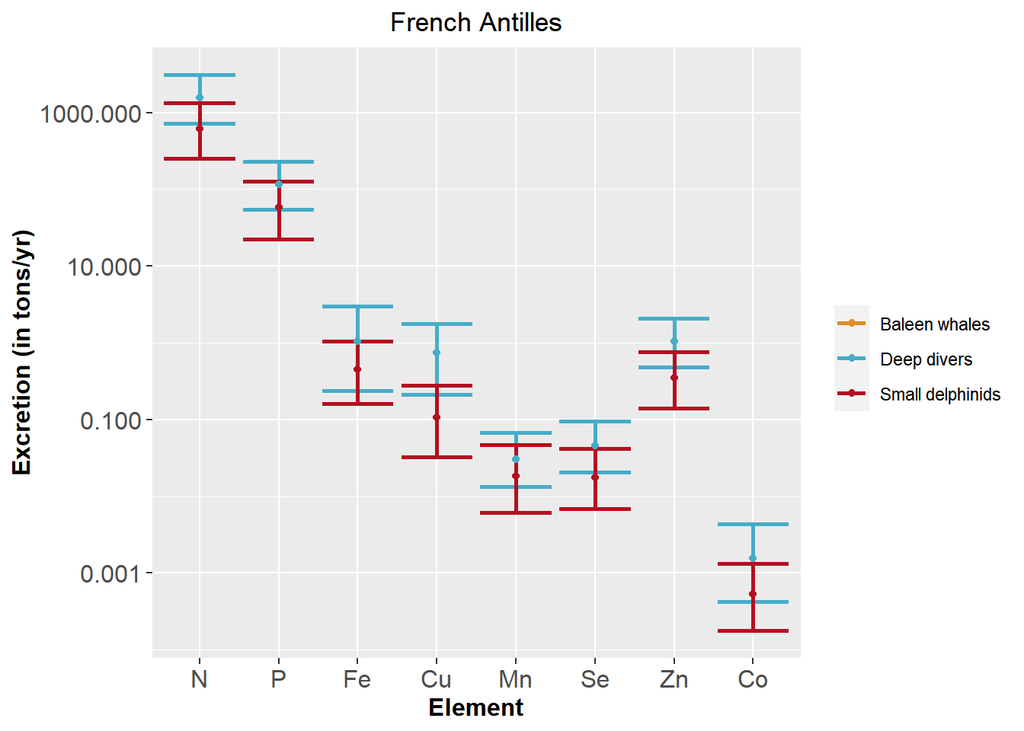

Are the differences significant ?

| Geo_area | Element | Group1 | Group2 | ratio_group1_superior_to_group2 |
| --- | --- | --- | --- | --- |
| French Antilles | N | Deep divers | Small delphinids | 0.959 |
| French Antilles | P | Deep divers | Small delphinids | 0.897 |
| French Antilles | Fe | Deep divers | Small delphinids | 0.845 |
| French Antilles | Cu | Deep divers | Small delphinids | 0.997 |
| French Antilles | Mn | Deep divers | Small delphinids | 0.805 |
| French Antilles | Se | Deep divers | Small delphinids | 0.955 |
| French Antilles | Zn | Deep divers | Small delphinids | 0.982 |
| French Antilles | Co | Deep divers | Small delphinids | 0.932 |

What are their relative contribution to total excretion in this area ?

| Geo_area | Eco_gp | Element | mean | mean_total | ratio_contribution |
| --- | --- | --- | --- | --- | --- |
| French Antilles | Deep divers | N | 1559.6149395 | 2151.8098427 | 0.7247922 |
| French Antilles | Deep divers | P | 117.2160050 | 171.8609907 | 0.6820396 |
| French Antilles | Deep divers | Fe | 1.0730043 | 1.5121694 | 0.7095794 |
| French Antilles | Deep divers | Cu | 0.7295502 | 0.8336604 | 0.8751168 |
| French Antilles | Deep divers | Mn | 0.0287602 | 0.0460335 | 0.6247667 |
| French Antilles | Deep divers | Se | 0.0443656 | 0.0616225 | 0.7199569 |
| French Antilles | Deep divers | Zn | 1.0320162 | 1.3768130 | 0.7495689 |
| French Antilles | Deep divers | Co | 0.0015640 | 0.0020620 | 0.7585243 |
| French Antilles | Deep divers | As | 0.3531023 | 0.4847805 | 0.7283756 |
| French Antilles | Small delphinids | N | 592.1949032 | 2151.8098427 | 0.2752078 |
| French Antilles | Small delphinids | P | 54.6449857 | 171.8609907 | 0.3179604 |
| French Antilles | Small delphinids | Fe | 0.4391651 | 1.5121694 | 0.2904206 |
| French Antilles | Small delphinids | Cu | 0.1041102 | 0.8336604 | 0.1248832 |
| French Antilles | Small delphinids | Mn | 0.0172733 | 0.0460335 | 0.3752333 |
| French Antilles | Small delphinids | Se | 0.0172570 | 0.0616225 | 0.2800431 |
| French Antilles | Small delphinids | Zn | 0.3447968 | 1.3768130 | 0.2504311 |
| French Antilles | Small delphinids | Co | 0.0004979 | 0.0020620 | 0.2414757 |
| French Antilles | Small delphinids | As | 0.1316782 | 0.4847805 | 0.2716244 |

## Excretion per taxa and per habitat

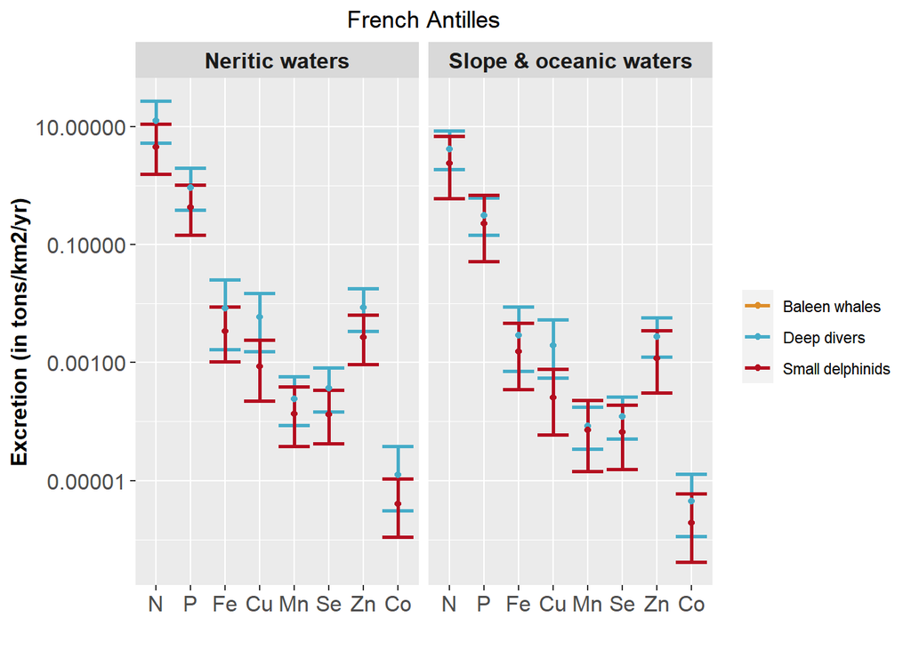

Are the differences significant ?

| Geo_area | Eco_area | Element | Group1 | Group2 | ratio_group1_superior_to_group2 |
| --- | --- | --- | --- | --- | --- |
| French Antilles | oceanic | N | Deep divers | Small delphinids | 0.810 |
| French Antilles | shelf | N | Deep divers | Small delphinids | 0.949 |
| French Antilles | oceanic | P | Deep divers | Small delphinids | 0.723 |
| French Antilles | shelf | P | Deep divers | Small delphinids | 0.896 |
| French Antilles | oceanic | Fe | Deep divers | Small delphinids | 0.744 |
| French Antilles | shelf | Fe | Deep divers | Small delphinids | 0.842 |
| French Antilles | oceanic | Cu | Deep divers | Small delphinids | 0.997 |
| French Antilles | shelf | Cu | Deep divers | Small delphinids | 0.996 |
| French Antilles | oceanic | Mn | Deep divers | Small delphinids | 0.630 |
| French Antilles | shelf | Mn | Deep divers | Small delphinids | 0.815 |
| French Antilles | oceanic | Se | Deep divers | Small delphinids | 0.829 |
| French Antilles | shelf | Se | Deep divers | Small delphinids | 0.950 |
| French Antilles | oceanic | Zn | Deep divers | Small delphinids | 0.894 |
| French Antilles | shelf | Zn | Deep divers | Small delphinids | 0.974 |
| French Antilles | oceanic | Co | Deep divers | Small delphinids | 0.834 |
| French Antilles | shelf | Co | Deep divers | Small delphinids | 0.937 |

What is the relative contribution to total excretion in each habitat ?

| Geo_area | Eco_area | Eco_gp | Element | mean | mean_total | ratio_contribution |
| --- | --- | --- | --- | --- | --- | --- |
| French Antilles | oceanic | Deep divers | N | 235.2952723 | 371.7035325 | 0.6330187 |
| French Antilles | oceanic | Deep divers | P | 17.5172610 | 30.5478183 | 0.5734374 |
| French Antilles | oceanic | Deep divers | Fe | 0.1630330 | 0.2505963 | 0.6505801 |
| French Antilles | oceanic | Deep divers | Cu | 0.1119304 | 0.1265745 | 0.8843048 |
| French Antilles | oceanic | Deep divers | Mn | 0.0047457 | 0.0088712 | 0.5349538 |
| French Antilles | oceanic | Deep divers | Se | 0.0068346 | 0.0105747 | 0.6463156 |
| French Antilles | oceanic | Deep divers | Zn | 0.1580922 | 0.2254264 | 0.7013028 |
| French Antilles | oceanic | Deep divers | Co | 0.0002538 | 0.0003624 | 0.7002782 |
| French Antilles | oceanic | Deep divers | As | 0.0527291 | 0.0909770 | 0.5795875 |
| French Antilles | oceanic | Small delphinids | N | 136.4082602 | 371.7035325 | 0.3669813 |
| French Antilles | oceanic | Small delphinids | P | 13.0305573 | 30.5478183 | 0.4265626 |
| French Antilles | oceanic | Small delphinids | Fe | 0.0875633 | 0.2505963 | 0.3494199 |
| French Antilles | oceanic | Small delphinids | Cu | 0.0146441 | 0.1265745 | 0.1156952 |
| French Antilles | oceanic | Small delphinids | Mn | 0.0041255 | 0.0088712 | 0.4650462 |
| French Antilles | oceanic | Small delphinids | Se | 0.0037401 | 0.0105747 | 0.3536844 |
| French Antilles | oceanic | Small delphinids | Zn | 0.0673342 | 0.2254264 | 0.2986972 |
| French Antilles | oceanic | Small delphinids | Co | 0.0001086 | 0.0003624 | 0.2997218 |
| French Antilles | oceanic | Small delphinids | As | 0.0382479 | 0.0909770 | 0.4204125 |
| French Antilles | shelf | Deep divers | N | 1343.3380060 | 1821.5807148 | 0.7374573 |
| French Antilles | shelf | Deep divers | P | 98.9864977 | 144.3060013 | 0.6859486 |
| French Antilles | shelf | Deep divers | Fe | 0.8902079 | 1.2546069 | 0.7095512 |
| French Antilles | shelf | Deep divers | Cu | 0.6299468 | 0.7221012 | 0.8723801 |
| French Antilles | shelf | Deep divers | Mn | 0.0257304 | 0.0401665 | 0.6405931 |
| French Antilles | shelf | Deep divers | Se | 0.0393932 | 0.0533377 | 0.7385617 |
| French Antilles | shelf | Deep divers | Zn | 0.9004668 | 1.1831517 | 0.7610747 |
| French Antilles | shelf | Deep divers | Co | 0.0013184 | 0.0017470 | 0.7546623 |
| French Antilles | shelf | Deep divers | As | 0.2973795 | 0.4067417 | 0.7311262 |
| French Antilles | shelf | Small delphinids | N | 478.2427088 | 1821.5807148 | 0.2625427 |
| French Antilles | shelf | Small delphinids | P | 45.3195037 | 144.3060013 | 0.3140514 |
| French Antilles | shelf | Small delphinids | Fe | 0.3643990 | 1.2546069 | 0.2904488 |
| French Antilles | shelf | Small delphinids | Cu | 0.0921545 | 0.7221012 | 0.1276199 |
| French Antilles | shelf | Small delphinids | Mn | 0.0144361 | 0.0401665 | 0.3594069 |
| French Antilles | shelf | Small delphinids | Se | 0.0139445 | 0.0533377 | 0.2614383 |
| French Antilles | shelf | Small delphinids | Zn | 0.2826849 | 1.1831517 | 0.2389253 |
| French Antilles | shelf | Small delphinids | Co | 0.0004286 | 0.0017470 | 0.2453377 |
| French Antilles | shelf | Small delphinids | As | 0.1093622 | 0.4067417 | 0.2688738 |

# French Guyana

## Excretion in neritic and oceanic waters

In absolute value, is there more excretion in an habitat than in the other ?

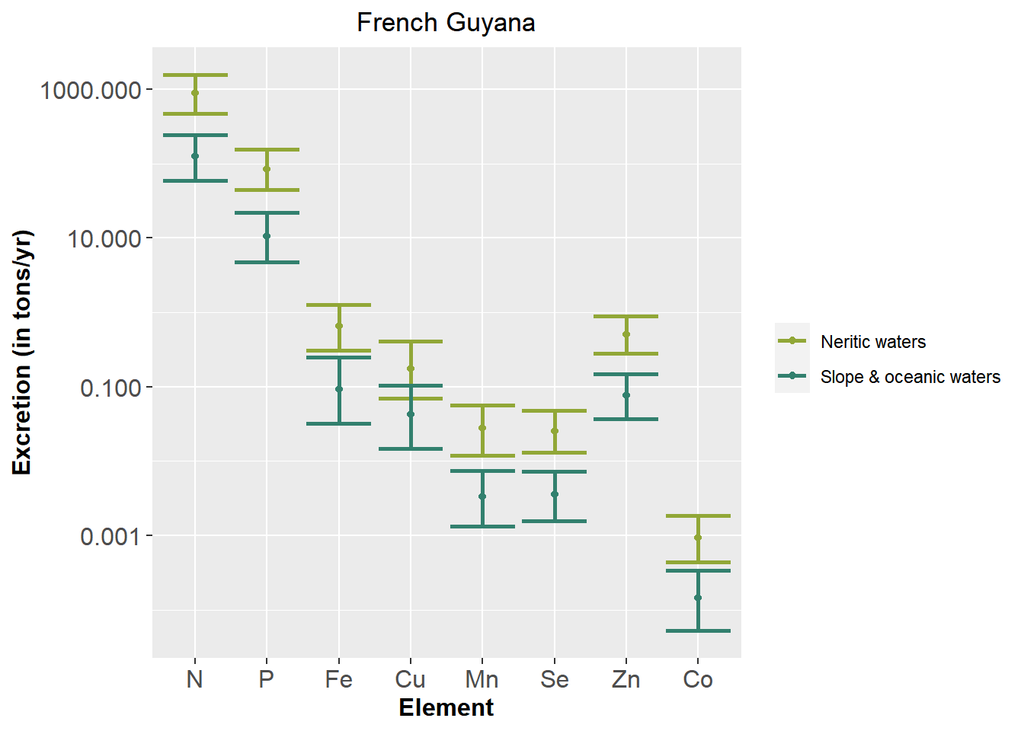

The full results being:

| Geo_area | Eco_area | Element | min | 2.5_quant | mean | median | 97.5_quant | max |
| --- | --- | --- | --- | --- | --- | --- | --- | --- |
| French Guyana | oceanic | N | 42.7625847 | 59.2195100 | 125.0295079 | 116.0859151 | 242.3670408 | 446.5966023 |
| French Guyana | oceanic | P | 3.6161563 | 4.7464683 | 10.6088734 | 9.7723563 | 22.0011898 | 37.2773174 |
| French Guyana | oceanic | Fe | 0.0215875 | 0.0319806 | 0.0932877 | 0.0785714 | 0.2476873 | 0.4655394 |
| French Guyana | oceanic | Cu | 0.0065045 | 0.0146718 | 0.0421859 | 0.0354759 | 0.1041073 | 0.2259662 |
| French Guyana | oceanic | Mn | 0.0008732 | 0.0013338 | 0.0033382 | 0.0030241 | 0.0074472 | 0.0156018 |
| French Guyana | oceanic | Se | 0.0011162 | 0.0015803 | 0.0035962 | 0.0033282 | 0.0073264 | 0.0118630 |
| French Guyana | oceanic | Zn | 0.0285083 | 0.0369947 | 0.0773984 | 0.0721695 | 0.1489572 | 0.2768356 |
| French Guyana | oceanic | Co | 0.0000353 | 0.0000529 | 0.0001459 | 0.0001280 | 0.0003409 | 0.0006802 |
| French Guyana | oceanic | As | 0.0061831 | 0.0123286 | 0.0322326 | 0.0279110 | 0.0775865 | 0.1629035 |
| French Guyana | shelf | N | 323.5209507 | 470.0907308 | 892.8136965 | 842.6725047 | 1554.0623500 | 2391.8860009 |
| French Guyana | shelf | P | 33.3376642 | 44.0680108 | 84.2641509 | 80.6464150 | 155.9256080 | 209.0319583 |
| French Guyana | shelf | Fe | 0.1900392 | 0.3064588 | 0.6627918 | 0.6155878 | 1.2762909 | 1.8643878 |
| French Guyana | shelf | Cu | 0.0513662 | 0.0705558 | 0.1730246 | 0.1510680 | 0.4083829 | 0.9097024 |
| French Guyana | shelf | Mn | 0.0077253 | 0.0120574 | 0.0276650 | 0.0250886 | 0.0558603 | 0.0901511 |
| French Guyana | shelf | Se | 0.0101243 | 0.0130561 | 0.0252267 | 0.0235115 | 0.0476499 | 0.0725626 |
| French Guyana | shelf | Zn | 0.1901983 | 0.2804182 | 0.5020463 | 0.4764875 | 0.8818698 | 1.6145309 |
| French Guyana | shelf | Co | 0.0002686 | 0.0004370 | 0.0009300 | 0.0008606 | 0.0018561 | 0.0029522 |
| French Guyana | shelf | As | 0.0520955 | 0.0876909 | 0.2439713 | 0.1992858 | 0.6450877 | 1.2873428 |

And per unit area, so considering the respective size of each of the habitat ?

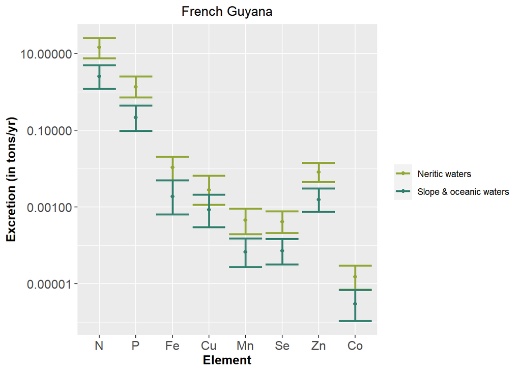

The details being:

| Geo_area | Eco_area | Element | min | 2.5_quant | mean | median | 97.5_quant | max |
| --- | --- | --- | --- | --- | --- | --- | --- | --- |
| French Guyana | oceanic | N | 0.8704143 | 1.2053881 | 2.5449227 | 2.3628797 | 4.9332785 | 9.0902848 |
| French Guyana | oceanic | P | 0.0736053 | 0.0966124 | 0.2159391 | 0.1989122 | 0.4478249 | 0.7587640 |
| French Guyana | oceanic | Fe | 0.0004394 | 0.0006510 | 0.0018988 | 0.0015993 | 0.0050416 | 0.0094759 |
| French Guyana | oceanic | Cu | 0.0001324 | 0.0002986 | 0.0008587 | 0.0007221 | 0.0021191 | 0.0045994 |
| French Guyana | oceanic | Mn | 0.0000178 | 0.0000271 | 0.0000679 | 0.0000616 | 0.0001516 | 0.0003176 |
| French Guyana | oceanic | Se | 0.0000227 | 0.0000322 | 0.0000732 | 0.0000677 | 0.0001491 | 0.0002415 |
| French Guyana | oceanic | Zn | 0.0005803 | 0.0007530 | 0.0015754 | 0.0014690 | 0.0030320 | 0.0056349 |
| French Guyana | oceanic | Co | 0.0000007 | 0.0000011 | 0.0000030 | 0.0000026 | 0.0000069 | 0.0000138 |
| French Guyana | oceanic | As | 0.0001259 | 0.0002509 | 0.0006561 | 0.0005681 | 0.0015792 | 0.0033158 |
| French Guyana | shelf | N | 5.2634987 | 7.6481043 | 14.5255625 | 13.7097943 | 25.2836956 | 38.9146018 |
| French Guyana | shelf | P | 0.5423845 | 0.7169610 | 1.3709290 | 1.3120705 | 2.5368195 | 3.4008291 |
| French Guyana | shelf | Fe | 0.0030918 | 0.0049859 | 0.0107832 | 0.0100153 | 0.0207645 | 0.0303325 |
| French Guyana | shelf | Cu | 0.0008357 | 0.0011479 | 0.0028150 | 0.0024578 | 0.0066442 | 0.0148003 |
| French Guyana | shelf | Mn | 0.0001257 | 0.0001962 | 0.0004501 | 0.0004082 | 0.0009088 | 0.0014667 |
| French Guyana | shelf | Se | 0.0001647 | 0.0002124 | 0.0004104 | 0.0003825 | 0.0007752 | 0.0011806 |
| French Guyana | shelf | Zn | 0.0030944 | 0.0045622 | 0.0081680 | 0.0077522 | 0.0143475 | 0.0262675 |
| French Guyana | shelf | Co | 0.0000044 | 0.0000071 | 0.0000151 | 0.0000140 | 0.0000302 | 0.0000480 |
| French Guyana | shelf | As | 0.0008476 | 0.0014267 | 0.0039693 | 0.0032423 | 0.0104952 | 0.0209443 |

Are the differences between the two areas significant ? (per surface unit)

| Geo_area | Element | Area1 | Area2 | ratio_area1_superior_to_area2 |
| --- | --- | --- | --- | --- |
| French Guyana | N | Neritic waters | Oceanic waters | 1.000 |
| French Guyana | N | Oceanic waters | Neritic waters | 0.000 |
| French Guyana | P | Neritic waters | Oceanic waters | 0.999 |
| French Guyana | P | Oceanic waters | Neritic waters | 0.001 |
| French Guyana | Fe | Neritic waters | Oceanic waters | 1.000 |
| French Guyana | Fe | Oceanic waters | Neritic waters | 0.000 |
| French Guyana | Cu | Neritic waters | Oceanic waters | 0.990 |
| French Guyana | Cu | Oceanic waters | Neritic waters | 0.010 |
| French Guyana | Mn | Neritic waters | Oceanic waters | 1.000 |
| French Guyana | Mn | Oceanic waters | Neritic waters | 0.000 |
| French Guyana | Se | Neritic waters | Oceanic waters | 1.000 |
| French Guyana | Se | Oceanic waters | Neritic waters | 0.000 |
| French Guyana | Zn | Neritic waters | Oceanic waters | 1.000 |
| French Guyana | Zn | Oceanic waters | Neritic waters | 0.000 |
| French Guyana | Co | Neritic waters | Oceanic waters | 1.000 |
| French Guyana | Co | Oceanic waters | Neritic waters | 0.000 |

## Excretion per taxa

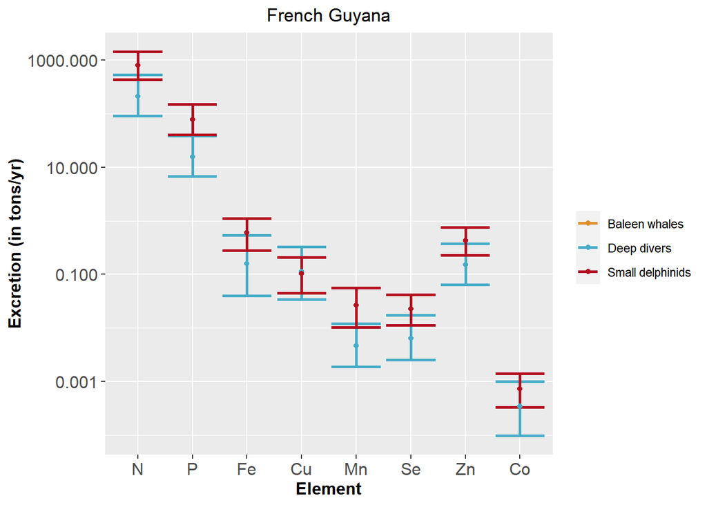

Are the differences significant ?

| Geo_area | Element | Group1 | Group2 | ratio_group1_superior_to_group2 |
| --- | --- | --- | --- | --- |
| French Guyana | N | Deep divers | Small delphinids | 0.009 |
| French Guyana | P | Deep divers | Small delphinids | 0.006 |
| French Guyana | Fe | Deep divers | Small delphinids | 0.022 |
| French Guyana | Cu | Deep divers | Small delphinids | 0.488 |
| French Guyana | Mn | Deep divers | Small delphinids | 0.007 |
| French Guyana | Se | Deep divers | Small delphinids | 0.018 |
| French Guyana | Zn | Deep divers | Small delphinids | 0.029 |
| French Guyana | Co | Deep divers | Small delphinids | 0.101 |

What are their relative contribution to total excretion in this area ?

| Geo_area | Eco_gp | Element | mean | mean_total | ratio_contribution |
| --- | --- | --- | --- | --- | --- |
| French Guyana | Deep divers | N | 210.3834541 | 1017.8432044 | 0.2066953 |
| French Guyana | Deep divers | P | 15.7068559 | 94.8730243 | 0.1655566 |
| French Guyana | Deep divers | Fe | 0.1569493 | 0.7560795 | 0.2075831 |
| French Guyana | Deep divers | Cu | 0.1126664 | 0.2152105 | 0.5235172 |
| French Guyana | Deep divers | Mn | 0.0046768 | 0.0310032 | 0.1508495 |
| French Guyana | Deep divers | Se | 0.0063643 | 0.0288228 | 0.2208092 |
| French Guyana | Deep divers | Zn | 0.1527933 | 0.5794447 | 0.2636892 |
| French Guyana | Deep divers | Co | 0.0003459 | 0.0010759 | 0.3215415 |
| French Guyana | Deep divers | As | 0.0544661 | 0.2762039 | 0.1971954 |
| French Guyana | Small delphinids | N | 807.4597503 | 1017.8432044 | 0.7933047 |
| French Guyana | Small delphinids | P | 79.1661684 | 94.8730243 | 0.8344434 |
| French Guyana | Small delphinids | Fe | 0.5991302 | 0.7560795 | 0.7924169 |
| French Guyana | Small delphinids | Cu | 0.1025441 | 0.2152105 | 0.4764828 |
| French Guyana | Small delphinids | Mn | 0.0263264 | 0.0310032 | 0.8491505 |
| French Guyana | Small delphinids | Se | 0.0224585 | 0.0288228 | 0.7791908 |
| French Guyana | Small delphinids | Zn | 0.4266514 | 0.5794447 | 0.7363108 |
| French Guyana | Small delphinids | Co | 0.0007300 | 0.0010759 | 0.6784585 |
| French Guyana | Small delphinids | As | 0.2217377 | 0.2762039 | 0.8028046 |

## Excretion per taxa and per habitat

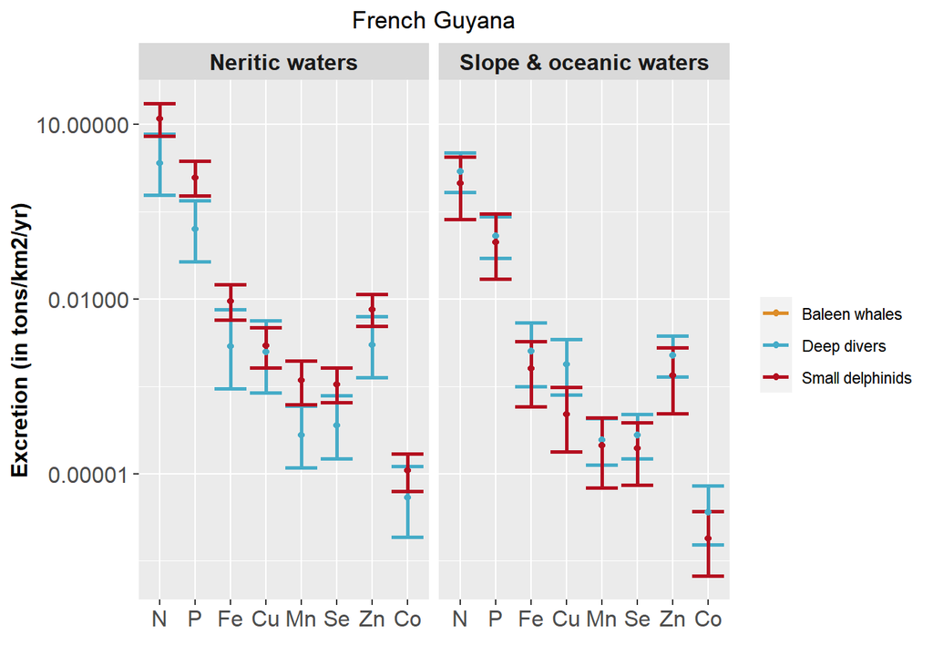

Are the differences significant ?

| Geo_area | Eco_area | Element | Group1 | Group2 | ratio_group1_superior_to_group2 |
| --- | --- | --- | --- | --- | --- |
| French Guyana | oceanic | N | Deep divers | Small delphinids | 0.782 |
| French Guyana | shelf | N | Deep divers | Small delphinids | 0.008 |
| French Guyana | oceanic | P | Deep divers | Small delphinids | 0.687 |
| French Guyana | shelf | P | Deep divers | Small delphinids | 0.005 |
| French Guyana | oceanic | Fe | Deep divers | Small delphinids | 0.767 |
| French Guyana | shelf | Fe | Deep divers | Small delphinids | 0.012 |
| French Guyana | oceanic | Cu | Deep divers | Small delphinids | 0.993 |
| French Guyana | shelf | Cu | Deep divers | Small delphinids | 0.257 |
| French Guyana | oceanic | Mn | Deep divers | Small delphinids | 0.649 |
| French Guyana | shelf | Mn | Deep divers | Small delphinids | 0.005 |
| French Guyana | oceanic | Se | Deep divers | Small delphinids | 0.793 |
| French Guyana | shelf | Se | Deep divers | Small delphinids | 0.011 |
| French Guyana | oceanic | Zn | Deep divers | Small delphinids | 0.895 |
| French Guyana | shelf | Zn | Deep divers | Small delphinids | 0.014 |
| French Guyana | oceanic | Co | Deep divers | Small delphinids | 0.881 |
| French Guyana | shelf | Co | Deep divers | Small delphinids | 0.051 |

What is the relative contribution to total excretion in each habitat ?

| Geo_area | Eco_area | Eco_gp | Element | mean | mean_total | ratio_contribution |
| --- | --- | --- | --- | --- | --- | --- |
| French Guyana | oceanic | Deep divers | N | 76.7783651 | 125.0295079 | 0.6140820 |
| French Guyana | oceanic | Deep divers | P | 6.0074518 | 10.6088734 | 0.5662667 |
| French Guyana | oceanic | Deep divers | Fe | 0.0618485 | 0.0932877 | 0.6629860 |
| French Guyana | oceanic | Deep divers | Cu | 0.0370105 | 0.0421859 | 0.8773207 |
| French Guyana | oceanic | Deep divers | Mn | 0.0018597 | 0.0033382 | 0.5571004 |
| French Guyana | oceanic | Deep divers | Se | 0.0022686 | 0.0035962 | 0.6308371 |
| French Guyana | oceanic | Deep divers | Zn | 0.0534322 | 0.0773984 | 0.6903524 |
| French Guyana | oceanic | Deep divers | Co | 0.0001076 | 0.0001459 | 0.7377429 |
| French Guyana | oceanic | Deep divers | As | 0.0187813 | 0.0322326 | 0.5826791 |
| French Guyana | oceanic | Small delphinids | N | 48.2511429 | 125.0295079 | 0.3859180 |
| French Guyana | oceanic | Small delphinids | P | 4.6014216 | 10.6088734 | 0.4337333 |
| French Guyana | oceanic | Small delphinids | Fe | 0.0314393 | 0.0932877 | 0.3370140 |
| French Guyana | oceanic | Small delphinids | Cu | 0.0051753 | 0.0421859 | 0.1226793 |
| French Guyana | oceanic | Small delphinids | Mn | 0.0014785 | 0.0033382 | 0.4428996 |
| French Guyana | oceanic | Small delphinids | Se | 0.0013276 | 0.0035962 | 0.3691629 |
| French Guyana | oceanic | Small delphinids | Zn | 0.0239662 | 0.0773984 | 0.3096476 |
| French Guyana | oceanic | Small delphinids | Co | 0.0000383 | 0.0001459 | 0.2622571 |
| French Guyana | oceanic | Small delphinids | As | 0.0134513 | 0.0322326 | 0.4173209 |
| French Guyana | shelf | Deep divers | N | 133.6050890 | 892.8136965 | 0.1496450 |
| French Guyana | shelf | Deep divers | P | 9.6994041 | 84.2641509 | 0.1151071 |
| French Guyana | shelf | Deep divers | Fe | 0.0951009 | 0.6627918 | 0.1434853 |
| French Guyana | shelf | Deep divers | Cu | 0.0756558 | 0.1730246 | 0.4372548 |
| French Guyana | shelf | Deep divers | Mn | 0.0028171 | 0.0276650 | 0.1018286 |
| French Guyana | shelf | Deep divers | Se | 0.0040957 | 0.0252267 | 0.1623580 |
| French Guyana | shelf | Deep divers | Zn | 0.0993611 | 0.5020463 | 0.1979122 |
| French Guyana | shelf | Deep divers | Co | 0.0002383 | 0.0009300 | 0.2562432 |
| French Guyana | shelf | Deep divers | As | 0.0356849 | 0.2439713 | 0.1462667 |
| French Guyana | shelf | Small delphinids | N | 759.2086074 | 892.8136965 | 0.8503550 |
| French Guyana | shelf | Small delphinids | P | 74.5647468 | 84.2641509 | 0.8848929 |
| French Guyana | shelf | Small delphinids | Fe | 0.5676909 | 0.6627918 | 0.8565147 |
| French Guyana | shelf | Small delphinids | Cu | 0.0973688 | 0.1730246 | 0.5627452 |
| French Guyana | shelf | Small delphinids | Mn | 0.0248479 | 0.0276650 | 0.8981714 |
| French Guyana | shelf | Small delphinids | Se | 0.0211309 | 0.0252267 | 0.8376420 |
| French Guyana | shelf | Small delphinids | Zn | 0.4026852 | 0.5020463 | 0.8020878 |
| French Guyana | shelf | Small delphinids | Co | 0.0006917 | 0.0009300 | 0.7437568 |
| French Guyana | shelf | Small delphinids | As | 0.2082864 | 0.2439713 | 0.8537333 |